# Ferropenia

### 4.3.4 ANN

```r
# Ajuste del modelo
set.seed(29)

(modelo_ann <- train(Clasificación ~ ., data = dataset.train_SMOTE_retis,
                    method = "nnet",
                    metric = "Kappa",
                    trControl= fitControl,
                    trace = FALSE))
```

```
## Neural Network
##
## 328 samples
##   8 predictor
##   3 classes: 'AF', 'FF/FL', 'NF'
##
## No pre-processing
## Resampling: Cross-Validated (10 fold)
## Summary of sample sizes: 296, 295, 295, 295, 295, 295, ...
## Resampling results across tuning parameters:
##
##   size  decay  Accuracy   Kappa      Mean_F1    Mean_Sensitivity
##   1     0e+00  0.6039773  0.3599896  0.5977760  0.6008384
##   1     1e-04  0.5921402  0.3547331  0.5786285  0.6056742
##   1     1e-01  0.6010417  0.3501992  0.5894455  0.5938434
##   3     0e+00  0.7262311  0.5589421  0.7200367  0.7256283
##   3     1e-04  0.7142045  0.5397066  0.7086695  0.7110878
##   3     1e-01  0.7561553  0.6039918  0.7471298  0.7431373
##   5     0e+00  0.7071023  0.5349112  0.7069038  0.7150599
##   5     1e-04  0.7749053  0.6416496  0.7743682  0.7773284
##   5     1e-01  0.7441288  0.5908160  0.7454447  0.7440535
##   Mean_Specificity  Mean_Pos_Pred_Value  Mean_Neg_Pred_Value  Mean_Precision
##   0.7767911         0.6192165            0.7883481            0.6192165
##   0.7747439         0.6000203            0.7891759            0.6000203
##   0.7722018         0.6184732            0.7820031            0.6184732
##   0.8467690         0.7610940            0.8563369            0.7610940
##   0.8401558         0.7299058            0.8468497            0.7299058
##   0.8615019         0.7709606            0.8695498            0.7709606
##   0.8400641         0.7198752            0.8432369            0.7198752
##   0.8752545         0.7840603            0.8805134            0.7840603
##   0.8579109         0.7663731            0.8641295            0.7663731
##   Mean_Recall  Mean_Detection_Rate  Mean_Balanced_Accuracy
##   0.6008384    0.2013258            0.6888148
##   0.6056742    0.1973801            0.6902091
##   0.5938434    0.2003472            0.6830226
##   0.7256283    0.2420770            0.7861987
##   0.7110878    0.2380682            0.7756218
##   0.7431373    0.2520518            0.8023196
##   0.7150599    0.2357008            0.7775620
##   0.7773284    0.2583018            0.8262915
##   0.7440535    0.2480429            0.8009822
##
## Kappa was used to select the optimal model using the largest value.
## The final values used for the model were size = 5 and decay = 1e-04.
```

```r
# Predicciones
p <- predict(modelo_ann, newdata = dataset.test_retis[1:(ncol(dataset.test_retis)-1)])

# Evaluación
(mconfusion_ann = confusionMatrix(p, dataset.test_retis$Clasificación, mode="everything", positive="AF"))
```

```
## Confusion Matrix and Statistics
##
##           Reference
## Prediction AF FF/FL NF
##      AF    12     0  5
##      FF/FL  0    10 10
##      NF     3     8 54
##
## Overall Statistics
##
##                Accuracy : 0.7451
##                  95% CI : (0.6492, 0.8262)
##     No Information Rate : 0.6765
##     P-Value [Acc > NIR] : 0.08245
##
##                   Kappa : 0.5
##
##  Mcnemar's Test P-Value : NA
##
## Statistics by Class:
##
##                      Class: AF Class: FF/FL Class: NF
## Sensitivity             0.8000      0.55556    0.7826
## Specificity             0.9425      0.88095    0.6667
## Pos Pred Value          0.7059      0.50000    0.8308
## Neg Pred Value          0.9647      0.90244    0.5946
## Precision               0.7059      0.50000    0.8308
## Recall                  0.8000      0.55556    0.7826
## F1                      0.7500      0.52632    0.8060
## Prevalence              0.1471      0.17647    0.6765
## Detection Rate          0.1176      0.09804    0.5294
## Detection Prevalence    0.1667      0.19608    0.6373
## Balanced Accuracy       0.8713      0.71825    0.7246
```

```r
resultados_ann <- data.frame(
  Modelo        = "ANN",
  Precisión     = round((ifelse(is.na(mconfusion_ann$byClass[1,5]), 0, mconfusion_ann$byClass[1,5]) +
                        ifelse(is.na(mconfusion_ann$byClass[2,5]), 0, mconfusion_ann$byClass[2,5]) +
                        ifelse(is.na(mconfusion_ann$byClass[3,5]), 0, mconfusion_ann$byClass[3,5])
                        ) / 3, 3),
  Sensibilidad  = round((ifelse(is.na(mconfusion_ann$byClass[1,1]), 0, mconfusion_ann$byClass[1,1]) +
                        ifelse(is.na(mconfusion_ann$byClass[2,1]), 0, mconfusion_ann$byClass[2,1]) +
                        ifelse(is.na(mconfusion_ann$byClass[3,1]), 0, mconfusion_ann$byClass[3,1])
                        ) / 3, 3),
  Especificidad = round((ifelse(is.na(mconfusion_ann$byClass[1,2]), 0, mconfusion_ann$byClass[1,2]) +
                        ifelse(is.na(mconfusion_ann$byClass[2,2]), 0, mconfusion_ann$byClass[2,2]) +
                        ifelse(is.na(mconfusion_ann$byClass[3,2]), 0, mconfusion_ann$byClass[3,2])
                        ) / 3, 3),
  kappa         = round(mconfusion_ann[["overall"]][["Kappa"]], 3),
  F1            = round((ifelse(is.na(mconfusion_ann$byClass[1,7]), 0, mconfusion_ann$byClass[1,7]) +
                        ifelse(is.na(mconfusion_ann$byClass[2,7]), 0, mconfusion_ann$byClass[2,7]) +
                        ifelse(is.na(mconfusion_ann$byClass[3,7]), 0, mconfusion_ann$byClass[3,7])
                       ) / 3, 3),
  Error_clasificación = round((1 - mconfusion_ann[["overall"]][["Accuracy"]]) * 100, 3),
  Accuracy      = round(mconfusion_ann[["overall"]][["Accuracy"]], 3)
)

resultados_ann
```

```
##   Modelo Precisión Sensibilidad Especificidad kappa    F1 Error_clasificación
## 1    ANN     0.679        0.713          0.83   0.5 0.694               25.49
##   Accuracy
## 1    0.745
```

### 4.3.5 Support Vector Machine

#### 4.3.5.1 SVM-lineal

```r
# Ajuste del modelo
set.seed(29)
(modelo_svmlineal = train(Clasificación ~ ., data = dataset.train_SMOTE_retis,
                          method = "svmLinear",
                          metric = "Kappa",
                    trControl= fitControl
                          ))
```

```
## Support Vector Machines with Linear Kernel
##
## 328 samples
##   8 predictor
##   3 classes: 'AF', 'FF/FL', 'NF'
##
## No pre-processing
## Resampling: Cross-Validated (10 fold)
## Summary of sample sizes: 296, 295, 295, 295, 295, 295, ...
## Resampling results:
##
##   Accuracy   Kappa     Mean_F1    Mean_Sensitivity  Mean_Specificity
##   0.7410985  0.567369  0.7257726  0.7132625         0.844995
##   Mean_Pos_Pred_Value  Mean_Neg_Pred_Value  Mean_Precision  Mean_Recall
##   0.7729247            0.8619712            0.7729247       0.7132625
##   Mean_Detection_Rate  Mean_Balanced_Accuracy
##   0.2470328            0.7791288
##
## Tuning parameter 'C' was held constant at a value of 1
```

```r
# Predicciones
p = predict(modelo_svmlineal, newdata = dataset.test_retis[1:(ncol(dataset.test_retis)-1)])

# Evaluación
(mconfusion_svmlineal = confusionMatrix(p, dataset.test_retis$Clasificación, mode="everything", positive="AF"))
```

```
## Confusion Matrix and Statistics
##
##           Reference
## Prediction AF FF/FL NF
##      AF    13     0  5
##      FF/FL  0     9  7
##      NF     2     9 57
##
## Overall Statistics
##
##                Accuracy : 0.7745
##                  95% CI : (0.6811, 0.8514)
##     No Information Rate : 0.6765
##     P-Value [Acc > NIR] : 0.01981
##
##                   Kappa : 0.5448
##
##  Mcnemar's Test P-Value : NA
##
## Statistics by Class:
##
##                      Class: AF Class: FF/FL Class: NF
## Sensitivity             0.8667      0.50000    0.8261
## Specificity             0.9425      0.91667    0.6667
## Pos Pred Value          0.7222      0.56250    0.8382
## Neg Pred Value          0.9762      0.89535    0.6471
## Precision               0.7222      0.56250    0.8382
## Recall                  0.8667      0.50000    0.8261
## F1                      0.7879      0.52941    0.8321
## Prevalence              0.1471      0.17647    0.6765
## Detection Rate          0.1275      0.08824    0.5588
## Detection Prevalence    0.1765      0.15686    0.6667
## Balanced Accuracy       0.9046      0.70833    0.7464
```

```r
resultados_svmlineal <- data.frame(
  Modelo              = "SVM lineal",
  Precisión           = round((ifelse(is.na(mconfusion_svmlineal$byClass[1,5]), 0, mconfusion_svmlineal$byClass[1,5]) +
                              ifelse(is.na(mconfusion_svmlineal$byClass[2,5]), 0, mconfusion_svmlineal$byClass[2,5]) +
                              ifelse(is.na(mconfusion_svmlineal$byClass[3,5]), 0, mconfusion_svmlineal$byClass[3,5])) / 3, 3),

  Sensibilidad        = round((ifelse(is.na(mconfusion_svmlineal$byClass[1,1]), 0, mconfusion_svmlineal$byClass[1,1]) +
                              ifelse(is.na(mconfusion_svmlineal$byClass[2,1]), 0, mconfusion_svmlineal$byClass[2,1]) +
                              ifelse(is.na(mconfusion_svmlineal$byClass[3,1]), 0, mconfusion_svmlineal$byClass[3,1])) / 3, 3),

  Especificidad       = round((ifelse(is.na(mconfusion_svmlineal$byClass[1,2]), 0, mconfusion_svmlineal$byClass[1,2]) +
                              ifelse(is.na(mconfusion_svmlineal$byClass[2,2]), 0, mconfusion_svmlineal$byClass[2,2]) +
                              ifelse(is.na(mconfusion_svmlineal$byClass[3,2]), 0, mconfusion_svmlineal$byClass[3,2])) / 3, 3),
  kappa               = round(mconfusion_svmlineal[["overall"]][["Kappa"]], 3),

  F1                  = round((ifelse(is.na(mconfusion_svmlineal$byClass[1,7]), 0, mconfusion_svmlineal$byClass[1,7]) +
                              ifelse(is.na(mconfusion_svmlineal$byClass[2,7]), 0, mconfusion_svmlineal$byClass[2,7]) +
                              ifelse(is.na(mconfusion_svmlineal$byClass[3,7]), 0, mconfusion_svmlineal$byClass[3,7])) / 3, 3),
  Error_clasificación = round((1 - mconfusion_svmlineal[["overall"]][["Accuracy"]]) * 100, 3),
  Accuracy            = round(mconfusion_svmlineal[["overall"]][["Accuracy"]], 3)
)

resultados_svmlineal
```

```
##       Modelo Precisión Sensibilidad Especificidad kappa    F1
## 1 SVM lineal     0.708        0.731         0.842 0.545 0.716
##   Error_clasificación Accuracy
## 1              22.549    0.775
```

#### 4.2.5.2 SVM-RBF o función gaussiana

```r
# Ajuste del modelo
set.seed(29)
(modelo_svmradial = train(Clasificación ~ ., data = dataset.train_SMOTE_retis,
                          method = "svmRadial",
                        metric = "Kappa",
                    trControl= fitControl))
```

```
## Support Vector Machines with Radial Basis Function Kernel
##
## 328 samples
##   8 predictor
##   3 classes: 'AF', 'FF/FL', 'NF'
##
## No pre-processing
## Resampling: Cross-Validated (10 fold)
## Summary of sample sizes: 296, 295, 295, 295, 295, 295, ...
## Resampling results across tuning parameters:
##
##   C     Accuracy   Kappa      Mean_F1    Mean_Sensitivity  Mean_Specificity
##   0.25  0.7409091  0.5565935  0.7171936  0.6933746         0.8399033
##   0.50  0.7559659  0.5887491  0.7381530  0.7212185         0.8518992
##   1.00  0.7621212  0.6010715  0.7459780  0.7319230         0.8560658
##   Mean_Pos_Pred_Value  Mean_Neg_Pred_Value  Mean_Precision  Mean_Recall
##   0.7990261            0.8695730            0.7990261       0.6933746
##   0.7960545            0.8756841            0.7960545       0.7212185
##   0.8032519            0.8812611            0.8032519       0.7319230
##   Mean_Detection_Rate  Mean_Balanced_Accuracy
##   0.2469697            0.7666389
##   0.2519886            0.7865588
##   0.2540404            0.7939944
##
## Tuning parameter 'sigma' was held constant at a value of 0.1701203
## Kappa was used to select the optimal model using the largest value.
## The final values used for the model were sigma = 0.1701203 and C = 1.
```

```r
# Predicciones
p = predict(modelo_svmradial, newdata = dataset.test_retis[1:(ncol(dataset.test_retis)-1)])

# Evaluación
(mconfusion_svmradial = confusionMatrix(p, dataset.test_retis$Clasificación, mode="everything", positive="AF"))
```

```
## Confusion Matrix and Statistics
##
##           Reference
## Prediction AF FF/FL NF
##      AF    13     1  0
##      FF/FL  0     8  8
##      NF     2     9 61
##
## Overall Statistics
##
##                Accuracy : 0.8039
##                  95% CI : (0.7135, 0.8759)
##     No Information Rate : 0.6765
##     P-Value [Acc > NIR] : 0.003027
##
##                   Kappa : 0.5869
##
##  Mcnemar's Test P-Value : 0.382644
##
## Statistics by Class:
##
##                      Class: AF Class: FF/FL Class: NF
## Sensitivity             0.8667      0.44444    0.8841
## Specificity             0.9885      0.90476    0.6667
## Pos Pred Value          0.9286      0.50000    0.8472
## Neg Pred Value          0.9773      0.88372    0.7333
## Precision               0.9286      0.50000    0.8472
## Recall                  0.8667      0.44444    0.8841
## F1                      0.8966      0.47059    0.8652
## Prevalence              0.1471      0.17647    0.6765
## Detection Rate          0.1275      0.07843    0.5980
## Detection Prevalence    0.1373      0.15686    0.7059
## Balanced Accuracy       0.9276      0.67460    0.7754
```

```r
resultados_SVM_radial <- data.frame(
  Modelo              = "SVM-Radial",
  Precisión           = round((ifelse(is.na(mconfusion_svmradial$byClass[1,5]), 0, mconfusion_svmradial$byClass[1,5]) +
                              ifelse(is.na(mconfusion_svmradial$byClass[2,5]), 0, mconfusion_svmradial$byClass[2,5]) +
                              ifelse(is.na(mconfusion_svmradial$byClass[3,5]), 0, mconfusion_svmradial$byClass[3,5])) / 3, 3),

  Sensibilidad        = round((ifelse(is.na(mconfusion_svmradial$byClass[1,1]), 0, mconfusion_svmradial$byClass[1,1]) +
                              ifelse(is.na(mconfusion_svmradial$byClass[2,1]), 0, mconfusion_svmradial$byClass[2,1]) +
                              ifelse(is.na(mconfusion_svmradial$byClass[3,1]), 0, mconfusion_svmradial$byClass[3,1]) ) / 3, 3),

  Especificidad       = round((ifelse(is.na(mconfusion_svmradial$byClass[1,2]), 0, mconfusion_svmradial$byClass[1,2]) +
                              ifelse(is.na(mconfusion_svmradial$byClass[2,2]), 0, mconfusion_svmradial$byClass[2,2]) +
                              ifelse(is.na(mconfusion_svmradial$byClass[3,2]), 0, mconfusion_svmradial$byClass[3,2]) ) / 3, 3),
  kappa               = round(mconfusion_svmradial[["overall"]][["Kappa"]], 3),
  F1                  = round((ifelse(is.na(mconfusion_svmradial$byClass[1,7]), 0, mconfusion_svmradial$byClass[1,7]) +
                              ifelse(is.na(mconfusion_svmradial$byClass[2,7]), 0, mconfusion_svmradial$byClass[2,7]) +
                              ifelse(is.na(mconfusion_svmradial$byClass[3,7]), 0, mconfusion_svmradial$byClass[3,7]) ) / 3, 3),
  Error_clasificación = round((1 - mconfusion_svmradial[["overall"]][["Accuracy"]]) * 100, 3),
  Accuracy            = round(mconfusion_svmradial[["overall"]][["Accuracy"]], 3)
)

resultados_SVM_radial
```

```
##       Modelo Precisión Sensibilidad Especificidad kappa    F1
## 1 SVM-Radial     0.759        0.732         0.853 0.587 0.744
##   Error_clasificación Accuracy
## 1              19.608    0.804
```

#### 4.3.5.3 SVM-polynomial

```r
# Ajuste del modelo
set.seed(29)
(modelo_svmpoly = train(Clasificación ~ ., data = dataset.train_SMOTE_retis,
                          method = "svmPoly",
                          metric = "Kappa",
                    trControl= fitControl))
```

```
## Support Vector Machines with Polynomial Kernel
##
## 328 samples
##   8 predictor
##   3 classes: 'AF', 'FF/FL', 'NF'
##
## No pre-processing
## Resampling: Cross-Validated (10 fold)
## Summary of sample sizes: 296, 295, 295, 295, 295, 295, ...
## Resampling results across tuning parameters:
##
##   degree  scale  C     Accuracy   Kappa       Mean_F1    Mean_Sensitivity
##   1       0.001  0.25  0.5000000  0.00000000        NaN  0.3333333
##   1       0.001  0.50  0.5000000  0.00000000        NaN  0.3333333
##   1       0.001  1.00  0.5000000  0.00000000        NaN  0.3333333
##   1       0.010  0.25  0.5000000  0.00000000        NaN  0.3333333
##   1       0.010  0.50  0.5578598  0.15718784  0.4010101  0.4323977
##   1       0.010  1.00  0.6919508  0.47035004  0.6460858  0.6253424
##   1       0.100  0.25  0.7378788  0.55735853  0.7162273  0.6945223
##   1       0.100  0.50  0.7379735  0.56164854  0.7196632  0.7051043
##   1       0.100  1.00  0.7410985  0.56664958  0.7216793  0.7088410
##   2       0.001  0.25  0.5000000  0.00000000        NaN  0.3333333
##   2       0.001  0.50  0.5000000  0.00000000        NaN  0.3333333
##   2       0.001  1.00  0.5000000  0.00000000        NaN  0.3333333
##   2       0.010  0.25  0.5639205  0.16815229  0.4432660  0.4380622
##   2       0.010  0.50  0.6919508  0.47035004  0.6460858  0.6253424
##   2       0.010  1.00  0.7317235  0.54553217  0.7083281  0.6849984
##   2       0.100  0.25  0.7532197  0.58448219  0.7342802  0.7161162
##   2       0.100  0.50  0.7503788  0.58405418  0.7341490  0.7210006
##   2       0.100  1.00  0.7502841  0.58490343  0.7357107  0.7254455
##   3       0.001  0.25  0.5000000  0.00000000        NaN  0.3333333
##   3       0.001  0.50  0.5000000  0.00000000        NaN  0.3333333
##   3       0.001  1.00  0.5212121  0.05230868        NaN  0.3642857
##   3       0.010  0.25  0.6949811  0.46561446  0.6484884  0.6196506
##   3       0.010  0.50  0.7104167  0.50556673  0.6766971  0.6533185
##   3       0.010  1.00  0.7531250  0.58479542  0.7371474  0.7171413
##   3       0.100  0.25  0.7533144  0.58755517  0.7363467  0.7223992
##   3       0.100  0.50  0.7471591  0.57783826  0.7280708  0.7171977
##   3       0.100  1.00  0.7472538  0.58116282  0.7325826  0.7238348
##   Mean_Specificity  Mean_Pos_Pred_Value  Mean_Neg_Pred_Value  Mean_Precision
```

[output cut: 43 more lines]

```
##   0.7161162    0.2510732            0.7831354
##   0.7210006    0.2501263            0.7858810
##   0.7254455    0.2500947            0.7880422
##   0.3333333    0.1666667            0.5000000
##   0.3333333    0.1666667            0.5000000
##   0.3642857    0.1737374            0.5225228
##   0.6196506    0.2316604            0.7136033
##   0.6533185    0.2368056            0.7388347
##   0.7171413    0.2510417            0.7835589
##   0.7223992    0.2511048            0.7868998
##   0.7171977    0.2490530            0.7825572
##   0.7238348    0.2490846            0.7870378
##
## Kappa was used to select the optimal model using the largest value.
## The final values used for the model were degree = 3, scale = 0.1 and C = 0.25.
```

```r
# Predicciones
p = predict(modelo_svmpoly, newdata = dataset.test_retis[1:(ncol(dataset.test_retis)-1)])

# Evaluación
(mconfusion_svmpoly = confusionMatrix(p, dataset.test_retis$Clasificación, mode="everything", positive="AF"))
```

```
## Confusion Matrix and Statistics
##
##           Reference
## Prediction AF FF/FL NF
##      AF    14     1  4
##      FF/FL  0     6  4
##      NF     1    11 61
##
## Overall Statistics
##
##                Accuracy : 0.7941
##                  95% CI : (0.7027, 0.8678)
##     No Information Rate : 0.6765
##     P-Value [Acc > NIR] : 0.005976
##
##                   Kappa : 0.563
##
##  Mcnemar's Test P-Value : 0.108411
##
## Statistics by Class:
##
##                      Class: AF Class: FF/FL Class: NF
## Sensitivity             0.9333      0.33333    0.8841
## Specificity             0.9425      0.95238    0.6364
## Pos Pred Value          0.7368      0.60000    0.8356
## Neg Pred Value          0.9880      0.86957    0.7241
## Precision               0.7368      0.60000    0.8356
## Recall                  0.9333      0.33333    0.8841
## F1                      0.8235      0.42857    0.8592
## Prevalence              0.1471      0.17647    0.6765
## Detection Rate          0.1373      0.05882    0.5980
## Detection Prevalence    0.1863      0.09804    0.7157
## Balanced Accuracy       0.9379      0.64286    0.7602
```

```r
resultados_SVM_poly <- data.frame(
  Modelo              = "SVM-poly",
  Precisión           = round((ifelse(is.na(mconfusion_svmpoly$byClass[1,5]), 0, mconfusion_svmpoly$byClass[1,5]) +
                              ifelse(is.na(mconfusion_svmpoly$byClass[2,5]), 0, mconfusion_svmpoly$byClass[2,5]) +
                              ifelse(is.na(mconfusion_svmpoly$byClass[3,5]), 0, mconfusion_svmpoly$byClass[3,5]) ) / 3, 3),

  Sensibilidad        = round((ifelse(is.na(mconfusion_svmpoly$byClass[1,1]), 0, mconfusion_svmpoly$byClass[1,1]) +
                              ifelse(is.na(mconfusion_svmpoly$byClass[2,1]), 0, mconfusion_svmpoly$byClass[2,1]) +
                              ifelse(is.na(mconfusion_svmpoly$byClass[3,1]), 0, mconfusion_svmpoly$byClass[3,1]) ) / 3, 3),

  Especificidad       = round((ifelse(is.na(mconfusion_svmpoly$byClass[1,2]), 0, mconfusion_svmpoly$byClass[1,2]) +
                              ifelse(is.na(mconfusion_svmpoly$byClass[2,2]), 0, mconfusion_svmpoly$byClass[2,2]) +
                              ifelse(is.na(mconfusion_svmpoly$byClass[3,2]), 0, mconfusion_svmpoly$byClass[3,2]) ) /3, 3),
  kappa               = round(mconfusion_svmpoly[["overall"]][["Kappa"]], 3),
  F1                  = round((ifelse(is.na(mconfusion_svmpoly$byClass[1,7]), 0, mconfusion_svmpoly$byClass[1,7]) +
                              ifelse(is.na(mconfusion_svmpoly$byClass[2,7]), 0, mconfusion_svmpoly$byClass[2,7]) +
                              ifelse(is.na(mconfusion_svmpoly$byClass[3,7]), 0, mconfusion_svmpoly$byClass[3,7]) ) / 3, 3),
  Error_clasificación = round((1 - mconfusion_svmpoly[["overall"]][["Accuracy"]]) * 100, 3),
  Accuracy            = round(mconfusion_svmpoly[["overall"]][["Accuracy"]], 3)
)

resultados_SVM_poly
```

```
##     Modelo Precisión Sensibilidad Especificidad kappa    F1 Error_clasificación
## 1 SVM-poly     0.724        0.717         0.844 0.563 0.704              20.588
##   Accuracy
## 1    0.794
```

### 4.3.6 Árbol de decisión

```r
# Ajuste del modelo
set.seed(29)
(modelo_C5.0 <- train(Clasificación ~ ., data = dataset.train_SMOTE_retis,
                     method = "C5.0",
                     metric = "Kappa",
                    trControl= fitControl
                     ))
```

```
## C5.0
##
## 328 samples
##   8 predictor
##   3 classes: 'AF', 'FF/FL', 'NF'
##
## No pre-processing
## Resampling: Cross-Validated (10 fold)
## Summary of sample sizes: 296, 295, 295, 295, 295, 295, ...
## Resampling results across tuning parameters:
##
##   model  winnow  trials  Accuracy   Kappa      Mean_F1    Mean_Sensitivity
##   rules  FALSE    1      0.7535038  0.6056121  0.7448646  0.7451914
##   rules  FALSE   10      0.7869318  0.6622164  0.7864202  0.7857474
##   rules  FALSE   20      0.7928030  0.6692179  0.7906762  0.7856871
##   rules   TRUE    1      0.7411932  0.5828465  0.7282274  0.7283789
##   rules   TRUE   10      0.7351326  0.5730122  0.7301825  0.7256186
##   rules   TRUE   20      0.7529356  0.6007003  0.7502899  0.7457769
##   tree   FALSE    1      0.7413826  0.5843082  0.7321334  0.7315009
##   tree   FALSE   10      0.8079545  0.6894850  0.8042440  0.7936430
##   tree   FALSE   20      0.7868371  0.6571649  0.7856377  0.7766826
##   tree    TRUE    1      0.7349432  0.5751514  0.7253110  0.7290733
##   tree    TRUE   10      0.7744318  0.6362068  0.7700467  0.7668417
##   tree    TRUE   20      0.7410038  0.5808533  0.7375237  0.7301257
##   Mean_Specificity  Mean_Pos_Pred_Value  Mean_Neg_Pred_Value  Mean_Precision
##   0.8652629         0.7611547            0.8717732            0.7611547
##   0.8852769         0.8023695            0.8870024            0.8023695
##   0.8857975         0.8092936            0.8905102            0.8092936
##   0.8568643         0.7548520            0.8667701            0.7548520
##   0.8525733         0.7501628            0.8578210            0.7501628
##   0.8611175         0.7726451            0.8670003            0.7726451
##   0.8580287         0.7488921            0.8639376            0.7488921
##   0.8917070         0.8294930            0.8981318            0.8294930
##   0.8803138         0.8055136            0.8867141            0.8055136
##   0.8550631         0.7451462            0.8630519            0.7451462
##   0.8745063         0.7842325            0.8785325            0.7842325
##   0.8543136         0.7588473            0.8599909            0.7588473
##   Mean_Recall  Mean_Detection_Rate  Mean_Balanced_Accuracy
##   0.7451914    0.2511679            0.8052272
##   0.7857474    0.2623106            0.8355121
##   0.7856871    0.2642677            0.8357423
##   0.7283789    0.2470644            0.7926216
##   0.7256186    0.2450442            0.7890959
##   0.7457769    0.2509785            0.8034472
##   0.7315009    0.2471275            0.7947648
##   0.7936430    0.2693182            0.8426750
##   0.7766826    0.2622790            0.8284982
##   0.7290733    0.2449811            0.7920682
##   0.7668417    0.2581439            0.8206740
##   0.7301257    0.2470013            0.7922197
##
## Kappa was used to select the optimal model using the largest value.
## The final values used for the model were trials = 10, model = tree and winnow
##  = FALSE.
```

```r
# Predicciones
p <- predict(modelo_C5.0, dataset.test_retis[1:(ncol(dataset.test_retis)-1)])

# Evaluación
(mconfusion_arbol = confusionMatrix(data = p, reference = dataset.test_retis$Clasificación, mode="everything", positive="AF"))
```

```
## Confusion Matrix and Statistics
##
##           Reference
## Prediction AF FF/FL NF
##      AF    12     0  4
##      FF/FL  0     6 13
##      NF     3    12 52
##
## Overall Statistics
##
##                Accuracy : 0.6863
##                  95% CI : (0.5869, 0.7745)
##     No Information Rate : 0.6765
##     P-Value [Acc > NIR] : 0.4628
##
##                   Kappa : 0.3722
##
##  Mcnemar's Test P-Value : NA
##
## Statistics by Class:
##
##                      Class: AF Class: FF/FL Class: NF
## Sensitivity             0.8000      0.33333    0.7536
## Specificity             0.9540      0.84524    0.5455
## Pos Pred Value          0.7500      0.31579    0.7761
## Neg Pred Value          0.9651      0.85542    0.5143
## Precision               0.7500      0.31579    0.7761
## Recall                  0.8000      0.33333    0.7536
## F1                      0.7742      0.32432    0.7647
## Prevalence              0.1471      0.17647    0.6765
## Detection Rate          0.1176      0.05882    0.5098
## Detection Prevalence    0.1569      0.18627    0.6569
## Balanced Accuracy       0.8770      0.58929    0.6495
```

```r
resultados_arbol <- data.frame(
  Modelo              = "Árbol",
  Precisión           = round((ifelse(is.na(mconfusion_arbol$byClass[1,5]), 0, mconfusion_arbol$byClass[1,5]) +
                              ifelse(is.na(mconfusion_arbol$byClass[2,5]), 0, mconfusion_arbol$byClass[2,5]) +
                              ifelse(is.na(mconfusion_arbol$byClass[3,5]), 0, mconfusion_arbol$byClass[3,5]) ) / 3, 3),
  Sensibilidad        = round((ifelse(is.na(mconfusion_arbol$byClass[1,1]), 0, mconfusion_arbol$byClass[1,1]) +
                              ifelse(is.na(mconfusion_arbol$byClass[2,1]), 0, mconfusion_arbol$byClass[2,1]) +
                              ifelse(is.na(mconfusion_arbol$byClass[3,1]), 0, mconfusion_arbol$byClass[3,1]) ) / 3, 3),

  Especificidad       = round((ifelse(is.na(mconfusion_arbol$byClass[1,2]), 0, mconfusion_arbol$byClass[1,2]) +
                              ifelse(is.na(mconfusion_arbol$byClass[2,2]), 0, mconfusion_arbol$byClass[2,2]) +
                              ifelse(is.na(mconfusion_arbol$byClass[3,2]), 0, mconfusion_arbol$byClass[3,2])) / 3, 3),

  kappa               = round(mconfusion_arbol[["overall"]][["Kappa"]], 3),
  F1                  = round((ifelse(is.na(mconfusion_arbol$byClass[1,7]), 0, mconfusion_arbol$byClass[1,7]) +
                              ifelse(is.na(mconfusion_arbol$byClass[2,7]), 0, mconfusion_arbol$byClass[2,7]) +
                              ifelse(is.na(mconfusion_arbol$byClass[3,7]), 0, mconfusion_arbol$byClass[3,7]) ) / 3, 3),
  Error_clasificación = round((1 - mconfusion_arbol[["overall"]][["Accuracy"]]) * 100, 3),
  Accuracy            = round(mconfusion_arbol[["overall"]][["Accuracy"]], 3)
)

resultados_arbol
```

```
##   Modelo Precisión Sensibilidad Especificidad kappa    F1 Error_clasificación
## 1  Árbol     0.614        0.629         0.782 0.372 0.621              31.373
##   Accuracy
## 1    0.686
```

### 4.3.7 Random Forest

```r
# Ajuste del modelo
set.seed(29)
(modelo_forest <- train(Clasificación ~ ., data = dataset.train_SMOTE_retis,
                   method = "ranger",
                   metric = "Kappa",
                    trControl= fitControl
                   ))
```

```
## Random Forest
##
## 328 samples
##   8 predictor
##   3 classes: 'AF', 'FF/FL', 'NF'
##
## No pre-processing
## Resampling: Cross-Validated (10 fold)
## Summary of sample sizes: 296, 295, 295, 295, 295, 295, ...
## Resampling results across tuning parameters:
##
##   mtry  splitrule   Accuracy   Kappa      Mean_F1    Mean_Sensitivity
##   2     gini        0.8264205  0.7185645  0.8280663  0.8159178
##   2     extratrees  0.8445076  0.7455989  0.8411663  0.8245682
##   5     gini        0.8052083  0.6872581  0.8080098  0.8003988
##   5     extratrees  0.8510417  0.7592802  0.8489947  0.8423397
##   8     gini        0.8021780  0.6846423  0.8051840  0.7999358
##   8     extratrees  0.8358902  0.7358571  0.8360113  0.8318238
##   Mean_Specificity  Mean_Pos_Pred_Value  Mean_Neg_Pred_Value  Mean_Precision
##   0.8993200         0.8543488            0.9089140            0.8543488
##   0.9075935         0.8747091            0.9217969            0.8747091
##   0.8902204         0.8307718            0.8972120            0.8307718
##   0.9150343         0.8663153            0.9215856            0.8663153
##   0.8904341         0.8206587            0.8936868            0.8206587
##   0.9073996         0.8495081            0.9127376            0.8495081
##   Mean_Recall  Mean_Detection_Rate  Mean_Balanced_Accuracy
##   0.8159178    0.2754735            0.8576189
##   0.8245682    0.2815025            0.8660808
##   0.8003988    0.2684028            0.8453096
##   0.8423397    0.2836806            0.8786870
##   0.7999358    0.2673927            0.8451850
##   0.8318238    0.2786301            0.8696117
##
## Tuning parameter 'min.node.size' was held constant at a value of 1
## Kappa was used to select the optimal model using the largest value.
## The final values used for the model were mtry = 5, splitrule = extratrees
##  and min.node.size = 1.
```

```r
# Predicciones
p <- predict(modelo_forest, newdata = dataset.test_retis)


# Evaluación
(mconfusion_forest <- confusionMatrix(data = p, reference = dataset.test_retis$Clasificación, mode="everything", positive="AF"))
```

```
## Confusion Matrix and Statistics
##
##           Reference
## Prediction AF FF/FL NF
##      AF    12     0  3
##      FF/FL  0     6 11
##      NF     3    12 55
##
## Overall Statistics
##
##                Accuracy : 0.7157
##                  95% CI : (0.6178, 0.8006)
##     No Information Rate : 0.6765
##     P-Value [Acc > NIR] : 0.2312
##
##                   Kappa : 0.4134
##
##  Mcnemar's Test P-Value : NA
##
## Statistics by Class:
##
##                      Class: AF Class: FF/FL Class: NF
## Sensitivity             0.8000      0.33333    0.7971
## Specificity             0.9655      0.86905    0.5455
## Pos Pred Value          0.8000      0.35294    0.7857
## Neg Pred Value          0.9655      0.85882    0.5625
## Precision               0.8000      0.35294    0.7857
## Recall                  0.8000      0.33333    0.7971
## F1                      0.8000      0.34286    0.7914
## Prevalence              0.1471      0.17647    0.6765
## Detection Rate          0.1176      0.05882    0.5392
## Detection Prevalence    0.1471      0.16667    0.6863
## Balanced Accuracy       0.8828      0.60119    0.6713
```

```r
resultados_RF <- data.frame(
  Modelo              = "Random Forest",
  Precisión           = round((ifelse(is.na(mconfusion_forest$byClass[1,5]), 0, mconfusion_forest$byClass[1,5]) +
                              ifelse(is.na(mconfusion_forest$byClass[2,5]), 0, mconfusion_forest$byClass[2,5]) +
                              ifelse(is.na(mconfusion_forest$byClass[3,5]), 0, mconfusion_forest$byClass[3,5]) ) / 3, 3),
  Sensibilidad        = round((ifelse(is.na(mconfusion_forest$byClass[1,1]), 0, mconfusion_forest$byClass[1,1]) +
                              ifelse(is.na(mconfusion_forest$byClass[2,1]), 0, mconfusion_forest$byClass[2,1]) +
                              ifelse(is.na(mconfusion_forest$byClass[3,1]), 0, mconfusion_forest$byClass[3,1]) ) / 3, 3),
  Especificidad       = round((ifelse(is.na(mconfusion_forest$byClass[1,2]), 0, mconfusion_forest$byClass[1,2]) +
                              ifelse(is.na(mconfusion_forest$byClass[2,2]), 0, mconfusion_forest$byClass[2,2]) +
                              ifelse(is.na(mconfusion_forest$byClass[3,2]), 0, mconfusion_forest$byClass[3,2]) ) / 3, 3),
  kappa               = round(mconfusion_forest[["overall"]][["Kappa"]], 3),
  F1                  = round((ifelse(is.na(mconfusion_forest$byClass[1,7]), 0, mconfusion_forest$byClass[1,7]) +
                              ifelse(is.na(mconfusion_forest$byClass[2,7]), 0, mconfusion_forest$byClass[2,7]) +
                              ifelse(is.na(mconfusion_forest$byClass[3,7]), 0, mconfusion_forest$byClass[3,7]) ) / 3, 3),
  Error_clasificación = round((1 - mconfusion_forest[["overall"]][["Accuracy"]]) * 100, 3),
  Accuracy            = round(mconfusion_forest[["overall"]][["Accuracy"]], 3)
)

resultados_RF
```

```
##          Modelo Precisión Sensibilidad Especificidad kappa    F1
## 1 Random Forest     0.646        0.643         0.793 0.413 0.645
##   Error_clasificación Accuracy
## 1              28.431    0.716
```

### 4.3.8 Boosting

```r
# Ajuste del modelo
set.seed(29)
modelo_boosting <- train(Clasificación ~ ., data = dataset.train_SMOTE_retis,
                   method = "gbm",
                   metric = "Kappa",
                    trControl= fitControl
                   )
modelo_boosting
```

```
## Stochastic Gradient Boosting
##
## 328 samples
##   8 predictor
##   3 classes: 'AF', 'FF/FL', 'NF'
##
## No pre-processing
## Resampling: Cross-Validated (10 fold)
## Summary of sample sizes: 296, 295, 295, 295, 295, 295, ...
## Resampling results across tuning parameters:
##
##   interaction.depth  n.trees  Accuracy   Kappa      Mean_F1    Mean_Sensitivity
##   1                   50      0.7654356  0.6182238  0.7625576  0.7516457
##   1                  100      0.7776515  0.6407555  0.7764321  0.7697246
##   1                  150      0.7625947  0.6187941  0.7632858  0.7569970
##   2                   50      0.7659091  0.6175994  0.7606680  0.7470296
##   2                  100      0.7836174  0.6507395  0.7830080  0.7774724
##   2                  150      0.7957386  0.6710370  0.7980516  0.7922872
##   3                   50      0.7896780  0.6591388  0.7908784  0.7822343
##   3                  100      0.7926136  0.6640842  0.7930301  0.7850023
##   3                  150      0.7987689  0.6736166  0.7996822  0.7913749
##   Mean_Specificity  Mean_Pos_Pred_Value  Mean_Neg_Pred_Value  Mean_Precision
##   0.8655280         0.7867868            0.8731674            0.7867868
##   0.8738076         0.7940918            0.8795854            0.7940918
##   0.8667629         0.7814956            0.8718110            0.7814956
##   0.8650133         0.7904228            0.8748348            0.7904228
##   0.8779763         0.8028607            0.8836803            0.8028607
##   0.8845706         0.8167498            0.8883614            0.8167498
##   0.8795077         0.8097450            0.8849331            0.8097450
##   0.8816441         0.8181266            0.8861975            0.8181266
##   0.8848694         0.8202663            0.8896951            0.8202663
##   Mean_Recall  Mean_Detection_Rate  Mean_Balanced_Accuracy
##   0.7516457    0.2551452            0.8085868
##   0.7697246    0.2592172            0.8217661
##   0.7569970    0.2541982            0.8118799
##   0.7470296    0.2553030            0.8060215
##   0.7774724    0.2612058            0.8277243
##   0.7922872    0.2652462            0.8384289
##   0.7822343    0.2632260            0.8308710
##   0.7850023    0.2642045            0.8333232
##   0.7913749    0.2662563            0.8381222
##
## Tuning parameter 'shrinkage' was held constant at a value of 0.1
##
## Tuning parameter 'n.minobsinnode' was held constant at a value of 10
## Kappa was used to select the optimal model using the largest value.
## The final values used for the model were n.trees = 150, interaction.depth =
##  3, shrinkage = 0.1 and n.minobsinnode = 10.
```

```r
# Predicciones
p <- predict(modelo_boosting, newdata = dataset.test_retis)


# Evaluación
(mconfusion_boosting <- confusionMatrix(data = p, reference = dataset.test_retis$Clasificación, mode="everything", positive="AF"))
```

```
## Confusion Matrix and Statistics
##
##           Reference
## Prediction AF FF/FL NF
##      AF    13     1  3
##      FF/FL  0     8 13
##      NF     2     9 53
##
## Overall Statistics
##
##                Accuracy : 0.7255
##                  95% CI : (0.6282, 0.8092)
##     No Information Rate : 0.6765
##     P-Value [Acc > NIR] : 0.1707
##
##                   Kappa : 0.4667
##
##  Mcnemar's Test P-Value : 0.5876
##
## Statistics by Class:
##
##                      Class: AF Class: FF/FL Class: NF
## Sensitivity             0.8667      0.44444    0.7681
## Specificity             0.9540      0.84524    0.6667
## Pos Pred Value          0.7647      0.38095    0.8281
## Neg Pred Value          0.9765      0.87654    0.5789
## Precision               0.7647      0.38095    0.8281
## Recall                  0.8667      0.44444    0.7681
## F1                      0.8125      0.41026    0.7970
## Prevalence              0.1471      0.17647    0.6765
## Detection Rate          0.1275      0.07843    0.5196
## Detection Prevalence    0.1667      0.20588    0.6275
## Balanced Accuracy       0.9103      0.64484    0.7174
```

```r
resultados_boosting <- data.frame(
  Modelo              = "Boosting",
  Precisión           = round((ifelse(is.na(mconfusion_boosting$byClass[1,5]), 0, mconfusion_boosting$byClass[1,5]) +
                              ifelse(is.na(mconfusion_boosting$byClass[2,5]), 0, mconfusion_boosting$byClass[2,5]) +
                              ifelse(is.na(mconfusion_boosting$byClass[3,5]), 0, mconfusion_boosting$byClass[3,5])  ) / 3, 3),
  Sensibilidad        = round((ifelse(is.na(mconfusion_boosting$byClass[1,1]), 0, mconfusion_boosting$byClass[1,1]) +
                              ifelse(is.na(mconfusion_boosting$byClass[2,1]), 0, mconfusion_boosting$byClass[2,1]) +
                              ifelse(is.na(mconfusion_boosting$byClass[3,1]), 0, mconfusion_boosting$byClass[3,1])  ) /3, 3),
  Especificidad       = round((ifelse(is.na(mconfusion_boosting$byClass[1,2]), 0, mconfusion_boosting$byClass[1,2]) +
                              ifelse(is.na(mconfusion_boosting$byClass[2,2]), 0, mconfusion_boosting$byClass[2,2]) +
                              ifelse(is.na(mconfusion_boosting$byClass[3,2]), 0, mconfusion_boosting$byClass[3,2]) ) / 3, 3),
  kappa               = round(mconfusion_boosting[["overall"]][["Kappa"]], 3),
  F1                  = round((ifelse(is.na(mconfusion_boosting$byClass[1,7]), 0, mconfusion_boosting$byClass[1,7]) +
                              ifelse(is.na(mconfusion_boosting$byClass[2,7]), 0, mconfusion_boosting$byClass[2,7]) +
                              ifelse(is.na(mconfusion_boosting$byClass[3,7]), 0, mconfusion_boosting$byClass[3,7])  ) / 3, 3),
  Error_clasificación = round((1 - mconfusion_boosting[["overall"]][["Accuracy"]]) * 100, 3),
  Accuracy            = round(mconfusion_boosting[["overall"]][["Accuracy"]], 3)
)

resultados_boosting
```

```
##     Modelo Precisión Sensibilidad Especificidad kappa    F1 Error_clasificación
## 1 Boosting     0.658        0.693         0.822 0.467 0.673              27.451
##   Accuracy
## 1    0.725
```

### 4.3.9 Bagging

```r
# Ajuste del modelo
set.seed(29)
(modelo_Bagging <- train(Clasificación ~ ., data = dataset.train_SMOTE_retis,
                   method = "parRF",
                   metric = "Kappa",
                    trControl= fitControl
                   ))
```

```
## Parallel Random Forest
##
## 328 samples
##   8 predictor
##   3 classes: 'AF', 'FF/FL', 'NF'
##
## No pre-processing
## Resampling: Cross-Validated (10 fold)
## Summary of sample sizes: 296, 295, 295, 295, 295, 295, ...
## Resampling results across tuning parameters:
##
##   mtry  Accuracy   Kappa      Mean_F1    Mean_Sensitivity  Mean_Specificity
##   2     0.8325758  0.7292702  0.8322680  0.8221444         0.9035265
##   5     0.8081439  0.6918575  0.8100898  0.8013014         0.8917319
##   8     0.7991477  0.6808122  0.8014846  0.7979750         0.8898465
##   Mean_Pos_Pred_Value  Mean_Neg_Pred_Value  Mean_Precision  Mean_Recall
##   0.8537288            0.9119433            0.8537288       0.8221444
##   0.8306369            0.8973442            0.8306369       0.8013014
##   0.8145079            0.8923797            0.8145079       0.7979750
##   Mean_Detection_Rate  Mean_Balanced_Accuracy
##   0.2775253            0.8628355
##   0.2693813            0.8465166
##   0.2663826            0.8439108
##
## Kappa was used to select the optimal model using the largest value.
## The final value used for the model was mtry = 2.
```

```r
# Predicciones
p <- predict(modelo_Bagging, newdata = dataset.test_retis)


# Evaluación
(mconfusion_Bagging <- confusionMatrix(data = p, reference = dataset.test_retis$Clasificación, mode="everything", positive="AF"))
```

```
## Confusion Matrix and Statistics
##
##           Reference
## Prediction AF FF/FL NF
##      AF    13     0  3
##      FF/FL  0    10 12
##      NF     2     8 54
##
## Overall Statistics
##
##                Accuracy : 0.7549
##                  95% CI : (0.6598, 0.8347)
##     No Information Rate : 0.6765
##     P-Value [Acc > NIR] : 0.0537
##
##                   Kappa : 0.5235
##
##  Mcnemar's Test P-Value : NA
##
## Statistics by Class:
##
##                      Class: AF Class: FF/FL Class: NF
## Sensitivity             0.8667      0.55556    0.7826
## Specificity             0.9655      0.85714    0.6970
## Pos Pred Value          0.8125      0.45455    0.8438
## Neg Pred Value          0.9767      0.90000    0.6053
## Precision               0.8125      0.45455    0.8438
## Recall                  0.8667      0.55556    0.7826
## F1                      0.8387      0.50000    0.8120
## Prevalence              0.1471      0.17647    0.6765
## Detection Rate          0.1275      0.09804    0.5294
## Detection Prevalence    0.1569      0.21569    0.6275
## Balanced Accuracy       0.9161      0.70635    0.7398
```

```r
resultados_bagging <- data.frame(
  Modelo              = "Bagging",
  Precisión           = round((ifelse(is.na(mconfusion_Bagging$byClass[1,5]), 0, mconfusion_Bagging$byClass[1,5]) +
                              ifelse(is.na(mconfusion_Bagging$byClass[2,5]), 0, mconfusion_Bagging$byClass[2,5]) +
                              ifelse(is.na(mconfusion_Bagging$byClass[3,5]), 0, mconfusion_Bagging$byClass[3,5])  ) / 3, 3),
  Sensibilidad        = round((ifelse(is.na(mconfusion_Bagging$byClass[1,1]), 0, mconfusion_Bagging$byClass[1,1]) +
                              ifelse(is.na(mconfusion_Bagging$byClass[2,1]), 0, mconfusion_Bagging$byClass[2,1]) +
                              ifelse(is.na(mconfusion_Bagging$byClass[3,1]), 0, mconfusion_Bagging$byClass[3,1])  ) /3, 3),
  Especificidad       = round((ifelse(is.na(mconfusion_Bagging$byClass[1,2]), 0, mconfusion_Bagging$byClass[1,2]) +
                              ifelse(is.na(mconfusion_Bagging$byClass[2,2]), 0, mconfusion_Bagging$byClass[2,2]) +
                              ifelse(is.na(mconfusion_Bagging$byClass[3,2]), 0, mconfusion_Bagging$byClass[3,2])  ) / 3, 3),
  kappa               = round(mconfusion_Bagging[["overall"]][["Kappa"]], 3),
  F1                  = round((ifelse(is.na(mconfusion_Bagging$byClass[1,7]), 0, mconfusion_Bagging$byClass[1,7]) +
                              ifelse(is.na(mconfusion_Bagging$byClass[2,7]), 0, mconfusion_Bagging$byClass[2,7]) +
                              ifelse(is.na(mconfusion_Bagging$byClass[3,7]), 0, mconfusion_Bagging$byClass[3,7])  ) / 3, 3),
  Error_clasificación = round((1 - mconfusion_Bagging[["overall"]][["Accuracy"]]) * 100, 3),
  Accuracy            = round(mconfusion_Bagging[["overall"]][["Accuracy"]], 3)
)

resultados_bagging
```

```
##    Modelo Precisión Sensibilidad Especificidad kappa    F1 Error_clasificación
## 1 Bagging     0.704        0.735          0.84 0.524 0.717               24.51
##   Accuracy
## 1    0.755
```

### 4.3.10 Tabla resumen del rendimiento de los distintos modelos Equilibrados con RETICULOCITOS

```r
tabla_resumen_equilibrada_retis = rbind(resultados_knn,
                     resultados_NaiveBayes,
                     resultados_ann,
                     resultados_SVM_radial,
                     resultados_svmlineal,
                     resultados_SVM_poly,
                     resultados_arbol,
                     resultados_RF,
                     resultados_boosting,
                     resultados_bagging
                     )

#Establecemos el orden por valores de Accuracy
orden = order(tabla_resumen_equilibrada_retis$Sensibilidad, decreasing = TRUE)
tabla_resumen_equilibrada_ordenada <- tabla_resumen_equilibrada_retis[orden, ]

kable(tabla_resumen_equilibrada_ordenada, digits = 3, caption = "Rendimiento de los modelos")
```

Rendimiento de los modelos

|  | Modelo | Precisión | Sensibilidad | Especificidad | kappa | F1 | Error_clasificación | Accuracy |
| --- | --- | --- | --- | --- | --- | --- | --- | --- |
| 10 | Bagging | 0.704 | 0.735 | 0.840 | 0.524 | 0.717 | 24.510 | 0.755 |
| 4 | SVM-Radial | 0.759 | 0.732 | 0.853 | 0.587 | 0.744 | 19.608 | 0.804 |
| 5 | SVM lineal | 0.708 | 0.731 | 0.842 | 0.545 | 0.716 | 22.549 | 0.775 |
| 6 | SVM-poly | 0.724 | 0.717 | 0.844 | 0.563 | 0.704 | 20.588 | 0.794 |
| 3 | ANN | 0.679 | 0.713 | 0.830 | 0.500 | 0.694 | 25.490 | 0.745 |
| 1 | KNN | 0.659 | 0.701 | 0.820 | 0.450 | 0.674 | 29.412 | 0.706 |
| 9 | Boosting | 0.658 | 0.693 | 0.822 | 0.467 | 0.673 | 27.451 | 0.725 |
| 2 | Naive Bayes | 0.630 | 0.663 | 0.786 | 0.356 | 0.633 | 36.275 | 0.637 |
| 8 | Random Forest | 0.646 | 0.643 | 0.793 | 0.413 | 0.645 | 28.431 | 0.716 |
| 7 | Árbol | 0.614 | 0.629 | 0.782 | 0.372 | 0.621 | 31.373 | 0.686 |

## 4.4. Clases DESequilibradas con RETICULOCITOS

### 4.4.1 k-Nearest Neighbour

```r
# modelo
set.seed(29)
modelo_knn <- train(Clasificación ~ ., data = dataset.train_retis,
                    method = "knn",
                   metric = "Kappa",
                    trControl= fitControl)

modelo_knn
```

```
## k-Nearest Neighbors
##
## 246 samples
##   8 predictor
##   3 classes: 'AF', 'FF/FL', 'NF'
##
## No pre-processing
## Resampling: Cross-Validated (10 fold)
## Summary of sample sizes: 221, 221, 221, 221, 221, 221, ...
## Resampling results across tuning parameters:
##
##   k  Accuracy   Kappa      Mean_F1    Mean_Sensitivity  Mean_Specificity
##   5  0.7595652  0.4908068  0.6766817  0.6461683         0.8237160
##   7  0.7760797  0.4842822  0.6844851  0.6357516         0.8110415
##   9  0.7642464  0.4491719  0.6643711  0.6170016         0.7984621
##   Mean_Pos_Pred_Value  Mean_Neg_Pred_Value  Mean_Precision  Mean_Recall
##   0.7175644            0.8515380            0.7175644       0.6461683
##   0.7700906            0.8631250            0.7700906       0.6357516
##   0.7655764            0.8501256            0.7655764       0.6170016
##   Mean_Detection_Rate  Mean_Balanced_Accuracy
##   0.2531884            0.7349421
##   0.2586932            0.7233966
##   0.2547488            0.7077319
##
## Kappa was used to select the optimal model using the largest value.
## The final value used for the model was k = 5.
```

```r
# Predicciones
p <- predict(modelo_knn, newdata = dataset.test_retis[,-(ncol(dataset.test_retis))])

# Evaluación
(mconfusion_knn <- confusionMatrix(p, dataset.test_retis$Clasificación, mode="everything", positive="AF"))
```

```
## Confusion Matrix and Statistics
##
##           Reference
## Prediction AF FF/FL NF
##      AF    12     1  2
##      FF/FL  0     5 11
##      NF     3    12 56
##
## Overall Statistics
##
##                Accuracy : 0.7157
##                  95% CI : (0.6178, 0.8006)
##     No Information Rate : 0.6765
##     P-Value [Acc > NIR] : 0.2312
##
##                   Kappa : 0.4075
##
##  Mcnemar's Test P-Value : 0.7426
##
## Statistics by Class:
##
##                      Class: AF Class: FF/FL Class: NF
## Sensitivity             0.8000      0.27778    0.8116
## Specificity             0.9655      0.86905    0.5455
## Pos Pred Value          0.8000      0.31250    0.7887
## Neg Pred Value          0.9655      0.84884    0.5806
## Precision               0.8000      0.31250    0.7887
## Recall                  0.8000      0.27778    0.8116
## F1                      0.8000      0.29412    0.8000
## Prevalence              0.1471      0.17647    0.6765
## Detection Rate          0.1176      0.04902    0.5490
## Detection Prevalence    0.1471      0.15686    0.6961
## Balanced Accuracy       0.8828      0.57341    0.6785
```

```r
resultados_knn <- data.frame(
  Modelo        = "KNN",
  Precisión     = round((ifelse(is.na(mconfusion_knn$byClass[1,5]), 0, mconfusion_knn$byClass[1,5]) +
                         ifelse(is.na(mconfusion_knn$byClass[2,5]), 0, mconfusion_knn$byClass[2,5]) +
                         ifelse(is.na(mconfusion_knn$byClass[3,5]), 0, mconfusion_knn$byClass[3,5])) / 3, 3),
  Sensibilidad  = round((ifelse(is.na(mconfusion_knn$byClass[1,1]), 0, mconfusion_knn$byClass[1,1]) +
                         ifelse(is.na(mconfusion_knn$byClass[2,1]), 0, mconfusion_knn$byClass[2,1]) +
                         ifelse(is.na(mconfusion_knn$byClass[3,1]), 0, mconfusion_knn$byClass[3,1])) / 3, 3),
  Especificidad = round((ifelse(is.na(mconfusion_knn$byClass[1,2]), 0, mconfusion_knn$byClass[1,2]) +
                         ifelse(is.na(mconfusion_knn$byClass[2,2]), 0, mconfusion_knn$byClass[2,2]) +
                         ifelse(is.na(mconfusion_knn$byClass[3,2]), 0, mconfusion_knn$byClass[3,2])) / 3, 3),
  kappa         = round(mconfusion_knn[["overall"]][["Kappa"]], 3),
  F1            = round((ifelse(is.na(mconfusion_knn$byClass[1,7]), 0, mconfusion_knn$byClass[1,7]) +
                         ifelse(is.na(mconfusion_knn$byClass[2,7]), 0, mconfusion_knn$byClass[2,7]) +
                         ifelse(is.na(mconfusion_knn$byClass[3,7]), 0, mconfusion_knn$byClass[3,7])) / 3, 3),
  Error_clasificación = round((1 - mconfusion_knn[["overall"]][["Accuracy"]]) * 100, 3),
  Accuracy      = round(mconfusion_knn[["overall"]][["Accuracy"]], 3)
)

resultados_knn
```

```
##   Modelo Precisión Sensibilidad Especificidad kappa    F1 Error_clasificación
## 1    KNN     0.634         0.63         0.793 0.407 0.631              28.431
##   Accuracy
## 1    0.716
```

### 4.4.2 Naive Bayes

```r
# Ajuste del modelo
set.seed(29)
(modelo_bayes = train(Clasificación ~ ., data = dataset.train_retis,
                   method = "nb",
                   metric = "Kappa",
                    trControl= fitControl))
```

```
## Naive Bayes
##
## 246 samples
##   8 predictor
##   3 classes: 'AF', 'FF/FL', 'NF'
##
## No pre-processing
## Resampling: Cross-Validated (10 fold)
## Summary of sample sizes: 221, 221, 221, 221, 221, 221, ...
## Resampling results across tuning parameters:
##
##   usekernel  Accuracy   Kappa      Mean_F1    Mean_Sensitivity
##   FALSE      0.6715942  0.4142844  0.6493223  0.6734069
##    TRUE      0.7526087  0.4782732  0.6615611  0.6452859
##   Mean_Specificity  Mean_Pos_Pred_Value  Mean_Neg_Pred_Value  Mean_Precision
##   0.8123239         0.6956606            0.7951366            0.6956606
##   0.8159670         0.7495232            0.8391193            0.7495232
##   Mean_Recall  Mean_Detection_Rate  Mean_Balanced_Accuracy
##   0.6734069    0.2238647            0.7428654
##   0.6452859    0.2508696            0.7306265
##
## Tuning parameter 'fL' was held constant at a value of 0
## Tuning
##  parameter 'adjust' was held constant at a value of 1
## Kappa was used to select the optimal model using the largest value.
## The final values used for the model were fL = 0, usekernel = TRUE and adjust
##  = 1.
```

```r
# Predicciones
p <- predict(modelo_bayes, dataset.test_retis[1:(ncol(dataset.test_retis)-1)])

# Evaluación
(mconfusion_Bayes <- confusionMatrix(p, dataset.test_retis$Clasificación, mode="everything", positive="AF"))
```

```
## Confusion Matrix and Statistics
##
##           Reference
## Prediction AF FF/FL NF
##      AF    12     0  1
##      FF/FL  0     8 12
##      NF     3    10 56
##
## Overall Statistics
##
##                Accuracy : 0.7451
##                  95% CI : (0.6492, 0.8262)
##     No Information Rate : 0.6765
##     P-Value [Acc > NIR] : 0.08245
##
##                   Kappa : 0.4788
##
##  Mcnemar's Test P-Value : NA
##
## Statistics by Class:
##
##                      Class: AF Class: FF/FL Class: NF
## Sensitivity             0.8000      0.44444    0.8116
## Specificity             0.9885      0.85714    0.6061
## Pos Pred Value          0.9231      0.40000    0.8116
## Neg Pred Value          0.9663      0.87805    0.6061
## Precision               0.9231      0.40000    0.8116
## Recall                  0.8000      0.44444    0.8116
## F1                      0.8571      0.42105    0.8116
## Prevalence              0.1471      0.17647    0.6765
## Detection Rate          0.1176      0.07843    0.5490
## Detection Prevalence    0.1275      0.19608    0.6765
## Balanced Accuracy       0.8943      0.65079    0.7088
```

```r
resultados_NaiveBayes <- data.frame(
  Modelo        = "Naive Bayes",
  Precisión     = round((ifelse(is.na(mconfusion_Bayes$byClass[1,5]), 0, mconfusion_Bayes$byClass[1,5]) +
                        ifelse(is.na(mconfusion_Bayes$byClass[2,5]), 0, mconfusion_Bayes$byClass[2,5]) +
                        ifelse(is.na(mconfusion_Bayes$byClass[3,5]), 0, mconfusion_Bayes$byClass[3,5])
                        ) / 3, 3),
  Sensibilidad  = round((ifelse(is.na(mconfusion_Bayes$byClass[1,1]), 0, mconfusion_Bayes$byClass[1,1]) +
                        ifelse(is.na(mconfusion_Bayes$byClass[2,1]), 0, mconfusion_Bayes$byClass[2,1]) +
                        ifelse(is.na(mconfusion_Bayes$byClass[3,1]), 0, mconfusion_Bayes$byClass[3,1])
                        ) / 3, 3),
  Especificidad = round((ifelse(is.na(mconfusion_Bayes$byClass[1,2]), 0, mconfusion_Bayes$byClass[1,2]) +
                        ifelse(is.na(mconfusion_Bayes$byClass[2,2]), 0, mconfusion_Bayes$byClass[2,2]) +
                        ifelse(is.na(mconfusion_Bayes$byClass[3,2]), 0, mconfusion_Bayes$byClass[3,2])
                        ) / 3, 3),
  kappa         = round(mconfusion_Bayes[["overall"]][["Kappa"]], 3),
  F1            = round((ifelse(is.na(mconfusion_Bayes$byClass[1,7]), 0, mconfusion_Bayes$byClass[1,7]) +
                        ifelse(is.na(mconfusion_Bayes$byClass[2,7]), 0, mconfusion_Bayes$byClass[2,7]) +
                        ifelse(is.na(mconfusion_Bayes$byClass[3,7]), 0, mconfusion_Bayes$byClass[3,7])
                        ) / 3, 3),
  Error_clasificación = round((1 - mconfusion_Bayes[["overall"]][["Accuracy"]]) * 100, 3),
  Accuracy      = round(mconfusion_Bayes[["overall"]][["Accuracy"]], 3)
)

resultados_NaiveBayes
```

```
##        Modelo Precisión Sensibilidad Especificidad kappa    F1
## 1 Naive Bayes     0.712        0.685         0.817 0.479 0.697
##   Error_clasificación Accuracy
## 1               25.49    0.745
```

### 4.4.4 ANN

```r
# Ajuste del modelo
set.seed(29)

(modelo_ann <- train(Clasificación ~ ., data = dataset.train_retis,
                    method = "nnet",
                    metric = "Kappa",
                    trControl= fitControl,
                    trace = FALSE))
```

```
## Neural Network
##
## 246 samples
##   8 predictor
##   3 classes: 'AF', 'FF/FL', 'NF'
##
## No pre-processing
## Resampling: Cross-Validated (10 fold)
## Summary of sample sizes: 221, 221, 221, 221, 221, 221, ...
## Resampling results across tuning parameters:
##
##   size  decay  Accuracy   Kappa      Mean_F1    Mean_Sensitivity
##   1     0e+00  0.6919130  0.2672392        NaN  0.4980801
##   1     1e-04  0.7040797  0.2520808        NaN  0.4912173
##   1     1e-01  0.7200797  0.3195701        NaN  0.5364788
##   3     0e+00  0.7310652  0.4384602  0.6433645  0.6210131
##   3     1e-04  0.7724275  0.4924218  0.6829969  0.6451634
##   3     1e-01  0.7720797  0.5166282  0.7139974  0.6737582
##   5     0e+00  0.7072174  0.3617812  0.6125263  0.5795098
##   5     1e-04  0.7140507  0.4311592  0.6618679  0.6358088
##   5     1e-01  0.7559130  0.4853804  0.6806580  0.6690033
##   Mean_Specificity  Mean_Pos_Pred_Value  Mean_Neg_Pred_Value  Mean_Precision
##   0.7386171               NaN            0.8092263                  NaN
##   0.7346429               NaN            0.8198613                  NaN
##   0.7492653               NaN            0.8234886                  NaN
##   0.8036234         0.6588012            0.8266313            0.6588012
##   0.8121322         0.7693989            0.8606133            0.7693989
##   0.8270551         0.7331896            0.8524281            0.7331896
##   0.7708359         0.6797665            0.8003596            0.6797665
##   0.8037041         0.6821537            0.8105646            0.6821537
##   0.8178729         0.6918491            0.8307655            0.6918491
##   Mean_Recall  Mean_Detection_Rate  Mean_Balanced_Accuracy
##   0.4980801    0.2306377            0.6183486
##   0.4912173    0.2346932            0.6129301
##   0.5364788    0.2400266            0.6428720
##   0.6210131    0.2436884            0.7123182
##   0.6451634    0.2574758            0.7286478
##   0.6737582    0.2573599            0.7504067
##   0.5795098    0.2357391            0.6751728
##   0.6358088    0.2380169            0.7197565
##   0.6690033    0.2519710            0.7434381
##
## Kappa was used to select the optimal model using the largest value.
## The final values used for the model were size = 3 and decay = 0.1.
```

```r
# Predicciones
p <- predict(modelo_ann, newdata = dataset.test_retis[1:(ncol(dataset.test_retis)-1)])

# Evaluación
(mconfusion_ann = confusionMatrix(p, dataset.test_retis$Clasificación, mode="everything", positive="AF"))
```

```
## Confusion Matrix and Statistics
##
##           Reference
## Prediction AF FF/FL NF
##      AF    13     0  3
##      FF/FL  0     7  8
##      NF     2    11 58
##
## Overall Statistics
##
##                Accuracy : 0.7647
##                  95% CI : (0.6704, 0.8431)
##     No Information Rate : 0.6765
##     P-Value [Acc > NIR] : 0.03341
##
##                   Kappa : 0.5099
##
##  Mcnemar's Test P-Value : NA
##
## Statistics by Class:
##
##                      Class: AF Class: FF/FL Class: NF
## Sensitivity             0.8667      0.38889    0.8406
## Specificity             0.9655      0.90476    0.6061
## Pos Pred Value          0.8125      0.46667    0.8169
## Neg Pred Value          0.9767      0.87356    0.6452
## Precision               0.8125      0.46667    0.8169
## Recall                  0.8667      0.38889    0.8406
## F1                      0.8387      0.42424    0.8286
## Prevalence              0.1471      0.17647    0.6765
## Detection Rate          0.1275      0.06863    0.5686
## Detection Prevalence    0.1569      0.14706    0.6961
## Balanced Accuracy       0.9161      0.64683    0.7233
```

```r
resultados_ann <- data.frame(
  Modelo        = "ANN",
  Precisión     = round((ifelse(is.na(mconfusion_ann$byClass[1,5]), 0, mconfusion_ann$byClass[1,5]) +
                        ifelse(is.na(mconfusion_ann$byClass[2,5]), 0, mconfusion_ann$byClass[2,5]) +
                        ifelse(is.na(mconfusion_ann$byClass[3,5]), 0, mconfusion_ann$byClass[3,5])
                        ) / 3, 3),
  Sensibilidad  = round((ifelse(is.na(mconfusion_ann$byClass[1,1]), 0, mconfusion_ann$byClass[1,1]) +
                        ifelse(is.na(mconfusion_ann$byClass[2,1]), 0, mconfusion_ann$byClass[2,1]) +
                        ifelse(is.na(mconfusion_ann$byClass[3,1]), 0, mconfusion_ann$byClass[3,1])
                        ) / 3, 3),
  Especificidad = round((ifelse(is.na(mconfusion_ann$byClass[1,2]), 0, mconfusion_ann$byClass[1,2]) +
                        ifelse(is.na(mconfusion_ann$byClass[2,2]), 0, mconfusion_ann$byClass[2,2]) +
                        ifelse(is.na(mconfusion_ann$byClass[3,2]), 0, mconfusion_ann$byClass[3,2])
                        ) / 3, 3),
  kappa         = round(mconfusion_ann[["overall"]][["Kappa"]], 3),
  F1            = round((ifelse(is.na(mconfusion_ann$byClass[1,7]), 0, mconfusion_ann$byClass[1,7]) +
                        ifelse(is.na(mconfusion_ann$byClass[2,7]), 0, mconfusion_ann$byClass[2,7]) +
                        ifelse(is.na(mconfusion_ann$byClass[3,7]), 0, mconfusion_ann$byClass[3,7])
                       ) / 3, 3),
  Error_clasificación = round((1 - mconfusion_ann[["overall"]][["Accuracy"]]) * 100, 3),
  Accuracy      = round(mconfusion_ann[["overall"]][["Accuracy"]], 3)
)

resultados_ann
```

```
##   Modelo Precisión Sensibilidad Especificidad kappa    F1 Error_clasificación
## 1    ANN     0.699        0.699         0.825  0.51 0.697              23.529
##   Accuracy
## 1    0.765
```

### 4.4.5 Support Vector Machine

#### 4.4.5.1 SVM-lineal

```r
# Ajuste del modelo
set.seed(29)
(modelo_svmlineal = train(Clasificación ~ ., data = dataset.train_retis,
                          method = "svmLinear",
                          metric = "Kappa",
                    trControl= fitControl
                          ))
```

```
## Support Vector Machines with Linear Kernel
##
## 246 samples
##   8 predictor
##   3 classes: 'AF', 'FF/FL', 'NF'
##
## No pre-processing
## Resampling: Cross-Validated (10 fold)
## Summary of sample sizes: 221, 221, 221, 221, 221, 221, ...
## Resampling results:
##
##   Accuracy   Kappa      Mean_F1    Mean_Sensitivity  Mean_Specificity
##   0.7805942  0.5263984  0.7012472  0.6765686         0.8246345
##   Mean_Pos_Pred_Value  Mean_Neg_Pred_Value  Mean_Precision  Mean_Recall
##   0.7815647            0.8597184            0.7815647       0.6765686
##   Mean_Detection_Rate  Mean_Balanced_Accuracy
##   0.2601981            0.7506016
##
## Tuning parameter 'C' was held constant at a value of 1
```

```r
# Predicciones
p = predict(modelo_svmlineal, newdata = dataset.test_retis[1:(ncol(dataset.test_retis)-1)])

# Evaluación
(mconfusion_svmlineal = confusionMatrix(p, dataset.test_retis$Clasificación, mode="everything", positive="AF"))
```

```
## Confusion Matrix and Statistics
##
##           Reference
## Prediction AF FF/FL NF
##      AF    11     0  2
##      FF/FL  0     7  4
##      NF     4    11 63
##
## Overall Statistics
##
##                Accuracy : 0.7941
##                  95% CI : (0.7027, 0.8678)
##     No Information Rate : 0.6765
##     P-Value [Acc > NIR] : 0.005976
##
##                   Kappa : 0.5373
##
##  Mcnemar's Test P-Value : NA
##
## Statistics by Class:
##
##                      Class: AF Class: FF/FL Class: NF
## Sensitivity             0.7333      0.38889    0.9130
## Specificity             0.9770      0.95238    0.5455
## Pos Pred Value          0.8462      0.63636    0.8077
## Neg Pred Value          0.9551      0.87912    0.7500
## Precision               0.8462      0.63636    0.8077
## Recall                  0.7333      0.38889    0.9130
## F1                      0.7857      0.48276    0.8571
## Prevalence              0.1471      0.17647    0.6765
## Detection Rate          0.1078      0.06863    0.6176
## Detection Prevalence    0.1275      0.10784    0.7647
## Balanced Accuracy       0.8552      0.67063    0.7292
```

```r
resultados_svmlineal <- data.frame(
  Modelo              = "SVM lineal",
  Precisión           = round((ifelse(is.na(mconfusion_svmlineal$byClass[1,5]), 0, mconfusion_svmlineal$byClass[1,5]) +
                              ifelse(is.na(mconfusion_svmlineal$byClass[2,5]), 0, mconfusion_svmlineal$byClass[2,5]) +
                              ifelse(is.na(mconfusion_svmlineal$byClass[3,5]), 0, mconfusion_svmlineal$byClass[3,5])) / 3, 3),

  Sensibilidad        = round((ifelse(is.na(mconfusion_svmlineal$byClass[1,1]), 0, mconfusion_svmlineal$byClass[1,1]) +
                              ifelse(is.na(mconfusion_svmlineal$byClass[2,1]), 0, mconfusion_svmlineal$byClass[2,1]) +
                              ifelse(is.na(mconfusion_svmlineal$byClass[3,1]), 0, mconfusion_svmlineal$byClass[3,1])) / 3, 3),

  Especificidad       = round((ifelse(is.na(mconfusion_svmlineal$byClass[1,2]), 0, mconfusion_svmlineal$byClass[1,2]) +
                              ifelse(is.na(mconfusion_svmlineal$byClass[2,2]), 0, mconfusion_svmlineal$byClass[2,2]) +
                              ifelse(is.na(mconfusion_svmlineal$byClass[3,2]), 0, mconfusion_svmlineal$byClass[3,2])) / 3, 3),
  kappa               = round(mconfusion_svmlineal[["overall"]][["Kappa"]], 3),

  F1                  = round((ifelse(is.na(mconfusion_svmlineal$byClass[1,7]), 0, mconfusion_svmlineal$byClass[1,7]) +
                              ifelse(is.na(mconfusion_svmlineal$byClass[2,7]), 0, mconfusion_svmlineal$byClass[2,7]) +
                              ifelse(is.na(mconfusion_svmlineal$byClass[3,7]), 0, mconfusion_svmlineal$byClass[3,7])) / 3, 3),
  Error_clasificación = round((1 - mconfusion_svmlineal[["overall"]][["Accuracy"]]) * 100, 3),
  Accuracy            = round(mconfusion_svmlineal[["overall"]][["Accuracy"]], 3)
)

resultados_svmlineal
```

```
##       Modelo Precisión Sensibilidad Especificidad kappa    F1
## 1 SVM lineal     0.763        0.678         0.825 0.537 0.709
##   Error_clasificación Accuracy
## 1              20.588    0.794
```

#### 4.4.5.2 SVM-RBF o función gaussiana

```r
# Ajuste del modelo
set.seed(29)
(modelo_svmradial = train(Clasificación ~ ., data = dataset.train_retis,
                          method = "svmRadial",
                        metric = "Kappa",
                    trControl= fitControl))
```

```
## Support Vector Machines with Radial Basis Function Kernel
##
## 246 samples
##   8 predictor
##   3 classes: 'AF', 'FF/FL', 'NF'
##
## No pre-processing
## Resampling: Cross-Validated (10 fold)
## Summary of sample sizes: 221, 221, 221, 221, 221, 221, ...
## Resampling results across tuning parameters:
##
##   C     Accuracy   Kappa      Mean_F1    Mean_Sensitivity  Mean_Specificity
##   0.25  0.7155797  0.2010914        NaN  0.4416667         0.7154101
##   0.50  0.7600797  0.4130463  0.6455023  0.5867402         0.7825975
##   1.00  0.7759130  0.4726090  0.7042258  0.6276961         0.8059621
##   Mean_Pos_Pred_Value  Mean_Neg_Pred_Value  Mean_Precision  Mean_Recall
##         NaN            0.9048905                  NaN       0.4416667
##   0.7890638            0.8696857            0.7890638       0.5867402
##   0.7781577            0.8616549            0.7781577       0.6276961
##   Mean_Detection_Rate  Mean_Balanced_Accuracy
##   0.2385266            0.5785384
##   0.2533599            0.6846688
##   0.2586377            0.7168291
##
## Tuning parameter 'sigma' was held constant at a value of 0.1572961
## Kappa was used to select the optimal model using the largest value.
## The final values used for the model were sigma = 0.1572961 and C = 1.
```

```r
# Predicciones
p = predict(modelo_svmradial, newdata = dataset.test_retis[1:(ncol(dataset.test_retis)-1)])

# Evaluación
(mconfusion_svmradial = confusionMatrix(p, dataset.test_retis$Clasificación, mode="everything", positive="AF"))
```

```
## Confusion Matrix and Statistics
##
##           Reference
## Prediction AF FF/FL NF
##      AF    11     0  0
##      FF/FL  0     4  2
##      NF     4    14 67
##
## Overall Statistics
##
##                Accuracy : 0.8039
##                  95% CI : (0.7135, 0.8759)
##     No Information Rate : 0.6765
##     P-Value [Acc > NIR] : 0.003027
##
##                   Kappa : 0.5218
##
##  Mcnemar's Test P-Value : NA
##
## Statistics by Class:
##
##                      Class: AF Class: FF/FL Class: NF
## Sensitivity             0.7333      0.22222    0.9710
## Specificity             1.0000      0.97619    0.4545
## Pos Pred Value          1.0000      0.66667    0.7882
## Neg Pred Value          0.9560      0.85417    0.8824
## Precision               1.0000      0.66667    0.7882
## Recall                  0.7333      0.22222    0.9710
## F1                      0.8462      0.33333    0.8701
## Prevalence              0.1471      0.17647    0.6765
## Detection Rate          0.1078      0.03922    0.6569
## Detection Prevalence    0.1078      0.05882    0.8333
## Balanced Accuracy       0.8667      0.59921    0.7128
```

```r
resultados_SVM_radial <- data.frame(
  Modelo              = "SVM-Radial",
  Precisión           = round((ifelse(is.na(mconfusion_svmradial$byClass[1,5]), 0, mconfusion_svmradial$byClass[1,5]) +
                              ifelse(is.na(mconfusion_svmradial$byClass[2,5]), 0, mconfusion_svmradial$byClass[2,5]) +
                              ifelse(is.na(mconfusion_svmradial$byClass[3,5]), 0, mconfusion_svmradial$byClass[3,5])) / 3, 3),

  Sensibilidad        = round((ifelse(is.na(mconfusion_svmradial$byClass[1,1]), 0, mconfusion_svmradial$byClass[1,1]) +
                              ifelse(is.na(mconfusion_svmradial$byClass[2,1]), 0, mconfusion_svmradial$byClass[2,1]) +
                              ifelse(is.na(mconfusion_svmradial$byClass[3,1]), 0, mconfusion_svmradial$byClass[3,1]) ) / 3, 3),

  Especificidad       = round((ifelse(is.na(mconfusion_svmradial$byClass[1,2]), 0, mconfusion_svmradial$byClass[1,2]) +
                              ifelse(is.na(mconfusion_svmradial$byClass[2,2]), 0, mconfusion_svmradial$byClass[2,2]) +
                              ifelse(is.na(mconfusion_svmradial$byClass[3,2]), 0, mconfusion_svmradial$byClass[3,2]) ) / 3, 3),
  kappa               = round(mconfusion_svmradial[["overall"]][["Kappa"]], 3),
  F1                  = round((ifelse(is.na(mconfusion_svmradial$byClass[1,7]), 0, mconfusion_svmradial$byClass[1,7]) +
                              ifelse(is.na(mconfusion_svmradial$byClass[2,7]), 0, mconfusion_svmradial$byClass[2,7]) +
                              ifelse(is.na(mconfusion_svmradial$byClass[3,7]), 0, mconfusion_svmradial$byClass[3,7]) ) / 3, 3),
  Error_clasificación = round((1 - mconfusion_svmradial[["overall"]][["Accuracy"]]) * 100, 3),
  Accuracy            = round(mconfusion_svmradial[["overall"]][["Accuracy"]], 3)
)

resultados_SVM_radial
```

```
##       Modelo Precisión Sensibilidad Especificidad kappa    F1
## 1 SVM-Radial     0.818        0.642          0.81 0.522 0.683
##   Error_clasificación Accuracy
## 1              19.608    0.804
```

#### 4.4.5.3 SVM-polynomial

```r
# Ajuste del modelo
set.seed(29)
(modelo_svmpoly = train(Clasificación ~ ., data = dataset.train_retis,
                          method = "svmPoly",
                          metric = "Kappa",
                    trControl= fitControl))
```

```
## Support Vector Machines with Polynomial Kernel
##
## 246 samples
##   8 predictor
##   3 classes: 'AF', 'FF/FL', 'NF'
##
## No pre-processing
## Resampling: Cross-Validated (10 fold)
## Summary of sample sizes: 221, 221, 221, 221, 221, 221, ...
## Resampling results across tuning parameters:
##
##   degree  scale  C     Accuracy   Kappa       Mean_F1    Mean_Sensitivity
##   1       0.001  0.25  0.6668986  0.00000000        NaN  0.3333333
##   1       0.001  0.50  0.6668986  0.00000000        NaN  0.3333333
##   1       0.001  1.00  0.6668986  0.00000000        NaN  0.3333333
##   1       0.010  0.25  0.6668986  0.00000000        NaN  0.3333333
##   1       0.010  0.50  0.6668986  0.00000000        NaN  0.3333333
##   1       0.010  1.00  0.6788986  0.06131504        NaN  0.3673611
##   1       0.100  0.25  0.6995797  0.16734418        NaN  0.4298611
##   1       0.100  0.50  0.7079130  0.26473672  0.5291934  0.4920016
##   1       0.100  1.00  0.7522464  0.43311131  0.6233671  0.5953350
##   2       0.001  0.25  0.6668986  0.00000000        NaN  0.3333333
##   2       0.001  0.50  0.6668986  0.00000000        NaN  0.3333333
##   2       0.001  1.00  0.6668986  0.00000000        NaN  0.3333333
##   2       0.010  0.25  0.6668986  0.00000000        NaN  0.3333333
##   2       0.010  0.50  0.6788986  0.06131504        NaN  0.3673611
##   2       0.010  1.00  0.6995797  0.16734418        NaN  0.4298611
##   2       0.100  0.25  0.7682464  0.45377209  0.6561956  0.6099183
##   2       0.100  0.50  0.7804130  0.49292835  0.6827146  0.6349183
##   2       0.100  1.00  0.7924130  0.53439627  0.7234121  0.6639461
##   3       0.001  0.25  0.6668986  0.00000000        NaN  0.3333333
##   3       0.001  0.50  0.6668986  0.00000000        NaN  0.3333333
##   3       0.001  1.00  0.6668986  0.00000000        NaN  0.3333333
##   3       0.010  0.25  0.6788986  0.05167649        NaN  0.3611111
##   3       0.010  0.50  0.6954130  0.14929540        NaN  0.4187500
##   3       0.010  1.00  0.7037464  0.20246596        NaN  0.4537173
##   3       0.100  0.25  0.7882464  0.50915190  0.7154090  0.6482516
##   3       0.100  0.50  0.7769420  0.48834141  0.6792430  0.6385131
##   3       0.100  1.00  0.7717319  0.49023178  0.7048512  0.6444853
##   Mean_Specificity  Mean_Pos_Pred_Value  Mean_Neg_Pred_Value  Mean_Precision
```

[output cut: 43 more lines]

```
##   0.6099183    0.2560821            0.7030478
##   0.6349183    0.2601377            0.7238529
##   0.6639461    0.2641377            0.7456750
##   0.3333333    0.2222995            0.5000000
##   0.3333333    0.2222995            0.5000000
##   0.3333333    0.2222995            0.5000000
##   0.3611111    0.2262995            0.5199074
##   0.4187500    0.2318043            0.5607903
##   0.4537173    0.2345821            0.5847886
##   0.6482516    0.2627488            0.7331651
##   0.6385131    0.2589807            0.7239258
##   0.6444853    0.2572440            0.7307991
##
## Kappa was used to select the optimal model using the largest value.
## The final values used for the model were degree = 2, scale = 0.1 and C = 1.
```

```r
# Predicciones
p = predict(modelo_svmpoly, newdata = dataset.test_retis[1:(ncol(dataset.test_retis)-1)])

# Evaluación
(mconfusion_svmpoly = confusionMatrix(p, dataset.test_retis$Clasificación, mode="everything", positive="AF"))
```

```
## Confusion Matrix and Statistics
##
##           Reference
## Prediction AF FF/FL NF
##      AF    12     0  2
##      FF/FL  0     5  0
##      NF     3    13 67
##
## Overall Statistics
##
##                Accuracy : 0.8235
##                  95% CI : (0.7355, 0.8919)
##     No Information Rate : 0.6765
##     P-Value [Acc > NIR] : 0.0006521
##
##                   Kappa : 0.5805
##
##  Mcnemar's Test P-Value : NA
##
## Statistics by Class:
##
##                      Class: AF Class: FF/FL Class: NF
## Sensitivity             0.8000      0.27778    0.9710
## Specificity             0.9770      1.00000    0.5152
## Pos Pred Value          0.8571      1.00000    0.8072
## Neg Pred Value          0.9659      0.86598    0.8947
## Precision               0.8571      1.00000    0.8072
## Recall                  0.8000      0.27778    0.9710
## F1                      0.8276      0.43478    0.8816
## Prevalence              0.1471      0.17647    0.6765
## Detection Rate          0.1176      0.04902    0.6569
## Detection Prevalence    0.1373      0.04902    0.8137
## Balanced Accuracy       0.8885      0.63889    0.7431
```

```r
resultados_SVM_poly <- data.frame(
  Modelo              = "SVM-poly",
  Precisión           = round((ifelse(is.na(mconfusion_svmpoly$byClass[1,5]), 0, mconfusion_svmpoly$byClass[1,5]) +
                              ifelse(is.na(mconfusion_svmpoly$byClass[2,5]), 0, mconfusion_svmpoly$byClass[2,5]) +
                              ifelse(is.na(mconfusion_svmpoly$byClass[3,5]), 0, mconfusion_svmpoly$byClass[3,5]) ) / 3, 3),

  Sensibilidad        = round((ifelse(is.na(mconfusion_svmpoly$byClass[1,1]), 0, mconfusion_svmpoly$byClass[1,1]) +
                              ifelse(is.na(mconfusion_svmpoly$byClass[2,1]), 0, mconfusion_svmpoly$byClass[2,1]) +
                              ifelse(is.na(mconfusion_svmpoly$byClass[3,1]), 0, mconfusion_svmpoly$byClass[3,1]) ) / 3, 3),

  Especificidad       = round((ifelse(is.na(mconfusion_svmpoly$byClass[1,2]), 0, mconfusion_svmpoly$byClass[1,2]) +
                              ifelse(is.na(mconfusion_svmpoly$byClass[2,2]), 0, mconfusion_svmpoly$byClass[2,2]) +
                              ifelse(is.na(mconfusion_svmpoly$byClass[3,2]), 0, mconfusion_svmpoly$byClass[3,2]) ) /3, 3),
  kappa               = round(mconfusion_svmpoly[["overall"]][["Kappa"]], 3),
  F1                  = round((ifelse(is.na(mconfusion_svmpoly$byClass[1,7]), 0, mconfusion_svmpoly$byClass[1,7]) +
                              ifelse(is.na(mconfusion_svmpoly$byClass[2,7]), 0, mconfusion_svmpoly$byClass[2,7]) +
                              ifelse(is.na(mconfusion_svmpoly$byClass[3,7]), 0, mconfusion_svmpoly$byClass[3,7]) ) / 3, 3),
  Error_clasificación = round((1 - mconfusion_svmpoly[["overall"]][["Accuracy"]]) * 100, 3),
  Accuracy            = round(mconfusion_svmpoly[["overall"]][["Accuracy"]], 3)
)

resultados_SVM_poly
```

```
##     Modelo Precisión Sensibilidad Especificidad kappa    F1 Error_clasificación
## 1 SVM-poly     0.888        0.683         0.831 0.581 0.715              17.647
##   Accuracy
## 1    0.824
```

### 4.4.6 Árbol de decisión

```r
# Ajuste del modelo
set.seed(29)
(modelo_C5.0 <- train(Clasificación ~ ., data = dataset.train_retis,
                     method = "C5.0",
                     metric = "Kappa",
                    trControl= fitControl
                     ))
```

```
## C5.0
##
## 246 samples
##   8 predictor
##   3 classes: 'AF', 'FF/FL', 'NF'
##
## No pre-processing
## Resampling: Cross-Validated (10 fold)
## Summary of sample sizes: 221, 221, 221, 221, 221, 221, ...
## Resampling results across tuning parameters:
##
##   model  winnow  trials  Accuracy   Kappa      Mean_F1    Mean_Sensitivity
##   rules  FALSE    1      0.7075652  0.4187338  0.6416563  0.6250000
##   rules  FALSE   10      0.7566087  0.4695165  0.6691180  0.6271242
##   rules  FALSE   20      0.7642609  0.4871854  0.6972173  0.6451634
##   rules   TRUE    1      0.6985652  0.3257263  0.6813800  0.5443464
##   rules   TRUE   10      0.7239420  0.3752718  0.6760893  0.5710866
##   rules   TRUE   20      0.7195942  0.3574575  0.6662108  0.5595915
##   tree   FALSE    1      0.7435652  0.4593430  0.6609940  0.6304085
##   tree   FALSE   10      0.7520942  0.4646437  0.6737763  0.6376634
##   tree   FALSE   20      0.7567899  0.4692082  0.6680214  0.6336193
##   tree    TRUE    1      0.7107319  0.3446446  0.6588681  0.5596405
##   tree    TRUE   10      0.6915942  0.3275736  0.6432955  0.5482925
##   tree    TRUE   20      0.7079275  0.3454125  0.6299998  0.5519199
##   Mean_Specificity  Mean_Pos_Pred_Value  Mean_Neg_Pred_Value  Mean_Precision
##   0.8029042         0.6536374            0.8116523            0.6536374
##   0.8089443         0.7104546            0.8388167            0.7104546
##   0.8127562         0.7406795            0.8445608            0.7406795
##   0.7681280         0.6027830            0.8046236            0.6027830
##   0.7842774         0.6548382            0.8268790            0.6548382
##   0.7778272         0.6178950            0.8231886            0.6178950
##   0.8141548         0.6872629            0.8333263            0.6872629
##   0.8137629         0.6954699            0.8311371            0.6954699
##   0.8130089         0.7252184            0.8415966            0.7252184
##   0.7740010         0.6170048            0.8112972            0.6170048
##   0.7688903         0.5942609            0.7970063            0.5942609
##   0.7780569         0.5903661            0.8125458            0.5903661
##   Mean_Recall  Mean_Detection_Rate  Mean_Balanced_Accuracy
##   0.6250000    0.2358551            0.7139521
##   0.6271242    0.2522029            0.7180343
##   0.6451634    0.2547536            0.7289598
##   0.5443464    0.2328551            0.6562372
##   0.5710866    0.2413140            0.6776820
##   0.5595915    0.2398647            0.6687094
##   0.6304085    0.2478551            0.7222817
##   0.6376634    0.2506981            0.7257131
##   0.6336193    0.2522633            0.7233141
##   0.5596405    0.2369106            0.6668207
##   0.5482925    0.2305314            0.6585914
##   0.5519199    0.2359758            0.6649884
##
## Kappa was used to select the optimal model using the largest value.
## The final values used for the model were trials = 20, model = rules and
##  winnow = FALSE.
```

```r
# Predicciones
p <- predict(modelo_C5.0, dataset.test_retis[1:(ncol(dataset.test_retis)-1)])

# Evaluación
(mconfusion_arbol = confusionMatrix(data = p, reference = dataset.test_retis$Clasificación, mode="everything", positive="AF"))
```

```
## Confusion Matrix and Statistics
##
##           Reference
## Prediction AF FF/FL NF
##      AF    14     0  7
##      FF/FL  0     6  7
##      NF     1    12 55
##
## Overall Statistics
##
##                Accuracy : 0.7353
##                  95% CI : (0.6387, 0.8178)
##     No Information Rate : 0.6765
##     P-Value [Acc > NIR] : 0.1211
##
##                   Kappa : 0.4666
##
##  Mcnemar's Test P-Value : NA
##
## Statistics by Class:
##
##                      Class: AF Class: FF/FL Class: NF
## Sensitivity             0.9333      0.33333    0.7971
## Specificity             0.9195      0.91667    0.6061
## Pos Pred Value          0.6667      0.46154    0.8088
## Neg Pred Value          0.9877      0.86517    0.5882
## Precision               0.6667      0.46154    0.8088
## Recall                  0.9333      0.33333    0.7971
## F1                      0.7778      0.38710    0.8029
## Prevalence              0.1471      0.17647    0.6765
## Detection Rate          0.1373      0.05882    0.5392
## Detection Prevalence    0.2059      0.12745    0.6667
## Balanced Accuracy       0.9264      0.62500    0.7016
```

```r
resultados_arbol <- data.frame(
  Modelo              = "Árbol",
  Precisión           = round((ifelse(is.na(mconfusion_arbol$byClass[1,5]), 0, mconfusion_arbol$byClass[1,5]) +
                              ifelse(is.na(mconfusion_arbol$byClass[2,5]), 0, mconfusion_arbol$byClass[2,5]) +
                              ifelse(is.na(mconfusion_arbol$byClass[3,5]), 0, mconfusion_arbol$byClass[3,5]) ) / 3, 3),
  Sensibilidad        = round((ifelse(is.na(mconfusion_arbol$byClass[1,1]), 0, mconfusion_arbol$byClass[1,1]) +
                              ifelse(is.na(mconfusion_arbol$byClass[2,1]), 0, mconfusion_arbol$byClass[2,1]) +
                              ifelse(is.na(mconfusion_arbol$byClass[3,1]), 0, mconfusion_arbol$byClass[3,1]) ) / 3, 3),

  Especificidad       = round((ifelse(is.na(mconfusion_arbol$byClass[1,2]), 0, mconfusion_arbol$byClass[1,2]) +
                              ifelse(is.na(mconfusion_arbol$byClass[2,2]), 0, mconfusion_arbol$byClass[2,2]) +
                              ifelse(is.na(mconfusion_arbol$byClass[3,2]), 0, mconfusion_arbol$byClass[3,2])) / 3, 3),

  kappa               = round(mconfusion_arbol[["overall"]][["Kappa"]], 3),
  F1                  = round((ifelse(is.na(mconfusion_arbol$byClass[1,7]), 0, mconfusion_arbol$byClass[1,7]) +
                              ifelse(is.na(mconfusion_arbol$byClass[2,7]), 0, mconfusion_arbol$byClass[2,7]) +
                              ifelse(is.na(mconfusion_arbol$byClass[3,7]), 0, mconfusion_arbol$byClass[3,7]) ) / 3, 3),
  Error_clasificación = round((1 - mconfusion_arbol[["overall"]][["Accuracy"]]) * 100, 3),
  Accuracy            = round(mconfusion_arbol[["overall"]][["Accuracy"]], 3)
)

resultados_arbol
```

```
##   Modelo Precisión Sensibilidad Especificidad kappa    F1 Error_clasificación
## 1  Árbol     0.646        0.688         0.814 0.467 0.656              26.471
##   Accuracy
## 1    0.735
```

### 4.4.7 Random Forest

```r
# Ajuste del modelo
set.seed(29)
(modelo_forest <- train(Clasificación ~ ., data = dataset.train_retis,
                   method = "ranger",
                   metric = "Kappa",
                    trControl= fitControl
                   ))
```

```
## Random Forest
##
## 246 samples
##   8 predictor
##   3 classes: 'AF', 'FF/FL', 'NF'
##
## No pre-processing
## Resampling: Cross-Validated (10 fold)
## Summary of sample sizes: 221, 221, 221, 221, 221, 221, ...
## Resampling results across tuning parameters:
##
##   mtry  splitrule   Accuracy   Kappa      Mean_F1    Mean_Sensitivity
##   2     gini        0.7765942  0.4838793  0.6841099  0.6358742
##   2     extratrees  0.7925942  0.5173860  0.6894161  0.6470016
##   5     gini        0.7767754  0.5075282  0.7051896  0.6561683
##   5     extratrees  0.7885942  0.5068068  0.6911377  0.6465850
##   8     gini        0.7604275  0.4773583  0.6650752  0.6482026
##   8     extratrees  0.7887609  0.5218990  0.6950206  0.6529575
##   Mean_Specificity  Mean_Pos_Pred_Value  Mean_Neg_Pred_Value  Mean_Precision
##   0.8103585         0.8053135            0.8606903            0.8053135
##   0.8185993         0.8291309            0.8820442            0.8291309
##   0.8210248         0.7594994            0.8604700            0.7594994
##   0.8165490         0.8085351            0.8799145            0.8085351
##   0.8135380         0.7454290            0.8483750            0.7454290
##   0.8217077         0.7937063            0.8781520            0.7937063
##   Mean_Recall  Mean_Detection_Rate  Mean_Balanced_Accuracy
##   0.6358742    0.2588647            0.7231164
##   0.6470016    0.2641981            0.7328005
##   0.6561683    0.2589251            0.7385965
##   0.6465850    0.2628647            0.7315670
##   0.6482026    0.2534758            0.7308703
##   0.6529575    0.2629203            0.7373326
##
## Tuning parameter 'min.node.size' was held constant at a value of 1
## Kappa was used to select the optimal model using the largest value.
## The final values used for the model were mtry = 8, splitrule = extratrees
##  and min.node.size = 1.
```

```r
# Predicciones
p <- predict(modelo_forest, newdata = dataset.test_retis)


# Evaluación
(mconfusion_forest <- confusionMatrix(data = p, reference = dataset.test_retis$Clasificación, mode="everything", positive="AF"))
```

```
## Confusion Matrix and Statistics
##
##           Reference
## Prediction AF FF/FL NF
##      AF    10     0  3
##      FF/FL  0     6  6
##      NF     5    12 60
##
## Overall Statistics
##
##                Accuracy : 0.7451
##                  95% CI : (0.6492, 0.8262)
##     No Information Rate : 0.6765
##     P-Value [Acc > NIR] : 0.08245
##
##                   Kappa : 0.4333
##
##  Mcnemar's Test P-Value : NA
##
## Statistics by Class:
##
##                      Class: AF Class: FF/FL Class: NF
## Sensitivity            0.66667      0.33333    0.8696
## Specificity            0.96552      0.92857    0.4848
## Pos Pred Value         0.76923      0.50000    0.7792
## Neg Pred Value         0.94382      0.86667    0.6400
## Precision              0.76923      0.50000    0.7792
## Recall                 0.66667      0.33333    0.8696
## F1                     0.71429      0.40000    0.8219
## Prevalence             0.14706      0.17647    0.6765
## Detection Rate         0.09804      0.05882    0.5882
## Detection Prevalence   0.12745      0.11765    0.7549
## Balanced Accuracy      0.81609      0.63095    0.6772
```

```r
resultados_RF <- data.frame(
  Modelo              = "Random Forest",
  Precisión           = round((ifelse(is.na(mconfusion_forest$byClass[1,5]), 0, mconfusion_forest$byClass[1,5]) +
                              ifelse(is.na(mconfusion_forest$byClass[2,5]), 0, mconfusion_forest$byClass[2,5]) +
                              ifelse(is.na(mconfusion_forest$byClass[3,5]), 0, mconfusion_forest$byClass[3,5]) ) / 3, 3),
  Sensibilidad        = round((ifelse(is.na(mconfusion_forest$byClass[1,1]), 0, mconfusion_forest$byClass[1,1]) +
                              ifelse(is.na(mconfusion_forest$byClass[2,1]), 0, mconfusion_forest$byClass[2,1]) +
                              ifelse(is.na(mconfusion_forest$byClass[3,1]), 0, mconfusion_forest$byClass[3,1]) ) / 3, 3),
  Especificidad       = round((ifelse(is.na(mconfusion_forest$byClass[1,2]), 0, mconfusion_forest$byClass[1,2]) +
                              ifelse(is.na(mconfusion_forest$byClass[2,2]), 0, mconfusion_forest$byClass[2,2]) +
                              ifelse(is.na(mconfusion_forest$byClass[3,2]), 0, mconfusion_forest$byClass[3,2]) ) / 3, 3),
  kappa               = round(mconfusion_forest[["overall"]][["Kappa"]], 3),
  F1                  = round((ifelse(is.na(mconfusion_forest$byClass[1,7]), 0, mconfusion_forest$byClass[1,7]) +
                              ifelse(is.na(mconfusion_forest$byClass[2,7]), 0, mconfusion_forest$byClass[2,7]) +
                              ifelse(is.na(mconfusion_forest$byClass[3,7]), 0, mconfusion_forest$byClass[3,7]) ) / 3, 3),
  Error_clasificación = round((1 - mconfusion_forest[["overall"]][["Accuracy"]]) * 100, 3),
  Accuracy            = round(mconfusion_forest[["overall"]][["Accuracy"]], 3)
)

resultados_RF
```

```
##          Modelo Precisión Sensibilidad Especificidad kappa    F1
## 1 Random Forest     0.683        0.623         0.793 0.433 0.645
##   Error_clasificación Accuracy
## 1               25.49    0.745
```

### 4.4.8 Boosting

```r
# Ajuste del modelo
set.seed(29)
modelo_boosting <- train(Clasificación ~ ., data = dataset.train_retis,
                   method = "gbm",
                   metric = "Kappa",
                    trControl= fitControl
                   )
modelo_boosting
```

```
## Stochastic Gradient Boosting
##
## 246 samples
##   8 predictor
##   3 classes: 'AF', 'FF/FL', 'NF'
##
## No pre-processing
## Resampling: Cross-Validated (10 fold)
## Summary of sample sizes: 221, 221, 221, 221, 221, 221, ...
## Resampling results across tuning parameters:
##
##   interaction.depth  n.trees  Accuracy   Kappa      Mean_F1    Mean_Sensitivity
##   1                   50      0.7560942  0.4393591  0.6939430  0.6206127
##   1                  100      0.7720797  0.4777225  0.7273820  0.6425572
##   1                  150      0.7925942  0.5338059  0.7128015  0.6780964
##   2                   50      0.7400942  0.4044209  0.6617314  0.5908742
##   2                  100      0.7561087  0.4397856  0.6733254  0.6096242
##   2                  150      0.7727899  0.4875751  0.7150889  0.6468464
##   3                   50      0.7804420  0.5192209  0.7229900  0.6704575
##   3                  100      0.7606232  0.4829598  0.6949520  0.6536520
##   3                  150      0.7604420  0.4666188  0.7003960  0.6411520
##   Mean_Specificity  Mean_Pos_Pred_Value  Mean_Neg_Pred_Value  Mean_Precision
##   0.7983180         0.7493082            0.8382069            0.7493082
##   0.8096094         0.7767937            0.8485315            0.7767937
##   0.8280750         0.8126748            0.8743079            0.8126748
##   0.7838638         0.6991114            0.8268910            0.6991114
##   0.7989599         0.7175198            0.8319292            0.7175198
##   0.8157588         0.7281567            0.8410803            0.7281567
##   0.8236786         0.7560881            0.8542107            0.7560881
##   0.8116910         0.7374260            0.8392456            0.7374260
##   0.8060958         0.7312857            0.8399194            0.7312857
##   Mean_Recall  Mean_Detection_Rate  Mean_Balanced_Accuracy
##   0.6206127    0.2520314            0.7094654
##   0.6425572    0.2573599            0.7260833
##   0.6780964    0.2641981            0.7530857
##   0.5908742    0.2466981            0.6873690
##   0.6096242    0.2520362            0.7042920
##   0.6468464    0.2575966            0.7313026
##   0.6704575    0.2601473            0.7470681
##   0.6536520    0.2535411            0.7326715
##   0.6411520    0.2534807            0.7236239
##
## Tuning parameter 'shrinkage' was held constant at a value of 0.1
##
## Tuning parameter 'n.minobsinnode' was held constant at a value of 10
## Kappa was used to select the optimal model using the largest value.
## The final values used for the model were n.trees = 150, interaction.depth =
##  1, shrinkage = 0.1 and n.minobsinnode = 10.
```

```r
# Predicciones
p <- predict(modelo_boosting, newdata = dataset.test_retis)


# Evaluación
(mconfusion_boosting <- confusionMatrix(data = p, reference = dataset.test_retis$Clasificación, mode="everything", positive="AF"))
```

```
## Confusion Matrix and Statistics
##
##           Reference
## Prediction AF FF/FL NF
##      AF    12     1  2
##      FF/FL  0     7 10
##      NF     3    10 57
##
## Overall Statistics
##
##                Accuracy : 0.7451
##                  95% CI : (0.6492, 0.8262)
##     No Information Rate : 0.6765
##     P-Value [Acc > NIR] : 0.08245
##
##                   Kappa : 0.4741
##
##  Mcnemar's Test P-Value : 0.75300
##
## Statistics by Class:
##
##                      Class: AF Class: FF/FL Class: NF
## Sensitivity             0.8000      0.38889    0.8261
## Specificity             0.9655      0.88095    0.6061
## Pos Pred Value          0.8000      0.41176    0.8143
## Neg Pred Value          0.9655      0.87059    0.6250
## Precision               0.8000      0.41176    0.8143
## Recall                  0.8000      0.38889    0.8261
## F1                      0.8000      0.40000    0.8201
## Prevalence              0.1471      0.17647    0.6765
## Detection Rate          0.1176      0.06863    0.5588
## Detection Prevalence    0.1471      0.16667    0.6863
## Balanced Accuracy       0.8828      0.63492    0.7161
```

```r
resultados_boosting <- data.frame(
  Modelo              = "Boosting",
  Precisión           = round((ifelse(is.na(mconfusion_boosting$byClass[1,5]), 0, mconfusion_boosting$byClass[1,5]) +
                              ifelse(is.na(mconfusion_boosting$byClass[2,5]), 0, mconfusion_boosting$byClass[2,5]) +
                              ifelse(is.na(mconfusion_boosting$byClass[3,5]), 0, mconfusion_boosting$byClass[3,5])  ) / 3, 3),
  Sensibilidad        = round((ifelse(is.na(mconfusion_boosting$byClass[1,1]), 0, mconfusion_boosting$byClass[1,1]) +
                              ifelse(is.na(mconfusion_boosting$byClass[2,1]), 0, mconfusion_boosting$byClass[2,1]) +
                              ifelse(is.na(mconfusion_boosting$byClass[3,1]), 0, mconfusion_boosting$byClass[3,1])  ) /3, 3),
  Especificidad       = round((ifelse(is.na(mconfusion_boosting$byClass[1,2]), 0, mconfusion_boosting$byClass[1,2]) +
                              ifelse(is.na(mconfusion_boosting$byClass[2,2]), 0, mconfusion_boosting$byClass[2,2]) +
                              ifelse(is.na(mconfusion_boosting$byClass[3,2]), 0, mconfusion_boosting$byClass[3,2]) ) / 3, 3),
  kappa               = round(mconfusion_boosting[["overall"]][["Kappa"]], 3),
  F1                  = round((ifelse(is.na(mconfusion_boosting$byClass[1,7]), 0, mconfusion_boosting$byClass[1,7]) +
                              ifelse(is.na(mconfusion_boosting$byClass[2,7]), 0, mconfusion_boosting$byClass[2,7]) +
                              ifelse(is.na(mconfusion_boosting$byClass[3,7]), 0, mconfusion_boosting$byClass[3,7])  ) / 3, 3),
  Error_clasificación = round((1 - mconfusion_boosting[["overall"]][["Accuracy"]]) * 100, 3),
  Accuracy            = round(mconfusion_boosting[["overall"]][["Accuracy"]], 3)
)

resultados_boosting
```

```
##     Modelo Precisión Sensibilidad Especificidad kappa    F1 Error_clasificación
## 1 Boosting     0.675        0.672         0.818 0.474 0.673               25.49
##   Accuracy
## 1    0.745
```

### 4.4.9 Bagging

```r
# Ajuste del modelo
set.seed(29)
(modelo_Bagging <- train(Clasificación ~ ., data = dataset.train_retis,
                   method = "parRF",
                   metric = "Kappa",
                    trControl= fitControl
                   ))
```

```
## Parallel Random Forest
##
## 246 samples
##   8 predictor
##   3 classes: 'AF', 'FF/FL', 'NF'
##
## No pre-processing
## Resampling: Cross-Validated (10 fold)
## Summary of sample sizes: 221, 221, 221, 221, 221, 221, ...
## Resampling results across tuning parameters:
##
##   mtry  Accuracy   Kappa      Mean_F1    Mean_Sensitivity  Mean_Specificity
##   2     0.7807609  0.4981920  0.6975132  0.6442075         0.8146046
##   5     0.7689420  0.4900508  0.6930241  0.6457516         0.8151915
##   8     0.7609420  0.4807632  0.6670968  0.6482026         0.8141332
##   Mean_Pos_Pred_Value  Mean_Neg_Pred_Value  Mean_Precision  Mean_Recall
##   0.8067647            0.8697260            0.8067647       0.6442075
##   0.7556961            0.8564598            0.7556961       0.6457516
##   0.7537492            0.8493487            0.7537492       0.6482026
##   Mean_Detection_Rate  Mean_Balanced_Accuracy
##   0.2602536            0.7294060
##   0.2563140            0.7304715
##   0.2536473            0.7311679
##
## Kappa was used to select the optimal model using the largest value.
## The final value used for the model was mtry = 2.
```

```r
# Predicciones
p <- predict(modelo_Bagging, newdata = dataset.test_retis)


# Evaluación
(mconfusion_Bagging <- confusionMatrix(data = p, reference = dataset.test_retis$Clasificación, mode="everything", positive="AF"))
```

```
## Confusion Matrix and Statistics
##
##           Reference
## Prediction AF FF/FL NF
##      AF    12     0  3
##      FF/FL  0     8  7
##      NF     3    10 59
##
## Overall Statistics
##
##                Accuracy : 0.7745
##                  95% CI : (0.6811, 0.8514)
##     No Information Rate : 0.6765
##     P-Value [Acc > NIR] : 0.01981
##
##                   Kappa : 0.5252
##
##  Mcnemar's Test P-Value : NA
##
## Statistics by Class:
##
##                      Class: AF Class: FF/FL Class: NF
## Sensitivity             0.8000      0.44444    0.8551
## Specificity             0.9655      0.91667    0.6061
## Pos Pred Value          0.8000      0.53333    0.8194
## Neg Pred Value          0.9655      0.88506    0.6667
## Precision               0.8000      0.53333    0.8194
## Recall                  0.8000      0.44444    0.8551
## F1                      0.8000      0.48485    0.8369
## Prevalence              0.1471      0.17647    0.6765
## Detection Rate          0.1176      0.07843    0.5784
## Detection Prevalence    0.1471      0.14706    0.7059
## Balanced Accuracy       0.8828      0.68056    0.7306
```

```r
resultados_bagging <- data.frame(
  Modelo              = "Bagging",
  Precisión           = round((ifelse(is.na(mconfusion_Bagging$byClass[1,5]), 0, mconfusion_Bagging$byClass[1,5]) +
                              ifelse(is.na(mconfusion_Bagging$byClass[2,5]), 0, mconfusion_Bagging$byClass[2,5]) +
                              ifelse(is.na(mconfusion_Bagging$byClass[3,5]), 0, mconfusion_Bagging$byClass[3,5])  ) / 3, 3),
  Sensibilidad        = round((ifelse(is.na(mconfusion_Bagging$byClass[1,1]), 0, mconfusion_Bagging$byClass[1,1]) +
                              ifelse(is.na(mconfusion_Bagging$byClass[2,1]), 0, mconfusion_Bagging$byClass[2,1]) +
                              ifelse(is.na(mconfusion_Bagging$byClass[3,1]), 0, mconfusion_Bagging$byClass[3,1])  ) /3, 3),
  Especificidad       = round((ifelse(is.na(mconfusion_Bagging$byClass[1,2]), 0, mconfusion_Bagging$byClass[1,2]) +
                              ifelse(is.na(mconfusion_Bagging$byClass[2,2]), 0, mconfusion_Bagging$byClass[2,2]) +
                              ifelse(is.na(mconfusion_Bagging$byClass[3,2]), 0, mconfusion_Bagging$byClass[3,2])  ) / 3, 3),
  kappa               = round(mconfusion_Bagging[["overall"]][["Kappa"]], 3),
  F1                  = round((ifelse(is.na(mconfusion_Bagging$byClass[1,7]), 0, mconfusion_Bagging$byClass[1,7]) +
                              ifelse(is.na(mconfusion_Bagging$byClass[2,7]), 0, mconfusion_Bagging$byClass[2,7]) +
                              ifelse(is.na(mconfusion_Bagging$byClass[3,7]), 0, mconfusion_Bagging$byClass[3,7])  ) / 3, 3),
  Error_clasificación = round((1 - mconfusion_Bagging[["overall"]][["Accuracy"]]) * 100, 3),
  Accuracy            = round(mconfusion_Bagging[["overall"]][["Accuracy"]], 3)
)

resultados_bagging
```

```
##    Modelo Precisión Sensibilidad Especificidad kappa    F1 Error_clasificación
## 1 Bagging     0.718          0.7         0.829 0.525 0.707              22.549
##   Accuracy
## 1    0.775
```

### 4.4.10 Tabla resumen del rendimiento de los distintos modelos DESequilibrados con RETICULOCITOS

```r
tabla_resumen_desequilibrada = rbind(resultados_knn,
                     resultados_NaiveBayes,
                     resultados_ann,
                     resultados_SVM_radial,
                     resultados_svmlineal,
                     resultados_SVM_poly,
                     resultados_arbol,
                     resultados_RF,
                     resultados_boosting,
                     resultados_bagging
                     )

#Establecemos el orden por valores de Accuracy
orden = order(tabla_resumen_desequilibrada$Sensibilidad, decreasing = TRUE)
tabla_resumen_DESequilibrada_ordenada <- tabla_resumen_desequilibrada[orden, ]

kable(tabla_resumen_DESequilibrada_ordenada, digits = 3, caption = "Rendimiento de los modelos")
```

Rendimiento de los modelos

|  | Modelo | Precisión | Sensibilidad | Especificidad | kappa | F1 | Error_clasificación | Accuracy |
| --- | --- | --- | --- | --- | --- | --- | --- | --- |
| 10 | Bagging | 0.718 | 0.700 | 0.829 | 0.525 | 0.707 | 22.549 | 0.775 |
| 3 | ANN | 0.699 | 0.699 | 0.825 | 0.510 | 0.697 | 23.529 | 0.765 |
| 7 | Árbol | 0.646 | 0.688 | 0.814 | 0.467 | 0.656 | 26.471 | 0.735 |
| 2 | Naive Bayes | 0.712 | 0.685 | 0.817 | 0.479 | 0.697 | 25.490 | 0.745 |
| 6 | SVM-poly | 0.888 | 0.683 | 0.831 | 0.581 | 0.715 | 17.647 | 0.824 |
| 5 | SVM lineal | 0.763 | 0.678 | 0.825 | 0.537 | 0.709 | 20.588 | 0.794 |
| 9 | Boosting | 0.675 | 0.672 | 0.818 | 0.474 | 0.673 | 25.490 | 0.745 |
| 4 | SVM-Radial | 0.818 | 0.642 | 0.810 | 0.522 | 0.683 | 19.608 | 0.804 |
| 1 | KNN | 0.634 | 0.630 | 0.793 | 0.407 | 0.631 | 28.431 | 0.716 |
| 8 | Random Forest | 0.683 | 0.623 | 0.793 | 0.433 | 0.645 | 25.490 | 0.745 |

## 4.5 Utilizando tuning grids alternativos con los datos Equilibrados

### 4.5.1 k-Nearest Neighbour

```r
# Hiperparámetros
hiperparametros <- data.frame(k = c(1,2,5,10,15))

# modelo
set.seed(29)
modelo_knn <- train(Clasificación ~ ., data = dataset.train_SMOTE,
                    method = "knn",
                    tuneGrid = hiperparametros,
                    metric = "Kappa",
                    trControl = fitControl)

modelo_knn
```

```
## k-Nearest Neighbors
##
## 751 samples
##   7 predictor
##   3 classes: 'AF', 'FF/FL', 'NF'
##
## No pre-processing
## Resampling: Cross-Validated (10 fold)
## Summary of sample sizes: 675, 676, 676, 675, 676, 676, ...
## Resampling results across tuning parameters:
##
##   k   Accuracy   Kappa      Mean_F1    Mean_Sensitivity  Mean_Specificity
##    1  0.8109151  0.7145312  0.8178623  0.8329059         0.9049770
##    2  0.7575249  0.6327079  0.7668668  0.7782434         0.8760324
##    5  0.7268914  0.5861105  0.7364090  0.7491577         0.8603681
##   10  0.7084538  0.5590572  0.7176275  0.7301195         0.8510126
##   15  0.7085775  0.5560719  0.7162846  0.7247591         0.8489120
##   Mean_Pos_Pred_Value  Mean_Neg_Pred_Value  Mean_Precision  Mean_Recall
##   0.8151505            0.9037062            0.8151505       0.8329059
##   0.7646920            0.8754820            0.7646920       0.7782434
##   0.7383694            0.8608038            0.7383694       0.7491577
##   0.7158918            0.8513436            0.7158918       0.7301195
##   0.7184532            0.8504323            0.7184532       0.7247591
##   Mean_Detection_Rate  Mean_Balanced_Accuracy
##   0.2703050            0.8689414
##   0.2525083            0.8271379
##   0.2422971            0.8047629
##   0.2361513            0.7905661
##   0.2361925            0.7868356
##
## Kappa was used to select the optimal model using the largest value.
## The final value used for the model was k = 1.
```

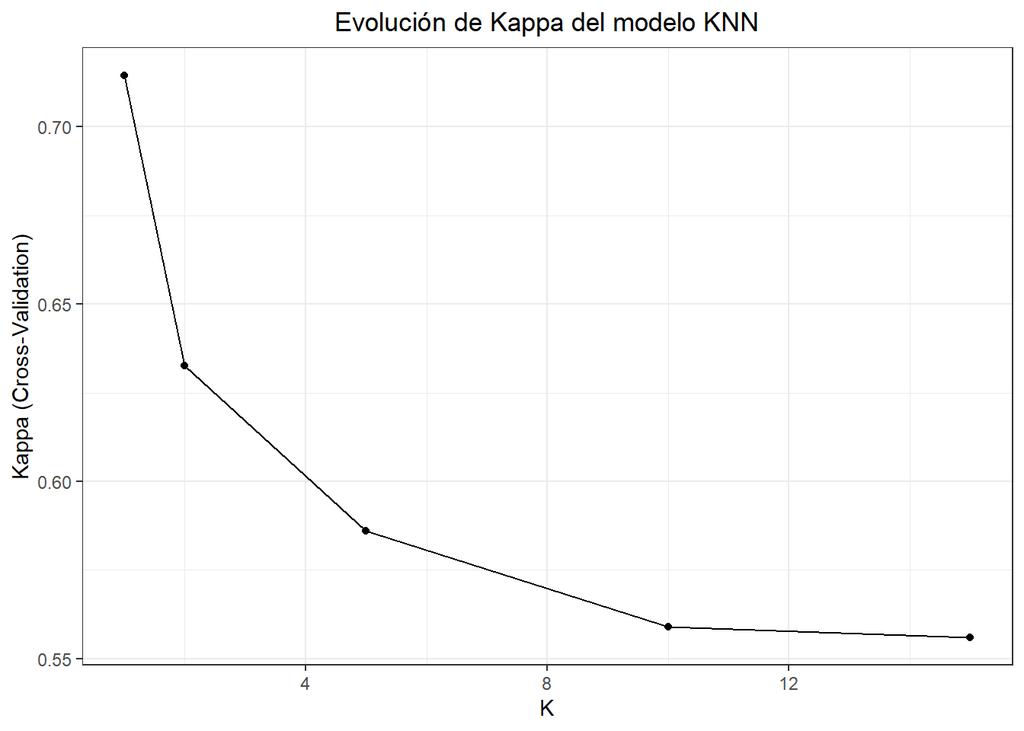

```r
# Gráfica de la evolución de k
ggplot(modelo_knn) +
  labs(title = "Evolución de Kappa del modelo KNN", x = "K") +
  theme_bw () +
  theme(plot.title = element_text(hjust = 0.5))
```

```r
# Predicciones
p <- predict(modelo_knn, newdata = dataset.test[,-(ncol(dataset.test))])

# Evaluación
(mconfusion_knn <- confusionMatrix(p, dataset.test$Clasificación, mode="everything", positive="NF"))
```

```
## Confusion Matrix and Statistics
##
##           Reference
## Prediction  AF FF/FL  NF
##      AF     30     4   9
##      FF/FL   0    29  18
##      NF     12    15 112
##
## Overall Statistics
##
##                Accuracy : 0.7467
##                  95% CI : (0.6852, 0.8017)
##     No Information Rate : 0.607
##     P-Value [Acc > NIR] : 5.907e-06
##
##                   Kappa : 0.5429
##
##  Mcnemar's Test P-Value : 0.195
##
## Statistics by Class:
##
##                      Class: AF Class: FF/FL Class: NF
## Sensitivity             0.7143       0.6042    0.8058
## Specificity             0.9305       0.9006    0.7000
## Pos Pred Value          0.6977       0.6170    0.8058
## Neg Pred Value          0.9355       0.8956    0.7000
## Precision               0.6977       0.6170    0.8058
## Recall                  0.7143       0.6042    0.8058
## F1                      0.7059       0.6105    0.8058
## Prevalence              0.1834       0.2096    0.6070
## Detection Rate          0.1310       0.1266    0.4891
## Detection Prevalence    0.1878       0.2052    0.6070
## Balanced Accuracy       0.8224       0.7524    0.7529
```

```r
resultados_knn <- data.frame(
  Modelo        = "KNN",
  Precisión     = round((ifelse(is.na(mconfusion_knn$byClass[1,5]), 0, mconfusion_knn$byClass[1,5]) +
                         ifelse(is.na(mconfusion_knn$byClass[2,5]), 0, mconfusion_knn$byClass[2,5]) +
                         ifelse(is.na(mconfusion_knn$byClass[3,5]), 0, mconfusion_knn$byClass[3,5])) / 3, 3),
  Sensibilidad  = round((ifelse(is.na(mconfusion_knn$byClass[1,1]), 0, mconfusion_knn$byClass[1,1]) +
                         ifelse(is.na(mconfusion_knn$byClass[2,1]), 0, mconfusion_knn$byClass[2,1]) +
                         ifelse(is.na(mconfusion_knn$byClass[3,1]), 0, mconfusion_knn$byClass[3,1])) / 3, 3),
  Especificidad = round((ifelse(is.na(mconfusion_knn$byClass[1,2]), 0, mconfusion_knn$byClass[1,2]) +
                         ifelse(is.na(mconfusion_knn$byClass[2,2]), 0, mconfusion_knn$byClass[2,2]) +
                         ifelse(is.na(mconfusion_knn$byClass[3,2]), 0, mconfusion_knn$byClass[3,2])) / 3, 3),
  kappa         = round(mconfusion_knn[["overall"]][["Kappa"]], 3),
  F1            = round((ifelse(is.na(mconfusion_knn$byClass[1,7]), 0, mconfusion_knn$byClass[1,7]) +
                         ifelse(is.na(mconfusion_knn$byClass[2,7]), 0, mconfusion_knn$byClass[2,7]) +
                         ifelse(is.na(mconfusion_knn$byClass[3,7]), 0, mconfusion_knn$byClass[3,7])) / 3, 3),
  Error_clasificación = round((1 - mconfusion_knn[["overall"]][["Accuracy"]]) * 100, 3),
  Accuracy      = round(mconfusion_knn[["overall"]][["Accuracy"]], 3)
)

resultados_knn
```

```
##   Modelo Precisión Sensibilidad Especificidad kappa    F1 Error_clasificación
## 1    KNN     0.707        0.708         0.844 0.543 0.707              25.328
##   Accuracy
## 1    0.747
```

### 4.5.2 Naive Bayes

```r
# Hiperparámetros
hiperparametros <- expand.grid(usekernel = c(TRUE, FALSE),
                               fL = c(0:4),
                               adjust = c(1:5))

# Ajuste del modelo
set.seed(29)
(modelo_bayes = train(Clasificación ~ ., data = dataset.train_SMOTE,
                   method = "nb",
                   tuneGrid = hiperparametros,
                   metric = "Kappa",
                    trControl = fitControl))
```

```
## Naive Bayes
##
## 751 samples
##   7 predictor
##   3 classes: 'AF', 'FF/FL', 'NF'
##
## No pre-processing
## Resampling: Cross-Validated (10 fold)
## Summary of sample sizes: 675, 676, 676, 675, 676, 676, ...
## Resampling results across tuning parameters:
##
##   usekernel  fL  adjust  Accuracy   Kappa      Mean_F1    Mean_Sensitivity
##   FALSE      0   1       0.6166060  0.4223225  0.6295468  0.6382212
##   FALSE      0   2       0.6166060  0.4223225  0.6295468  0.6382212
##   FALSE      0   3       0.6166060  0.4223225  0.6295468  0.6382212
##   FALSE      0   4       0.6166060  0.4223225  0.6295468  0.6382212
##   FALSE      0   5       0.6166060  0.4223225  0.6295468  0.6382212
##   FALSE      1   1       0.6166060  0.4223225  0.6295468  0.6382212
##   FALSE      1   2       0.6166060  0.4223225  0.6295468  0.6382212
##   FALSE      1   3       0.6166060  0.4223225  0.6295468  0.6382212
##   FALSE      1   4       0.6166060  0.4223225  0.6295468  0.6382212
##   FALSE      1   5       0.6166060  0.4223225  0.6295468  0.6382212
##   FALSE      2   1       0.6166060  0.4223225  0.6295468  0.6382212
##   FALSE      2   2       0.6166060  0.4223225  0.6295468  0.6382212
##   FALSE      2   3       0.6166060  0.4223225  0.6295468  0.6382212
##   FALSE      2   4       0.6166060  0.4223225  0.6295468  0.6382212
##   FALSE      2   5       0.6166060  0.4223225  0.6295468  0.6382212
##   FALSE      3   1       0.6166060  0.4223225  0.6295468  0.6382212
##   FALSE      3   2       0.6166060  0.4223225  0.6295468  0.6382212
##   FALSE      3   3       0.6166060  0.4223225  0.6295468  0.6382212
##   FALSE      3   4       0.6166060  0.4223225  0.6295468  0.6382212
##   FALSE      3   5       0.6166060  0.4223225  0.6295468  0.6382212
##   FALSE      4   1       0.6166060  0.4223225  0.6295468  0.6382212
##   FALSE      4   2       0.6166060  0.4223225  0.6295468  0.6382212
##   FALSE      4   3       0.6166060  0.4223225  0.6295468  0.6382212
##   FALSE      4   4       0.6166060  0.4223225  0.6295468  0.6382212
##   FALSE      4   5       0.6166060  0.4223225  0.6295468  0.6382212
##    TRUE      0   1       0.6111849  0.4096577  0.6231199  0.6322340
##    TRUE      0   2       0.6284836  0.4351237  0.6404756  0.6443297
##    TRUE      0   3       0.6085358  0.4067926  0.6206045  0.6227142
```

[output cut: 113 more lines]

```
##   0.5686947    0.1859783            0.6728711
##   0.6322340    0.2037283            0.7159738
##   0.6443297    0.2094945            0.7266060
##   0.6227142    0.2028453            0.7115366
##   0.6006024    0.1957101            0.6958876
##   0.5686947    0.1859783            0.6728711
##   0.6322340    0.2037283            0.7159738
##   0.6443297    0.2094945            0.7266060
##   0.6227142    0.2028453            0.7115366
##   0.6006024    0.1957101            0.6958876
##   0.5686947    0.1859783            0.6728711
##
## Kappa was used to select the optimal model using the largest value.
## The final values used for the model were fL = 0, usekernel = TRUE and adjust
##  = 2.
```

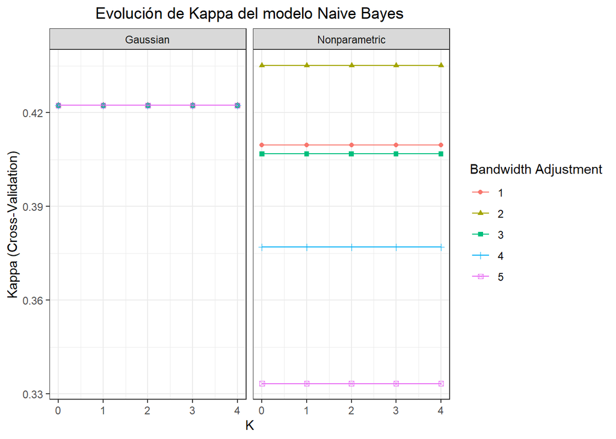

```r
# Gráfica
ggplot(modelo_bayes) +
  labs(title = "Evolución de Kappa del modelo Naive Bayes", x = "K") +
  theme_bw() +
  theme(plot.title = element_text(hjust = 0.5))
```

```r
# Predicciones
p <- predict(modelo_bayes, dataset.test[1:(ncol(dataset.test)-1)])

# Evaluación
(mconfusion_Bayes <- confusionMatrix(p, dataset.test$Clasificación, mode="everything", positive="NF"))
```

```
## Confusion Matrix and Statistics
##
##           Reference
## Prediction AF FF/FL NF
##      AF    29     1 15
##      FF/FL  4    31 50
##      NF     9    16 74
##
## Overall Statistics
##
##                Accuracy : 0.5852
##                  95% CI : (0.5184, 0.6497)
##     No Information Rate : 0.607
##     P-Value [Acc > NIR] : 0.772221
##
##                   Kappa : 0.3349
##
##  Mcnemar's Test P-Value : 0.000115
##
## Statistics by Class:
##
##                      Class: AF Class: FF/FL Class: NF
## Sensitivity             0.6905       0.6458    0.5324
## Specificity             0.9144       0.7017    0.7222
## Pos Pred Value          0.6444       0.3647    0.7475
## Neg Pred Value          0.9293       0.8819    0.5000
## Precision               0.6444       0.3647    0.7475
## Recall                  0.6905       0.6458    0.5324
## F1                      0.6667       0.4662    0.6218
## Prevalence              0.1834       0.2096    0.6070
## Detection Rate          0.1266       0.1354    0.3231
## Detection Prevalence    0.1965       0.3712    0.4323
## Balanced Accuracy       0.8025       0.6737    0.6273
```

```r
resultados_NaiveBayes <- data.frame(
  Modelo        = "Naive Bayes",
  Precisión     = round((ifelse(is.na(mconfusion_Bayes$byClass[1,5]), 0, mconfusion_Bayes$byClass[1,5]) +
                        ifelse(is.na(mconfusion_Bayes$byClass[2,5]), 0, mconfusion_Bayes$byClass[2,5]) +
                        ifelse(is.na(mconfusion_Bayes$byClass[3,5]), 0, mconfusion_Bayes$byClass[3,5])
                        ) / 3, 3),
  Sensibilidad  = round((ifelse(is.na(mconfusion_Bayes$byClass[1,1]), 0, mconfusion_Bayes$byClass[1,1]) +
                        ifelse(is.na(mconfusion_Bayes$byClass[2,1]), 0, mconfusion_Bayes$byClass[2,1]) +
                        ifelse(is.na(mconfusion_Bayes$byClass[3,1]), 0, mconfusion_Bayes$byClass[3,1])
                        ) / 3, 3),
  Especificidad = round((ifelse(is.na(mconfusion_Bayes$byClass[1,2]), 0, mconfusion_Bayes$byClass[1,2]) +
                        ifelse(is.na(mconfusion_Bayes$byClass[2,2]), 0, mconfusion_Bayes$byClass[2,2]) +
                        ifelse(is.na(mconfusion_Bayes$byClass[3,2]), 0, mconfusion_Bayes$byClass[3,2])
                        ) / 3, 3),
  kappa         = round(mconfusion_Bayes[["overall"]][["Kappa"]], 3),
  F1            = round((ifelse(is.na(mconfusion_Bayes$byClass[1,7]), 0, mconfusion_Bayes$byClass[1,7]) +
                        ifelse(is.na(mconfusion_Bayes$byClass[2,7]), 0, mconfusion_Bayes$byClass[2,7]) +
                        ifelse(is.na(mconfusion_Bayes$byClass[3,7]), 0, mconfusion_Bayes$byClass[3,7])
                        ) / 3, 3),
  Error_clasificación = round((1 - mconfusion_Bayes[["overall"]][["Accuracy"]]) * 100, 3),
  Accuracy      = round(mconfusion_Bayes[["overall"]][["Accuracy"]], 3)
)

resultados_NaiveBayes
```

```
##        Modelo Precisión Sensibilidad Especificidad kappa    F1
## 1 Naive Bayes     0.586        0.623         0.779 0.335 0.585
##   Error_clasificación Accuracy
## 1              41.485    0.585
```

### 4.5.4 ANN

```r
#hiperparametros
hiperparametros = expand.grid(size = c(1, 3, 5, 50, 100, 115, 125, 150, 170),
                               decay = c(0.0001, 0.00001, 0.001, 0.01, 0.1))

# Ajuste del modelo
set.seed(29)

(modelo_ann <- train(Clasificación ~ ., data = dataset.train_SMOTE,
                    method = "nnet",
                    tuneGrid = hiperparametros,
                    metric = "Kappa",
                    trControl = fitControl,
                    MaxNWts = 2000,
                    trace = FALSE))
```

```
## Neural Network
##
## 751 samples
##   7 predictor
##   3 classes: 'AF', 'FF/FL', 'NF'
##
## No pre-processing
## Resampling: Cross-Validated (10 fold)
## Summary of sample sizes: 675, 676, 676, 675, 676, 676, ...
## Resampling results across tuning parameters:
##
##   size  decay  Accuracy   Kappa      Mean_F1    Mean_Sensitivity
##     1   1e-05  0.5604229  0.2996654  0.4462550  0.5486950
##     1   1e-04  0.5617212  0.3087571  0.4947486  0.5587331
##     1   1e-03  0.5564225  0.2939922  0.4462550  0.5456647
##     1   1e-02  0.5484054  0.2974657  0.5335986  0.5580553
##     1   1e-01  0.5404931  0.2884015  0.5454388  0.5537879
##     3   1e-05  0.6630441  0.4815712  0.6675968  0.6734413
##     3   1e-04  0.6845733  0.5144134  0.6870797  0.6936751
##     3   1e-03  0.6832432  0.5121949  0.6866389  0.6934264
##     3   1e-02  0.6911361  0.5246713  0.6975636  0.7002055
##     3   1e-01  0.7431944  0.6060274  0.7483549  0.7516623
##     5   1e-05  0.6887179  0.5248637  0.6978090  0.7058578
##     5   1e-04  0.7139478  0.5614419  0.7225756  0.7264419
##     5   1e-03  0.7151062  0.5654291  0.7221918  0.7299176
##     5   1e-02  0.7018383  0.5445161  0.7123996  0.7166215
##     5   1e-01  0.7351939  0.5936383  0.7424076  0.7442250
##    50   1e-05  0.7419682  0.6058721  0.7506302  0.7560089
##    50   1e-04  0.7456842  0.6143019  0.7535278  0.7638773
##    50   1e-03  0.7735439  0.6558108  0.7809056  0.7905881
##    50   1e-02  0.7697914  0.6503585  0.7799316  0.7885473
##    50   1e-01  0.7711788  0.6509050  0.7811640  0.7863701
##   100   1e-05  0.7630550  0.6410176  0.7710923  0.7835095
##   100   1e-04  0.7564386  0.6287070  0.7644623  0.7701346
##   100   1e-03  0.7909322  0.6814623  0.7994763  0.8054101
##   100   1e-02  0.7896159  0.6798673  0.7958738  0.8031281
##   100   1e-01  0.7725121  0.6525454  0.7812052  0.7866366
##   115   1e-05  0.7457710  0.6158791  0.7546261  0.7686560
##   115   1e-04  0.7922466  0.6841398  0.8000060  0.8085340
##   115   1e-03  0.7683163  0.6488118  0.7753793  0.7857584
```

[output cut: 97 more lines]

```
##   0.7973525    0.2601238            0.8422842
##   0.7913306    0.2596795            0.8379936
##   0.7973167    0.2588138            0.8419595
##   0.7873716    0.2565974            0.8346269
##   0.8186568    0.2671818            0.8586508
##   0.8052063    0.2623278            0.8479986
##   0.7970456    0.2601475            0.8415997
##   0.7871999    0.2566509            0.8343036
##   0.8130022    0.2649768            0.8542940
##   0.8043982    0.2627786            0.8478360
##   0.7967525    0.2600648            0.8416825
##   0.8114238    0.2650307            0.8528353
##
## Kappa was used to select the optimal model using the largest value.
## The final values used for the model were size = 150 and decay = 0.001.
```

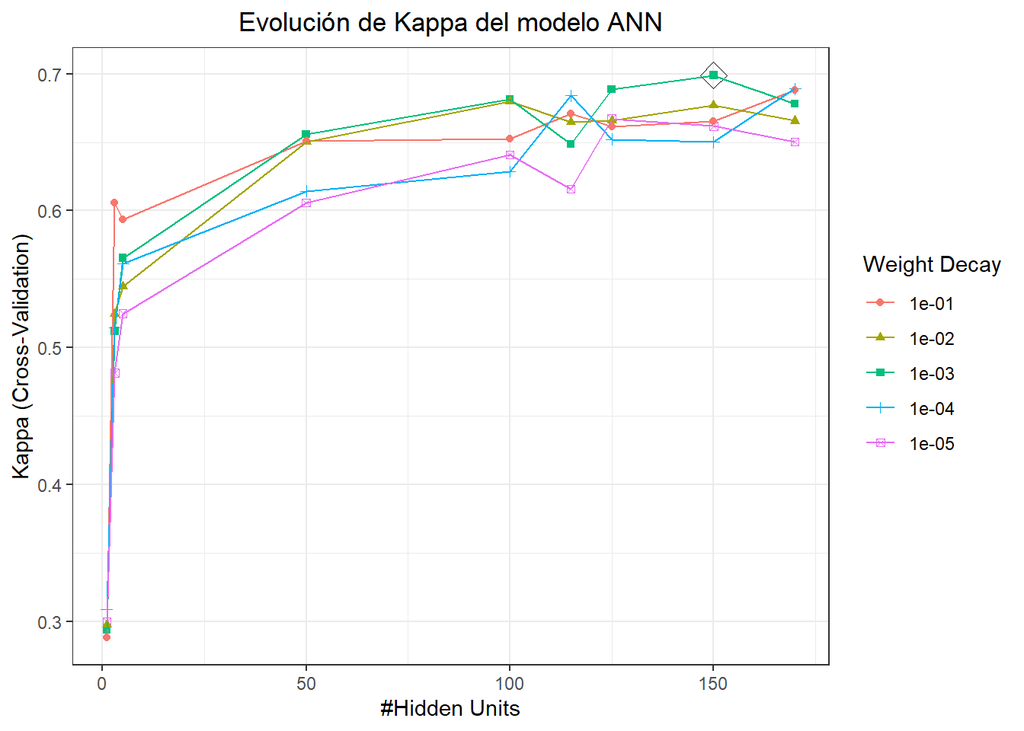

```r
# Gráfica
ggplot(modelo_ann, highlight = TRUE) +
  labs(title = "Evolución de Kappa del modelo ANN") +
  theme_bw()+
  theme(plot.title = element_text(hjust = 0.5))
```

```r
# Predicciones
p <- predict(modelo_ann, newdata = dataset.test[1:(ncol(dataset.test)-1)])

# Evaluación
res = table(p, dataset.test$Clasificación)
(mconfusion_ann = confusionMatrix(res, mode="everything", positive="NF"))
```

```
## Confusion Matrix and Statistics
##
##
## p        AF FF/FL  NF
##   AF     26     2   6
##   FF/FL   0    25  21
##   NF     16    21 112
##
## Overall Statistics
##
##                Accuracy : 0.7118
##                  95% CI : (0.6485, 0.7695)
##     No Information Rate : 0.607
##     P-Value [Acc > NIR] : 0.0006035
##
##                   Kappa : 0.462
##
##  Mcnemar's Test P-Value : 0.0878870
##
## Statistics by Class:
##
##                      Class: AF Class: FF/FL Class: NF
## Sensitivity             0.6190       0.5208    0.8058
## Specificity             0.9572       0.8840    0.5889
## Pos Pred Value          0.7647       0.5435    0.7517
## Neg Pred Value          0.9179       0.8743    0.6625
## Precision               0.7647       0.5435    0.7517
## Recall                  0.6190       0.5208    0.8058
## F1                      0.6842       0.5319    0.7778
## Prevalence              0.1834       0.2096    0.6070
## Detection Rate          0.1135       0.1092    0.4891
## Detection Prevalence    0.1485       0.2009    0.6507
## Balanced Accuracy       0.7881       0.7024    0.6973
```

```r
resultados_ann <- data.frame(
  Modelo        = "ANN",
  Precisión     = round((ifelse(is.na(mconfusion_ann$byClass[1,5]), 0, mconfusion_ann$byClass[1,5]) +
                        ifelse(is.na(mconfusion_ann$byClass[2,5]), 0, mconfusion_ann$byClass[2,5]) +
                        ifelse(is.na(mconfusion_ann$byClass[3,5]), 0, mconfusion_ann$byClass[3,5])
                        ) / 3, 3),
  Sensibilidad  = round((ifelse(is.na(mconfusion_ann$byClass[1,1]), 0, mconfusion_ann$byClass[1,1]) +
                        ifelse(is.na(mconfusion_ann$byClass[2,1]), 0, mconfusion_ann$byClass[2,1]) +
                        ifelse(is.na(mconfusion_ann$byClass[3,1]), 0, mconfusion_ann$byClass[3,1])
                        ) / 3, 3),
  Especificidad = round((ifelse(is.na(mconfusion_ann$byClass[1,2]), 0, mconfusion_ann$byClass[1,2]) +
                        ifelse(is.na(mconfusion_ann$byClass[2,2]), 0, mconfusion_ann$byClass[2,2]) +
                        ifelse(is.na(mconfusion_ann$byClass[3,2]), 0, mconfusion_ann$byClass[3,2])
                        ) / 3, 3),
  kappa         = round(mconfusion_ann[["overall"]][["Kappa"]], 3),
  F1            = round((ifelse(is.na(mconfusion_ann$byClass[1,7]), 0, mconfusion_ann$byClass[1,7]) +
                        ifelse(is.na(mconfusion_ann$byClass[2,7]), 0, mconfusion_ann$byClass[2,7]) +
                        ifelse(is.na(mconfusion_ann$byClass[3,7]), 0, mconfusion_ann$byClass[3,7])
                       ) / 3, 3),
  Error_clasificación = round((1 - mconfusion_ann[["overall"]][["Accuracy"]]) * 100, 3),
  Accuracy      = round(mconfusion_ann[["overall"]][["Accuracy"]], 3)
)

resultados_ann
```

```
##   Modelo Precisión Sensibilidad Especificidad kappa    F1 Error_clasificación
## 1    ANN     0.687        0.649          0.81 0.462 0.665              28.821
##   Accuracy
## 1    0.712
```

### 4.5.5 Support Vector Machine

#### 4.5.5.1 SVM-lineal

```r
# Hiperparámetros
hiperparametros = data.frame(C = c(0.5,1,5,10,15,20,30, 50))

# Ajuste del modelo
set.seed(29)
(modelo_svmlineal = train(Clasificación ~ ., data = dataset.train_SMOTE,
                          method = "svmLinear",
                          tuneGrid = hiperparametros,
                          metric = "Kappa",
                          trControl = fitControl
                          ))
```

```
## Support Vector Machines with Linear Kernel
##
## 751 samples
##   7 predictor
##   3 classes: 'AF', 'FF/FL', 'NF'
##
## No pre-processing
## Resampling: Cross-Validated (10 fold)
## Summary of sample sizes: 675, 676, 676, 675, 676, 676, ...
## Resampling results across tuning parameters:
##
##   C     Accuracy   Kappa      Mean_F1    Mean_Sensitivity  Mean_Specificity
##    0.5  0.6458174  0.4403725  0.6322486  0.6329011         0.8060915
##    1.0  0.6497819  0.4461646  0.6387150  0.6370097         0.8077112
##    5.0  0.6510626  0.4485284  0.6384015  0.6387597         0.8086279
##   10.0  0.6523959  0.4503747  0.6397436  0.6398013         0.8092339
##   15.0  0.6537117  0.4525930  0.6410029  0.6414680         0.8100091
##   20.0  0.6510446  0.4484379  0.6384932  0.6387597         0.8086279
##   30.0  0.6510446  0.4484841  0.6384610  0.6387597         0.8086628
##   50.0  0.6510270  0.4488718  0.6380052  0.6394162         0.8089019
##   Mean_Pos_Pred_Value  Mean_Neg_Pred_Value  Mean_Precision  Mean_Recall
##   0.6761324            0.8194831            0.6761324       0.6329011
##   0.6828212            0.8206140            0.6828212       0.6370097
##   0.6796790            0.8221084            0.6796790       0.6387597
##   0.6817300            0.8228646            0.6817300       0.6398013
##   0.6824907            0.8236063            0.6824907       0.6414680
##   0.6798285            0.8218341            0.6798285       0.6387597
##   0.6804504            0.8218890            0.6804504       0.6387597
##   0.6808039            0.8219748            0.6808039       0.6394162
##   Mean_Detection_Rate  Mean_Balanced_Accuracy
##   0.2152725            0.7194963
##   0.2165940            0.7223605
##   0.2170209            0.7236938
##   0.2174653            0.7245176
##   0.2179039            0.7257386
##   0.2170149            0.7236938
##   0.2170149            0.7237112
##   0.2170090            0.7241591
##
## Kappa was used to select the optimal model using the largest value.
## The final value used for the model was C = 15.
```

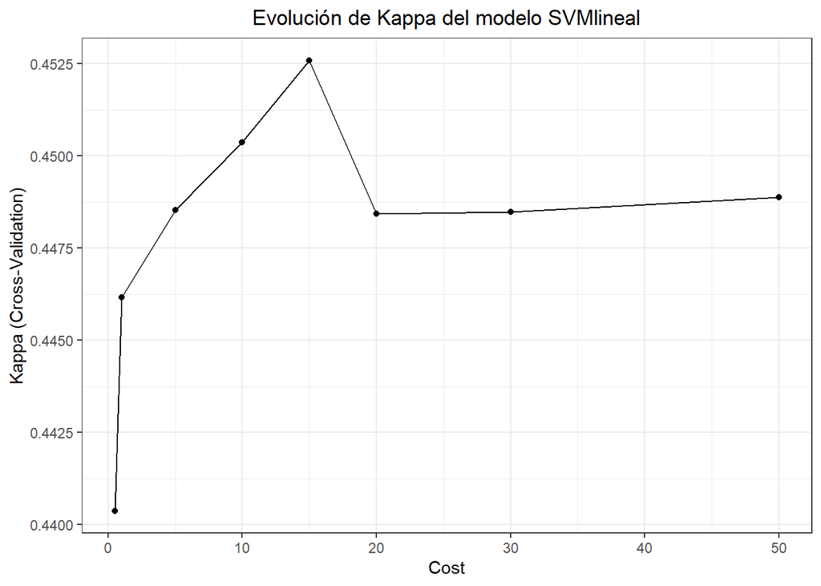

```r
# Gráfico
ggplot(modelo_svmlineal) +
  labs(title = "Evolución de Kappa del modelo SVMlineal") +
  theme_bw() +
  theme(plot.title = element_text(hjust = 0.5))
```

```r
# Predicciones
p = predict(modelo_svmlineal, newdata = dataset.test[1:(ncol(dataset.test)-1)])

# Evaluación
(mconfusion_svmlineal = confusionMatrix(p, dataset.test$Clasificación, mode="everything", positive="NF"))
```

```
## Confusion Matrix and Statistics
##
##           Reference
## Prediction  AF FF/FL  NF
##      AF     27     0  12
##      FF/FL   0    22  10
##      NF     15    26 117
##
## Overall Statistics
##
##                Accuracy : 0.7249
##                  95% CI : (0.6622, 0.7817)
##     No Information Rate : 0.607
##     P-Value [Acc > NIR] : 0.0001246
##
##                   Kappa : 0.4716
##
##  Mcnemar's Test P-Value : NA
##
## Statistics by Class:
##
##                      Class: AF Class: FF/FL Class: NF
## Sensitivity             0.6429      0.45833    0.8417
## Specificity             0.9358      0.94475    0.5444
## Pos Pred Value          0.6923      0.68750    0.7405
## Neg Pred Value          0.9211      0.86802    0.6901
## Precision               0.6923      0.68750    0.7405
## Recall                  0.6429      0.45833    0.8417
## F1                      0.6667      0.55000    0.7879
## Prevalence              0.1834      0.20961    0.6070
## Detection Rate          0.1179      0.09607    0.5109
## Detection Prevalence    0.1703      0.13974    0.6900
## Balanced Accuracy       0.7893      0.70154    0.6931
```

```r
resultados_svmlineal <- data.frame(
  Modelo              = "SVM lineal",
  Precisión           = round((ifelse(is.na(mconfusion_svmlineal$byClass[1,5]), 0, mconfusion_svmlineal$byClass[1,5]) +
                              ifelse(is.na(mconfusion_svmlineal$byClass[2,5]), 0, mconfusion_svmlineal$byClass[2,5]) +
                              ifelse(is.na(mconfusion_svmlineal$byClass[3,5]), 0, mconfusion_svmlineal$byClass[3,5])) / 3, 3),

  Sensibilidad        = round((ifelse(is.na(mconfusion_svmlineal$byClass[1,1]), 0, mconfusion_svmlineal$byClass[1,1]) +
                              ifelse(is.na(mconfusion_svmlineal$byClass[2,1]), 0, mconfusion_svmlineal$byClass[2,1]) +
                              ifelse(is.na(mconfusion_svmlineal$byClass[3,1]), 0, mconfusion_svmlineal$byClass[3,1])) / 3, 3),

  Especificidad       = round((ifelse(is.na(mconfusion_svmlineal$byClass[1,2]), 0, mconfusion_svmlineal$byClass[1,2]) +
                              ifelse(is.na(mconfusion_svmlineal$byClass[2,2]), 0, mconfusion_svmlineal$byClass[2,2]) +
                              ifelse(is.na(mconfusion_svmlineal$byClass[3,2]), 0, mconfusion_svmlineal$byClass[3,2])) / 3, 3),
  kappa               = round(mconfusion_svmlineal[["overall"]][["Kappa"]], 3),

  F1                  = round((ifelse(is.na(mconfusion_svmlineal$byClass[1,7]), 0, mconfusion_svmlineal$byClass[1,7]) +
                              ifelse(is.na(mconfusion_svmlineal$byClass[2,7]), 0, mconfusion_svmlineal$byClass[2,7]) +
                              ifelse(is.na(mconfusion_svmlineal$byClass[3,7]), 0, mconfusion_svmlineal$byClass[3,7])) / 3, 3),
  Error_clasificación = round((1 - mconfusion_svmlineal[["overall"]][["Accuracy"]]) * 100, 3),
  Accuracy            = round(mconfusion_svmlineal[["overall"]][["Accuracy"]], 3)
)

resultados_svmlineal
```

```
##       Modelo Precisión Sensibilidad Especificidad kappa    F1
## 1 SVM lineal     0.707        0.648         0.808 0.472 0.668
##   Error_clasificación Accuracy
## 1              27.511    0.725
```

#### 4.5.5.2 SVM-RBF o función gaussiana

```r
#Hiperparámetros
hiperparametros = expand.grid(sigma = c(0.1,0.5, 0.75, 1, 1.5, 2,3),
                               C = c(1,5,10,15,20,30))

# Ajuste del modelo
set.seed(29)
(modelo_svmradial = train(Clasificación ~ ., data = dataset.train_SMOTE,
                          method = "svmRadial",
                          tuneGrid = hiperparametros,
                         metric = "Kappa",
                    trControl = fitControl))
```

```
## Support Vector Machines with Radial Basis Function Kernel
##
## 751 samples
##   7 predictor
##   3 classes: 'AF', 'FF/FL', 'NF'
##
## No pre-processing
## Resampling: Cross-Validated (10 fold)
## Summary of sample sizes: 675, 676, 676, 675, 676, 676, ...
## Resampling results across tuning parameters:
##
##   sigma  C   Accuracy   Kappa      Mean_F1    Mean_Sensitivity
##   0.10    1  0.7271048  0.5752378  0.7270020  0.7268301
##   0.10    5  0.7283845  0.5816939  0.7346052  0.7376242
##   0.10   10  0.7324196  0.5908993  0.7402072  0.7472973
##   0.10   15  0.7404917  0.6045939  0.7493401  0.7582480
##   0.10   20  0.7484566  0.6172898  0.7585466  0.7681621
##   0.10   30  0.7431404  0.6099013  0.7537849  0.7645341
##   0.50    1  0.7683523  0.6437598  0.7759536  0.7782066
##   0.50    5  0.7857231  0.6736712  0.7955088  0.8032785
##   0.50   10  0.7911636  0.6822710  0.8004548  0.8087339
##   0.50   15  0.7871641  0.6758473  0.7959290  0.8033928
##   0.50   20  0.7804429  0.6662820  0.7897590  0.7990628
##   0.50   30  0.7857591  0.6746104  0.7946480  0.8043330
##   0.75    1  0.8017606  0.6944294  0.8092387  0.8081616
##   0.75    5  0.7870759  0.6754700  0.7955167  0.8026922
##   0.75   10  0.7870925  0.6756545  0.7957759  0.8032682
##   0.75   15  0.7831626  0.6696294  0.7919996  0.7988004
##   0.75   20  0.7938483  0.6863143  0.8020993  0.8096137
##   0.75   30  0.7938478  0.6858571  0.8021357  0.8083103
##   1.00    1  0.7937952  0.6812945  0.8013681  0.7984771
##   1.00    5  0.8003736  0.6947497  0.8089449  0.8129020
##   1.00   10  0.7965325  0.6894499  0.8048391  0.8102568
##   1.00   15  0.8005500  0.6953981  0.8086518  0.8136379
##   1.00   20  0.7951987  0.6875020  0.8034858  0.8092511
##   1.00   30  0.7938293  0.6857375  0.8027236  0.8090905
##   1.50    1  0.7737236  0.6480841  0.7811145  0.7736346
##   1.50    5  0.7951631  0.6842851  0.8030620  0.8014091
##   1.50   10  0.8004969  0.6926592  0.8082788  0.8068329
##   1.50   15  0.7977416  0.6887301  0.8058029  0.8051300
```

[output cut: 88 more lines]

```
##   0.7479718    0.2512818            0.8064404
##   0.7896153    0.2623992            0.8376611
##   0.7931369    0.2628261            0.8401508
##   0.7910311    0.2623757            0.8386279
##   0.7865515    0.2605917            0.8350419
##   0.7839631    0.2592523            0.8328593
##   0.7212393    0.2468012            0.7880297
##   0.7641045    0.2570066            0.8194813
##   0.7629997    0.2561057            0.8184510
##   0.7599063    0.2547664            0.8159425
##   0.7590595    0.2547722            0.8153794
##   0.7630656    0.2561116            0.8184966
##
## Kappa was used to select the optimal model using the largest value.
## The final values used for the model were sigma = 1 and C = 15.
```

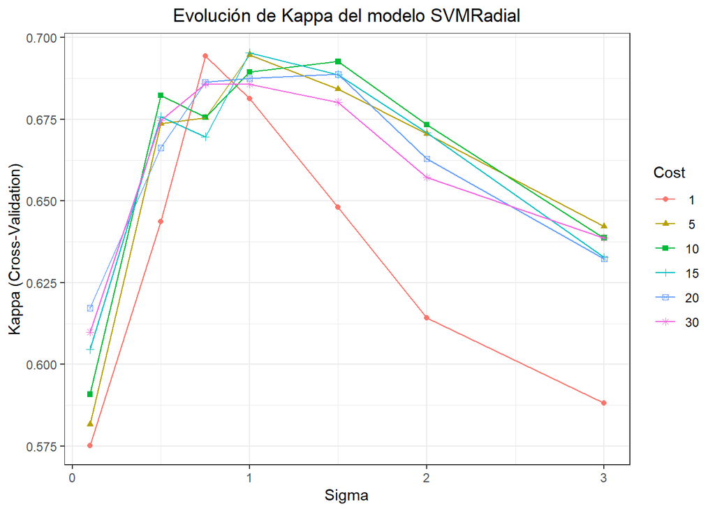

```r
# Gráfico
ggplot(modelo_svmradial) +
  labs(title = "Evolución de Kappa del modelo SVMRadial") +
  theme_bw() +
  theme(plot.title = element_text(hjust = 0.5))
```

```r
# Predicciones
p = predict(modelo_svmradial, newdata = dataset.test[1:(ncol(dataset.test)-1)])

# Evaluación
(mconfusion_svmradial = confusionMatrix(p, dataset.test$Clasificación, mode="everything", positive="NF"))
```

```
## Confusion Matrix and Statistics
##
##           Reference
## Prediction  AF FF/FL  NF
##      AF     22     4   4
##      FF/FL   0    23  20
##      NF     20    21 115
##
## Overall Statistics
##
##                Accuracy : 0.6987
##                  95% CI : (0.6348, 0.7574)
##     No Information Rate : 0.607
##     P-Value [Acc > NIR] : 0.002442
##
##                   Kappa : 0.424
##
##  Mcnemar's Test P-Value : 0.002101
##
## Statistics by Class:
##
##                      Class: AF Class: FF/FL Class: NF
## Sensitivity            0.52381       0.4792    0.8273
## Specificity            0.95722       0.8895    0.5444
## Pos Pred Value         0.73333       0.5349    0.7372
## Neg Pred Value         0.89950       0.8656    0.6712
## Precision              0.73333       0.5349    0.7372
## Recall                 0.52381       0.4792    0.8273
## F1                     0.61111       0.5055    0.7797
## Prevalence             0.18341       0.2096    0.6070
## Detection Rate         0.09607       0.1004    0.5022
## Detection Prevalence   0.13100       0.1878    0.6812
## Balanced Accuracy      0.74051       0.6843    0.6859
```

```r
resultados_SVM_radial <- data.frame(
  Modelo              = "SVM-Radial",
  Precisión           = round((ifelse(is.na(mconfusion_svmradial$byClass[1,5]), 0, mconfusion_svmradial$byClass[1,5]) +
                              ifelse(is.na(mconfusion_svmradial$byClass[2,5]), 0, mconfusion_svmradial$byClass[2,5]) +
                              ifelse(is.na(mconfusion_svmradial$byClass[3,5]), 0, mconfusion_svmradial$byClass[3,5])) / 3, 3),

  Sensibilidad        = round((ifelse(is.na(mconfusion_svmradial$byClass[1,1]), 0, mconfusion_svmradial$byClass[1,1]) +
                              ifelse(is.na(mconfusion_svmradial$byClass[2,1]), 0, mconfusion_svmradial$byClass[2,1]) +
                              ifelse(is.na(mconfusion_svmradial$byClass[3,1]), 0, mconfusion_svmradial$byClass[3,1]) ) / 3, 3),

  Especificidad       = round((ifelse(is.na(mconfusion_svmradial$byClass[1,2]), 0, mconfusion_svmradial$byClass[1,2]) +
                              ifelse(is.na(mconfusion_svmradial$byClass[2,2]), 0, mconfusion_svmradial$byClass[2,2]) +
                              ifelse(is.na(mconfusion_svmradial$byClass[3,2]), 0, mconfusion_svmradial$byClass[3,2]) ) / 3, 3),
  kappa               = round(mconfusion_svmradial[["overall"]][["Kappa"]], 3),
  F1                  = round((ifelse(is.na(mconfusion_svmradial$byClass[1,7]), 0, mconfusion_svmradial$byClass[1,7]) +
                              ifelse(is.na(mconfusion_svmradial$byClass[2,7]), 0, mconfusion_svmradial$byClass[2,7]) +
                              ifelse(is.na(mconfusion_svmradial$byClass[3,7]), 0, mconfusion_svmradial$byClass[3,7]) ) / 3, 3),
  Error_clasificación = round((1 - mconfusion_svmradial[["overall"]][["Accuracy"]]) * 100, 3),
  Accuracy            = round(mconfusion_svmradial[["overall"]][["Accuracy"]], 3)
)

resultados_SVM_radial
```

```
##       Modelo Precisión Sensibilidad Especificidad kappa    F1
## 1 SVM-Radial     0.668         0.61         0.797 0.424 0.632
##   Error_clasificación Accuracy
## 1              30.131    0.699
```

#### 4.5.5.3 SVM-polynomial

```r
# Hiperparámetros
hiperparametros = expand.grid(degree = c(1, 2,3, 4),
                               scale = c(0.1,0.2,0.3, 0.4, 0.5,0.6,0.7,1),
                               C = c(5,10,15,20,30,40,50,70,80, 90))

# Ajuste del modelo
set.seed(29)
(modelo_svmpoly = train(Clasificación ~ ., data = dataset.train_SMOTE,
                          method = "svmPoly",
                          tuneGrid = hiperparametros,
                          metric = "Kappa",
                    trControl = fitControl))
```

```
## Support Vector Machines with Polynomial Kernel
##
## 751 samples
##   7 predictor
##   3 classes: 'AF', 'FF/FL', 'NF'
##
## No pre-processing
## Resampling: Cross-Validated (10 fold)
## Summary of sample sizes: 675, 676, 676, 675, 676, 676, ...
## Resampling results across tuning parameters:
##
##   degree  scale  C   Accuracy   Kappa      Mean_F1    Mean_Sensitivity
##   1       0.1     5  0.6458174  0.4403725  0.6322486  0.6329011
##   1       0.1    10  0.6497819  0.4461646  0.6387150  0.6370097
##   1       0.1    15  0.6497999  0.4465104  0.6380938  0.6373148
##   1       0.1    20  0.6497643  0.4466677  0.6374111  0.6377496
##   1       0.1    30  0.6497112  0.4463247  0.6363658  0.6371568
##   1       0.1    40  0.6510626  0.4485387  0.6381509  0.6389112
##   1       0.1    50  0.6510626  0.4485284  0.6384015  0.6387597
##   1       0.1    70  0.6510626  0.4484522  0.6384513  0.6387597
##   1       0.1    80  0.6523959  0.4503747  0.6397436  0.6398013
##   1       0.1    90  0.6523959  0.4503747  0.6397436  0.6398013
##   1       0.2     5  0.6497819  0.4461646  0.6387150  0.6370097
##   1       0.2    10  0.6497643  0.4466677  0.6374111  0.6377496
##   1       0.2    15  0.6497112  0.4463247  0.6363658  0.6371568
##   1       0.2    20  0.6523784  0.4507570  0.6394102  0.6405778
##   1       0.2    30  0.6523959  0.4508045  0.6397469  0.6404263
##   1       0.2    40  0.6537117  0.4525930  0.6410029  0.6414680
##   1       0.2    50  0.6537117  0.4525930  0.6410029  0.6414680
##   1       0.2    70  0.6523959  0.4503747  0.6397436  0.6398013
##   1       0.2    80  0.6510446  0.4484379  0.6384932  0.6387597
##   1       0.2    90  0.6510446  0.4484379  0.6384932  0.6387597
##   1       0.3     5  0.6484666  0.4444939  0.6359420  0.6358655
##   1       0.3    10  0.6497112  0.4463247  0.6363658  0.6371568
##   1       0.3    15  0.6523959  0.4508045  0.6397469  0.6404263
##   1       0.3    20  0.6523959  0.4508045  0.6397469  0.6404263
##   1       0.3    30  0.6523959  0.4503747  0.6397436  0.6398013
##   1       0.3    40  0.6537117  0.4525930  0.6410029  0.6414680
##   1       0.3    50  0.6523959  0.4503747  0.6397436  0.6398013
##   1       0.3    70  0.6510446  0.4484841  0.6384610  0.6387597
```

[output cut: 922 more lines]

```
##   0.7559514    0.2454971            0.8105499
##   0.7528085    0.2450525            0.8082633
##   0.7544298    0.2446316            0.8090629
##   0.7490447    0.2428298            0.8049083
##   0.7533727    0.2446020            0.8085130
##   0.7555219    0.2454849            0.8102261
##   0.7453680    0.2419175            0.8021301
##   0.7404465    0.2401215            0.7984155
##   0.7446131    0.2419052            0.8017737
##   0.7502322    0.2436891            0.8059705
##   0.7518989    0.2441456            0.8072069
##   0.7528774    0.2445783            0.8079878
##
## Kappa was used to select the optimal model using the largest value.
## The final values used for the model were degree = 4, scale = 0.2 and C = 10.
```

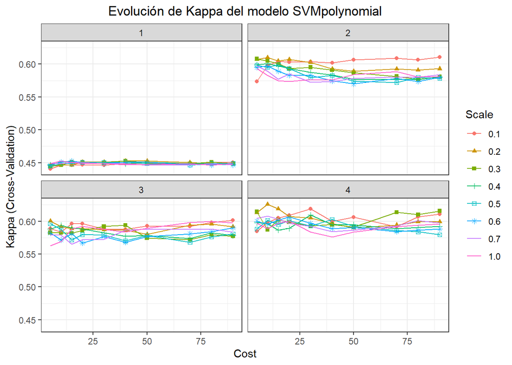

```r
# Gráfico
ggplot(modelo_svmpoly) +
  labs(title = "Evolución de Kappa del modelo SVMpolynomial") +
  theme_bw() +
  theme(plot.title = element_text(hjust = 0.5))
```

```r
# Predicciones
p = predict(modelo_svmpoly, newdata = dataset.test[1:(ncol(dataset.test)-1)])

# Evaluación
(mconfusion_svmpoly = confusionMatrix(p, dataset.test$Clasificación, mode="everything", positive="NF"))
```

```
## Confusion Matrix and Statistics
##
##           Reference
## Prediction  AF FF/FL  NF
##      AF     33     8  11
##      FF/FL   0    24  23
##      NF      9    16 105
##
## Overall Statistics
##
##                Accuracy : 0.7074
##                  95% CI : (0.6439, 0.7655)
##     No Information Rate : 0.607
##     P-Value [Acc > NIR] : 0.0009807
##
##                   Kappa : 0.4874
##
##  Mcnemar's Test P-Value : 0.0237996
##
## Statistics by Class:
##
##                      Class: AF Class: FF/FL Class: NF
## Sensitivity             0.7857       0.5000    0.7554
## Specificity             0.8984       0.8729    0.7222
## Pos Pred Value          0.6346       0.5106    0.8077
## Neg Pred Value          0.9492       0.8681    0.6566
## Precision               0.6346       0.5106    0.8077
## Recall                  0.7857       0.5000    0.7554
## F1                      0.7021       0.5053    0.7807
## Prevalence              0.1834       0.2096    0.6070
## Detection Rate          0.1441       0.1048    0.4585
## Detection Prevalence    0.2271       0.2052    0.5677
## Balanced Accuracy       0.8421       0.6865    0.7388
```

```r
resultados_SVM_poly <- data.frame(
  Modelo              = "SVM-poly",
  Precisión           = round((ifelse(is.na(mconfusion_svmpoly$byClass[1,5]), 0, mconfusion_svmpoly$byClass[1,5]) +
                              ifelse(is.na(mconfusion_svmpoly$byClass[2,5]), 0, mconfusion_svmpoly$byClass[2,5]) +
                              ifelse(is.na(mconfusion_svmpoly$byClass[3,5]), 0, mconfusion_svmpoly$byClass[3,5]) ) / 3, 3),

  Sensibilidad        = round((ifelse(is.na(mconfusion_svmpoly$byClass[1,1]), 0, mconfusion_svmpoly$byClass[1,1]) +
                              ifelse(is.na(mconfusion_svmpoly$byClass[2,1]), 0, mconfusion_svmpoly$byClass[2,1]) +
                              ifelse(is.na(mconfusion_svmpoly$byClass[3,1]), 0, mconfusion_svmpoly$byClass[3,1]) ) / 3, 3),

  Especificidad       = round((ifelse(is.na(mconfusion_svmpoly$byClass[1,2]), 0, mconfusion_svmpoly$byClass[1,2]) +
                              ifelse(is.na(mconfusion_svmpoly$byClass[2,2]), 0, mconfusion_svmpoly$byClass[2,2]) +
                              ifelse(is.na(mconfusion_svmpoly$byClass[3,2]), 0, mconfusion_svmpoly$byClass[3,2]) ) /3, 3),
  kappa               = round(mconfusion_svmpoly[["overall"]][["Kappa"]], 3),
  F1                  = round((ifelse(is.na(mconfusion_svmpoly$byClass[1,7]), 0, mconfusion_svmpoly$byClass[1,7]) +
                              ifelse(is.na(mconfusion_svmpoly$byClass[2,7]), 0, mconfusion_svmpoly$byClass[2,7]) +
                              ifelse(is.na(mconfusion_svmpoly$byClass[3,7]), 0, mconfusion_svmpoly$byClass[3,7]) ) / 3, 3),
  Error_clasificación = round((1 - mconfusion_svmpoly[["overall"]][["Accuracy"]]) * 100, 3),
  Accuracy            = round(mconfusion_svmpoly[["overall"]][["Accuracy"]], 3)
)

resultados_SVM_poly
```

```
##     Modelo Precisión Sensibilidad Especificidad kappa    F1 Error_clasificación
## 1 SVM-poly     0.651         0.68         0.831 0.487 0.663              29.258
##   Accuracy
## 1    0.707
```

### 4.5.6 Árbol de decisión

```r
#Hiperparámetros
hiperparametros <- expand.grid(trials = c(10:70,80,90, 100),
                               model = c("tree", "rules"),
                               winnow = c(FALSE))

# Ajuste del modelo
set.seed(29)
(modelo_C5.0 <- train(Clasificación ~ ., data = dataset.train_SMOTE,
                     method = "C5.0",
                     tuneGrid = hiperparametros,
                     metric = "Kappa",
                     trControl = fitControl
                     ))
```

```
## C5.0
##
## 751 samples
##   7 predictor
##   3 classes: 'AF', 'FF/FL', 'NF'
##
## No pre-processing
## Resampling: Cross-Validated (10 fold)
## Summary of sample sizes: 675, 676, 676, 675, 676, 676, ...
## Resampling results across tuning parameters:
##
##   model  trials  Accuracy   Kappa      Mean_F1    Mean_Sensitivity
##   rules   10     0.7363855  0.5952172  0.7415395  0.7468245
##   rules   11     0.7324561  0.5887832  0.7390412  0.7423477
##   rules   12     0.7310156  0.5869327  0.7361935  0.7414232
##   rules   13     0.7403855  0.5989336  0.7420063  0.7463722
##   rules   14     0.7418620  0.6040174  0.7477390  0.7532100
##   rules   15     0.7431769  0.6054927  0.7493264  0.7535390
##   rules   16     0.7285443  0.5822399  0.7338285  0.7374380
##   rules   17     0.7444576  0.6070638  0.7482645  0.7529341
##   rules   18     0.7178777  0.5676865  0.7256420  0.7308270
##   rules   19     0.7418611  0.6046435  0.7482598  0.7533619
##   rules   20     0.7365092  0.5973475  0.7434472  0.7513003
##   rules   21     0.7432124  0.6065571  0.7495825  0.7560406
##   rules   22     0.7271754  0.5813694  0.7334867  0.7400034
##   rules   23     0.7284723  0.5821875  0.7316833  0.7403132
##   rules   24     0.7297890  0.5852760  0.7358907  0.7419866
##   rules   25     0.7256458  0.5770044  0.7275731  0.7364187
##   rules   26     0.7217165  0.5730489  0.7273888  0.7347987
##   rules   27     0.7257710  0.5784582  0.7301221  0.7371989
##   rules   28     0.7297715  0.5863832  0.7345074  0.7444903
##   rules   29     0.7271043  0.5806154  0.7310721  0.7385823
##   rules   30     0.7243665  0.5769351  0.7280505  0.7374704
##   rules   31     0.7310868  0.5873128  0.7343822  0.7432765
##   rules   32     0.7283665  0.5836346  0.7321560  0.7416008
##   rules   33     0.7284552  0.5839092  0.7318975  0.7416640
##   rules   34     0.7297003  0.5855015  0.7329391  0.7420716
##   rules   35     0.7350877  0.5940147  0.7385439  0.7478320
##   rules   36     0.7296472  0.5851690  0.7332690  0.7416008
##   rules   37     0.7324381  0.5886262  0.7351535  0.7429348
```

[output cut: 348 more lines]

```
##   0.7531842    0.2494383            0.8098837
##   0.7428759    0.2458883            0.8018405
##   0.7500592    0.2481049            0.8073597
##   0.7509691    0.2481287            0.8080052
##   0.7491781    0.2480991            0.8067757
##   0.7550095    0.2498830            0.8112664
##   0.7501882    0.2485377            0.8075952
##   0.7436390    0.2467715            0.8026529
##   0.7531132    0.2494620            0.8097911
##   0.7532957    0.2499066            0.8100308
##
## Tuning parameter 'winnow' was held constant at a value of FALSE
## Kappa was used to select the optimal model using the largest value.
## The final values used for the model were trials = 38, model = tree and winnow
##  = FALSE.
```

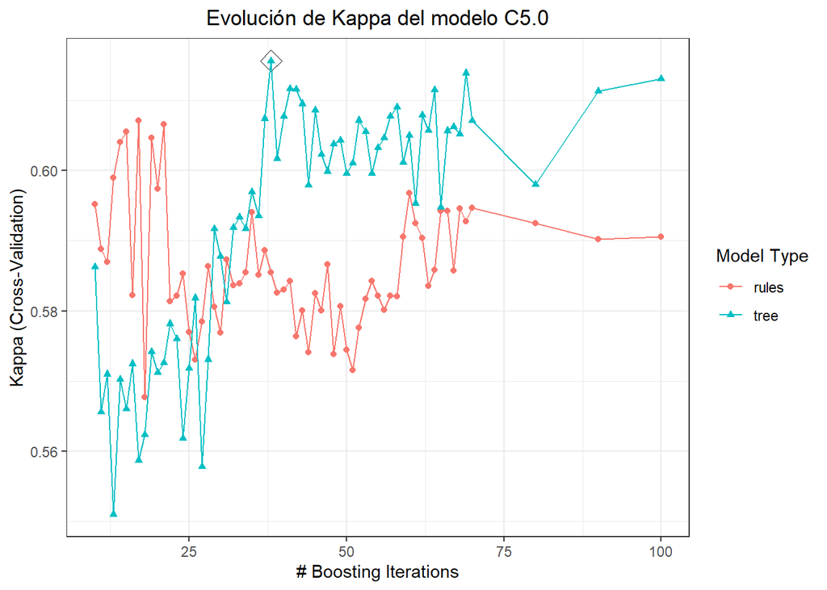

```r
# Gráfico
ggplot(modelo_C5.0, highlight = TRUE) +
  labs(title = "Evolución de Kappa del modelo C5.0") +
  theme_bw() +
  theme(plot.title = element_text(hjust = 0.5))
```

```r
# Predicciones
p <- predict(modelo_C5.0, dataset.test[1:(ncol(dataset.test)-1)])

# Evaluación
(mconfusion_arbol = confusionMatrix(data = p, reference = dataset.test$Clasificación, mode="everything", positive="NF"))
```

```
## Confusion Matrix and Statistics
##
##           Reference
## Prediction  AF FF/FL  NF
##      AF     28     0   9
##      FF/FL   2    26   7
##      NF     12    22 123
##
## Overall Statistics
##
##                Accuracy : 0.7729
##                  95% CI : (0.7131, 0.8255)
##     No Information Rate : 0.607
##     P-Value [Acc > NIR] : 7.291e-08
##
##                   Kappa : 0.5651
##
##  Mcnemar's Test P-Value : 0.01704
##
## Statistics by Class:
##
##                      Class: AF Class: FF/FL Class: NF
## Sensitivity             0.6667       0.5417    0.8849
## Specificity             0.9519       0.9503    0.6222
## Pos Pred Value          0.7568       0.7429    0.7834
## Neg Pred Value          0.9271       0.8866    0.7778
## Precision               0.7568       0.7429    0.7834
## Recall                  0.6667       0.5417    0.8849
## F1                      0.7089       0.6265    0.8311
## Prevalence              0.1834       0.2096    0.6070
## Detection Rate          0.1223       0.1135    0.5371
## Detection Prevalence    0.1616       0.1528    0.6856
## Balanced Accuracy       0.8093       0.7460    0.7536
```

```r
resultados_arbol <- data.frame(
  Modelo              = "Árbol",
  Precisión           = round((ifelse(is.na(mconfusion_arbol$byClass[1,5]), 0, mconfusion_arbol$byClass[1,5]) +
                              ifelse(is.na(mconfusion_arbol$byClass[2,5]), 0, mconfusion_arbol$byClass[2,5]) +
                              ifelse(is.na(mconfusion_arbol$byClass[3,5]), 0, mconfusion_arbol$byClass[3,5]) ) / 3, 3),
  Sensibilidad        = round((ifelse(is.na(mconfusion_arbol$byClass[1,1]), 0, mconfusion_arbol$byClass[1,1]) +
                              ifelse(is.na(mconfusion_arbol$byClass[2,1]), 0, mconfusion_arbol$byClass[2,1]) +
                              ifelse(is.na(mconfusion_arbol$byClass[3,1]), 0, mconfusion_arbol$byClass[3,1]) ) / 3, 3),

  Especificidad       = round((ifelse(is.na(mconfusion_arbol$byClass[1,2]), 0, mconfusion_arbol$byClass[1,2]) +
                              ifelse(is.na(mconfusion_arbol$byClass[2,2]), 0, mconfusion_arbol$byClass[2,2]) +
                              ifelse(is.na(mconfusion_arbol$byClass[3,2]), 0, mconfusion_arbol$byClass[3,2])) / 3, 3),

  kappa               = round(mconfusion_arbol[["overall"]][["Kappa"]], 3),
  F1                  = round((ifelse(is.na(mconfusion_arbol$byClass[1,7]), 0, mconfusion_arbol$byClass[1,7]) +
                              ifelse(is.na(mconfusion_arbol$byClass[2,7]), 0, mconfusion_arbol$byClass[2,7]) +
                              ifelse(is.na(mconfusion_arbol$byClass[3,7]), 0, mconfusion_arbol$byClass[3,7]) ) / 3, 3),
  Error_clasificación = round((1 - mconfusion_arbol[["overall"]][["Accuracy"]]) * 100, 3),
  Accuracy            = round(mconfusion_arbol[["overall"]][["Accuracy"]], 3)
)

resultados_arbol
```

```
##   Modelo Precisión Sensibilidad Especificidad kappa    F1 Error_clasificación
## 1  Árbol     0.761        0.698         0.841 0.565 0.722              22.707
##   Accuracy
## 1    0.773
```

### 4.5.7 Random Forest

```r
# Hiperparámetros
hiperparametros <- expand.grid(mtry = c(1:5),
                               min.node.size = c(# 0.5,
                                                  1,2,3,4),
                               splitrule = c("gini","extratrees"))

# Ajuste del modelo
set.seed(29)
(modelo_forest <- train(Clasificación ~ ., data = dataset.train_SMOTE,
                   method = "ranger",
                   tuneGrid = hiperparametros,
                   metric = "Kappa",
                   trControl = fitControl,
                   # Número de árboles ajustados
                   num.trees = 500)
)
```

```
## Random Forest
##
## 751 samples
##   7 predictor
##   3 classes: 'AF', 'FF/FL', 'NF'
##
## No pre-processing
## Resampling: Cross-Validated (10 fold)
## Summary of sample sizes: 675, 676, 676, 675, 676, 676, ...
## Resampling results across tuning parameters:
##
##   mtry  min.node.size  splitrule   Accuracy   Kappa      Mean_F1
##   1     1              gini        0.7829312  0.6634422  0.7863945
##   1     1              extratrees  0.7655785  0.6315568  0.7611219
##   1     2              gini        0.7750019  0.6506695  0.7781321
##   1     2              extratrees  0.7508568  0.6080957  0.7470786
##   1     3              gini        0.7749493  0.6506548  0.7778625
##   1     3              extratrees  0.7563679  0.6171906  0.7525394
##   1     4              gini        0.7630014  0.6315165  0.7652784
##   1     4              extratrees  0.7535941  0.6111394  0.7467579
##   2     1              gini        0.7894912  0.6776263  0.7958373
##   2     1              extratrees  0.8149317  0.7164700  0.8216822
##   2     2              gini        0.7868236  0.6737520  0.7922999
##   2     2              extratrees  0.8055804  0.7021112  0.8123125
##   2     3              gini        0.7721565  0.6510280  0.7780124
##   2     3              extratrees  0.8095273  0.7077239  0.8152207
##   2     4              gini        0.7814552  0.6651508  0.7875366
##   2     4              extratrees  0.8043016  0.6993145  0.8100344
##   3     1              gini        0.7815088  0.6657666  0.7870981
##   3     1              extratrees  0.8216174  0.7266279  0.8276698
##   3     2              gini        0.7774547  0.6591818  0.7836950
##   3     2              extratrees  0.8201944  0.7250868  0.8263464
##   3     3              gini        0.7841930  0.6692642  0.7895904
##   3     3              extratrees  0.8016335  0.6957099  0.8076750
##   3     4              gini        0.7775249  0.6591922  0.7839421
##   3     4              extratrees  0.7977221  0.6899274  0.8047913
##   4     1              gini        0.7695951  0.6472285  0.7760945
##   4     1              extratrees  0.8175633  0.7213377  0.8244181
##   4     2              gini        0.7789118  0.6613018  0.7851911
##   4     2              extratrees  0.8149147  0.7176765  0.8209003
```

[output cut: 83 more lines]

```
##   0.8150558       0.8182740    0.2694098            0.8589152
##   0.7772850       0.7758185    0.2556665            0.8269296
##   0.8202867       0.8220970    0.2707906            0.8617354
##   0.7803201       0.7798928    0.2569765            0.8300986
##   0.8212760       0.8292419    0.2720708            0.8669713
##   0.7812795       0.7790678    0.2569823            0.8296637
##   0.8219949       0.8283558    0.2720947            0.8663578
##   0.7802273       0.7781405    0.2565260            0.8288705
##   0.8055388       0.8110324    0.2663401            0.8531138
##   0.7749671       0.7756552    0.2552162            0.8267376
##   0.8092564       0.8123348    0.2672170            0.8542396
##
## Kappa was used to select the optimal model using the largest value.
## The final values used for the model were mtry = 3, splitrule = extratrees
##  and min.node.size = 1.
```

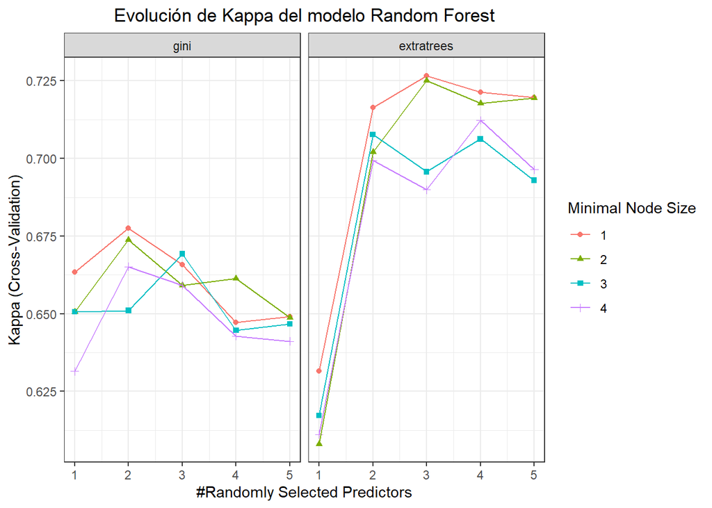

```r
# Gráfico
ggplot(modelo_forest) +
  labs(title = "Evolución de Kappa del modelo Random Forest") +
  theme_bw() +
  theme(plot.title = element_text(hjust = 0.5))
```

```r
# Predicciones
p <- predict(modelo_forest, newdata = dataset.test)


# Evaluación
(mconfusion_forest <- confusionMatrix(data = p, reference = dataset.test$Clasificación, mode="everything", positive="NF"))
```

```
## Confusion Matrix and Statistics
##
##           Reference
## Prediction  AF FF/FL  NF
##      AF     31     2   6
##      FF/FL   1    28   8
##      NF     10    18 125
##
## Overall Statistics
##
##                Accuracy : 0.8035
##                  95% CI : (0.746, 0.8529)
##     No Information Rate : 0.607
##     P-Value [Acc > NIR] : 1.432e-10
##
##                   Kappa : 0.6288
##
##  Mcnemar's Test P-Value : 0.1591
##
## Statistics by Class:
##
##                      Class: AF Class: FF/FL Class: NF
## Sensitivity             0.7381       0.5833    0.8993
## Specificity             0.9572       0.9503    0.6889
## Pos Pred Value          0.7949       0.7568    0.8170
## Neg Pred Value          0.9421       0.8958    0.8158
## Precision               0.7949       0.7568    0.8170
## Recall                  0.7381       0.5833    0.8993
## F1                      0.7654       0.6588    0.8562
## Prevalence              0.1834       0.2096    0.6070
## Detection Rate          0.1354       0.1223    0.5459
## Detection Prevalence    0.1703       0.1616    0.6681
## Balanced Accuracy       0.8477       0.7668    0.7941
```

```r
resultados_RF <- data.frame(
  Modelo              = "Random Forest",
  Precisión           = round((ifelse(is.na(mconfusion_forest$byClass[1,5]), 0, mconfusion_forest$byClass[1,5]) +
                              ifelse(is.na(mconfusion_forest$byClass[2,5]), 0, mconfusion_forest$byClass[2,5]) +
                              ifelse(is.na(mconfusion_forest$byClass[3,5]), 0, mconfusion_forest$byClass[3,5]) ) / 3, 3),
  Sensibilidad        = round((ifelse(is.na(mconfusion_forest$byClass[1,1]), 0, mconfusion_forest$byClass[1,1]) +
                              ifelse(is.na(mconfusion_forest$byClass[2,1]), 0, mconfusion_forest$byClass[2,1]) +
                              ifelse(is.na(mconfusion_forest$byClass[3,1]), 0, mconfusion_forest$byClass[3,1]) ) / 3, 3),
  Especificidad       = round((ifelse(is.na(mconfusion_forest$byClass[1,2]), 0, mconfusion_forest$byClass[1,2]) +
                              ifelse(is.na(mconfusion_forest$byClass[2,2]), 0, mconfusion_forest$byClass[2,2]) +
                              ifelse(is.na(mconfusion_forest$byClass[3,2]), 0, mconfusion_forest$byClass[3,2]) ) / 3, 3),
  kappa               = round(mconfusion_forest[["overall"]][["Kappa"]], 3),
  F1                  = round((ifelse(is.na(mconfusion_forest$byClass[1,7]), 0, mconfusion_forest$byClass[1,7]) +
                              ifelse(is.na(mconfusion_forest$byClass[2,7]), 0, mconfusion_forest$byClass[2,7]) +
                              ifelse(is.na(mconfusion_forest$byClass[3,7]), 0, mconfusion_forest$byClass[3,7]) ) / 3, 3),
  Error_clasificación = round((1 - mconfusion_forest[["overall"]][["Accuracy"]]) * 100, 3),
  Accuracy            = round(mconfusion_forest[["overall"]][["Accuracy"]], 3)
)

resultados_RF
```

```
##          Modelo Precisión Sensibilidad Especificidad kappa   F1
## 1 Random Forest      0.79         0.74         0.865 0.629 0.76
##   Error_clasificación Accuracy
## 1              19.651    0.803
```

### 4.5.8 Boosting

```r
hiperparametros= expand.grid(interaction.depth = c( 3, 5, 10, 20,35, 30),
                        n.trees = (1:30)*50,
                        shrinkage = 0.1,
                        n.minobsinnode = c(10,20))
# Ajuste del modelo
set.seed(29)
modelo_boosting <- train(Clasificación ~ ., data = dataset.train_SMOTE,
                   method = "gbm",
                   tuneGrid = hiperparametros,
                   metric = "Kappa",
                   trControl = fitControl
                   )
modelo_boosting
```

```
## Stochastic Gradient Boosting
##
## 751 samples
##   7 predictor
##   3 classes: 'AF', 'FF/FL', 'NF'
##
## No pre-processing
## Resampling: Cross-Validated (10 fold)
## Summary of sample sizes: 675, 676, 676, 675, 676, 676, ...
## Resampling results across tuning parameters:
##
##   interaction.depth  n.minobsinnode  n.trees  Accuracy   Kappa      Mean_F1
##    3                 10                50     0.7295737  0.5830894  0.7357441
##    3                 10               100     0.7508739  0.6166869  0.7583587
##    3                 10               150     0.7508378  0.6162861  0.7586725
##    3                 10               200     0.7467847  0.6098431  0.7542201
##    3                 10               250     0.7521731  0.6184833  0.7590305
##    3                 10               300     0.7468568  0.6114194  0.7552229
##    3                 10               350     0.7548222  0.6236014  0.7621833
##    3                 10               400     0.7535244  0.6212390  0.7608911
##    3                 10               450     0.7574723  0.6275176  0.7648567
##    3                 10               500     0.7561916  0.6250499  0.7627935
##    3                 10               550     0.7549474  0.6224353  0.7615050
##    3                 10               600     0.7535609  0.6205766  0.7606788
##    3                 10               650     0.7575600  0.6267878  0.7649923
##    3                 10               700     0.7588762  0.6291324  0.7659939
##    3                 10               750     0.7561916  0.6250355  0.7633534
##    3                 10               800     0.7561911  0.6243917  0.7631774
##    3                 10               850     0.7561560  0.6249294  0.7634349
##    3                 10               900     0.7575064  0.6271438  0.7651700
##    3                 10               950     0.7601204  0.6312213  0.7669752
##    3                 10              1000     0.7587866  0.6290803  0.7662096
##    3                 10              1050     0.7574358  0.6269635  0.7645257
##    3                 10              1100     0.7481901  0.6126111  0.7557580
##    3                 10              1150     0.7534879  0.6212334  0.7614233
##    3                 10              1200     0.7574704  0.6273504  0.7649018
##    3                 10              1250     0.7521726  0.6193630  0.7602103
##    3                 10              1300     0.7548217  0.6234536  0.7628732
##    3                 10              1350     0.7561901  0.6256960  0.7646720
##    3                 10              1400     0.7534348  0.6214138  0.7608193
```

[output cut: 1044 more lines]

```
##   0.7763382       0.7773682    0.2556373            0.8272578
##   0.7761235       0.7767026    0.2551870            0.8266418
##   0.7705276       0.7722889    0.2538416            0.8232852
##   0.7718445       0.7746528    0.2547482            0.8252111
##   0.7718657       0.7754364    0.2547305            0.8257280
##   0.7657436       0.7683803    0.2525143            0.8203353
##   0.7647250       0.7673702    0.2520816            0.8195155
##   0.7646022       0.7682801    0.2520695            0.8201107
##   0.7691632       0.7717152    0.2533912            0.8227362
##   0.7695571       0.7710684    0.2534029            0.8223728
##
## Tuning parameter 'shrinkage' was held constant at a value of 0.1
## Kappa was used to select the optimal model using the largest value.
## The final values used for the model were n.trees = 800, interaction.depth =
##  10, shrinkage = 0.1 and n.minobsinnode = 10.
```

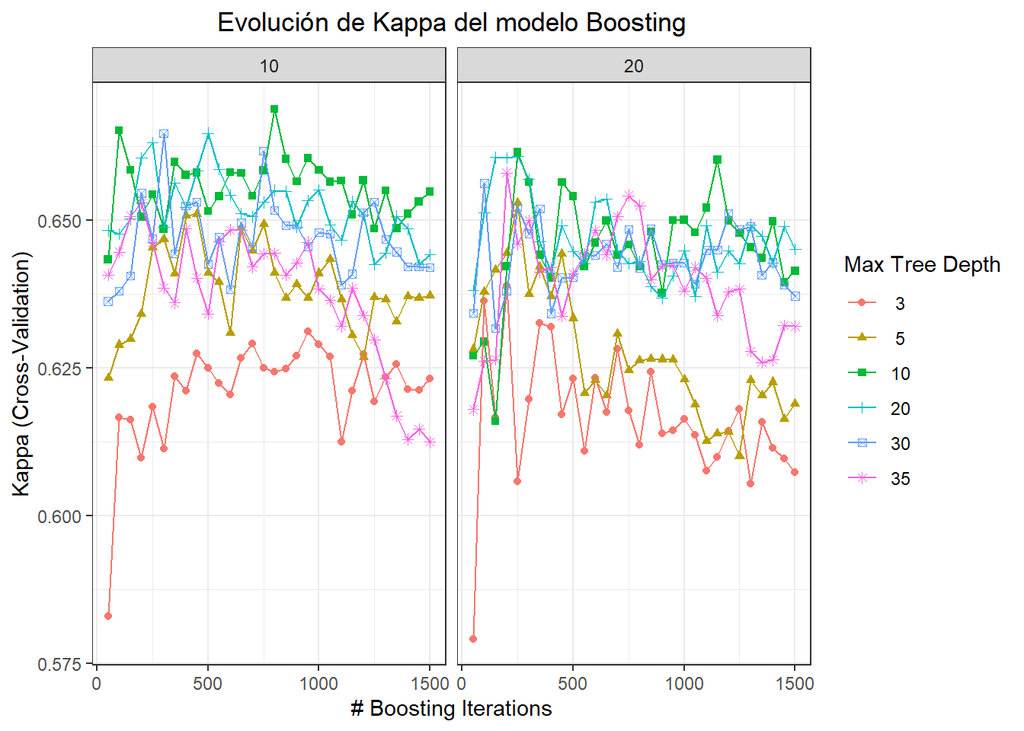

```r
# Gráfico
ggplot(modelo_boosting) +
  labs(title = "Evolución de Kappa del modelo Boosting") +
  theme_bw() +
  theme(plot.title = element_text(hjust = 0.5))
```

```r
# Predicciones
p <- predict(modelo_boosting, newdata = dataset.test)


# Evaluación
(mconfusion_boosting <- confusionMatrix(data = p, reference = dataset.test$Clasificación, mode="everything", positive="NF"))
```

```
## Confusion Matrix and Statistics
##
##           Reference
## Prediction  AF FF/FL  NF
##      AF     26     3   5
##      FF/FL   0    23  18
##      NF     16    22 116
##
## Overall Statistics
##
##                Accuracy : 0.7205
##                  95% CI : (0.6576, 0.7776)
##     No Information Rate : 0.607
##     P-Value [Acc > NIR] : 0.0002152
##
##                   Kappa : 0.4697
##
##  Mcnemar's Test P-Value : 0.0272140
##
## Statistics by Class:
##
##                      Class: AF Class: FF/FL Class: NF
## Sensitivity             0.6190       0.4792    0.8345
## Specificity             0.9572       0.9006    0.5778
## Pos Pred Value          0.7647       0.5610    0.7532
## Neg Pred Value          0.9179       0.8670    0.6933
## Precision               0.7647       0.5610    0.7532
## Recall                  0.6190       0.4792    0.8345
## F1                      0.6842       0.5169    0.7918
## Prevalence              0.1834       0.2096    0.6070
## Detection Rate          0.1135       0.1004    0.5066
## Detection Prevalence    0.1485       0.1790    0.6725
## Balanced Accuracy       0.7881       0.6899    0.7062
```

```r
resultados_boosting <- data.frame(
  Modelo              = "Boosting",
  Precisión           = round((ifelse(is.na(mconfusion_boosting$byClass[1,5]), 0, mconfusion_boosting$byClass[1,5]) +
                              ifelse(is.na(mconfusion_boosting$byClass[2,5]), 0, mconfusion_boosting$byClass[2,5]) +
                              ifelse(is.na(mconfusion_boosting$byClass[3,5]), 0, mconfusion_boosting$byClass[3,5])  ) / 3, 3),
  Sensibilidad        = round((ifelse(is.na(mconfusion_boosting$byClass[1,1]), 0, mconfusion_boosting$byClass[1,1]) +
                              ifelse(is.na(mconfusion_boosting$byClass[2,1]), 0, mconfusion_boosting$byClass[2,1]) +
                              ifelse(is.na(mconfusion_boosting$byClass[3,1]), 0, mconfusion_boosting$byClass[3,1])  ) /3, 3),
  Especificidad       = round((ifelse(is.na(mconfusion_boosting$byClass[1,2]), 0, mconfusion_boosting$byClass[1,2]) +
                              ifelse(is.na(mconfusion_boosting$byClass[2,2]), 0, mconfusion_boosting$byClass[2,2]) +
                              ifelse(is.na(mconfusion_boosting$byClass[3,2]), 0, mconfusion_boosting$byClass[3,2]) ) / 3, 3),
  kappa               = round(mconfusion_boosting[["overall"]][["Kappa"]], 3),
  F1                  = round((ifelse(is.na(mconfusion_boosting$byClass[1,7]), 0, mconfusion_boosting$byClass[1,7]) +
                              ifelse(is.na(mconfusion_boosting$byClass[2,7]), 0, mconfusion_boosting$byClass[2,7]) +
                              ifelse(is.na(mconfusion_boosting$byClass[3,7]), 0, mconfusion_boosting$byClass[3,7])  ) / 3, 3),
  Error_clasificación = round((1 - mconfusion_boosting[["overall"]][["Accuracy"]]) * 100, 3),
  Accuracy            = round(mconfusion_boosting[["overall"]][["Accuracy"]], 3)
)

resultados_boosting
```

```
##     Modelo Precisión Sensibilidad Especificidad kappa    F1 Error_clasificación
## 1 Boosting     0.693        0.644         0.812  0.47 0.664              27.948
##   Accuracy
## 1    0.721
```

### 4.5.9 Bagging

```r
# Hiperparámetros
hiperparametros= expand.grid(mtry = c(1, 4, 5, 6, 9))

# Ajuste del modelo
set.seed(29)
(modelo_Bagging <- train(Clasificación ~ ., data = dataset.train_SMOTE,
                   method = "parRF",
                   tuneGrid = hiperparametros,
                   metric = "Kappa",
                    trControl = fitControl
                   ))
```

```
## Parallel Random Forest
##
## 751 samples
##   7 predictor
##   3 classes: 'AF', 'FF/FL', 'NF'
##
## No pre-processing
## Resampling: Cross-Validated (10 fold)
## Summary of sample sizes: 675, 676, 676, 675, 676, 676, ...
## Resampling results across tuning parameters:
##
##   mtry  Accuracy   Kappa      Mean_F1    Mean_Sensitivity  Mean_Specificity
##   1     0.7829137  0.6629501  0.7856872  0.7830348         0.8828763
##   4     0.7762807  0.6572687  0.7821493  0.7859050         0.8832340
##   5     0.7709113  0.6491475  0.7767745  0.7808572         0.8804180
##   6     0.7696847  0.6472315  0.7758893  0.7789142         0.8798127
##   9     0.7748582  0.6551322  0.7806947  0.7847097         0.8824716
##   Mean_Pos_Pred_Value  Mean_Neg_Pred_Value  Mean_Precision  Mean_Recall
##   0.8003354            0.8885587            0.8003354       0.7830348
##   0.7869570            0.8843887            0.7869570       0.7859050
##   0.7800279            0.8815775            0.7800279       0.7808572
##   0.7793139            0.8806548            0.7793139       0.7789142
##   0.7827125            0.8831593            0.7827125       0.7847097
##   Mean_Detection_Rate  Mean_Balanced_Accuracy
##   0.2609712            0.8329555
##   0.2587602            0.8345695
##   0.2569704            0.8306376
##   0.2565616            0.8293635
##   0.2582861            0.8335907
##
## Kappa was used to select the optimal model using the largest value.
## The final value used for the model was mtry = 1.
```

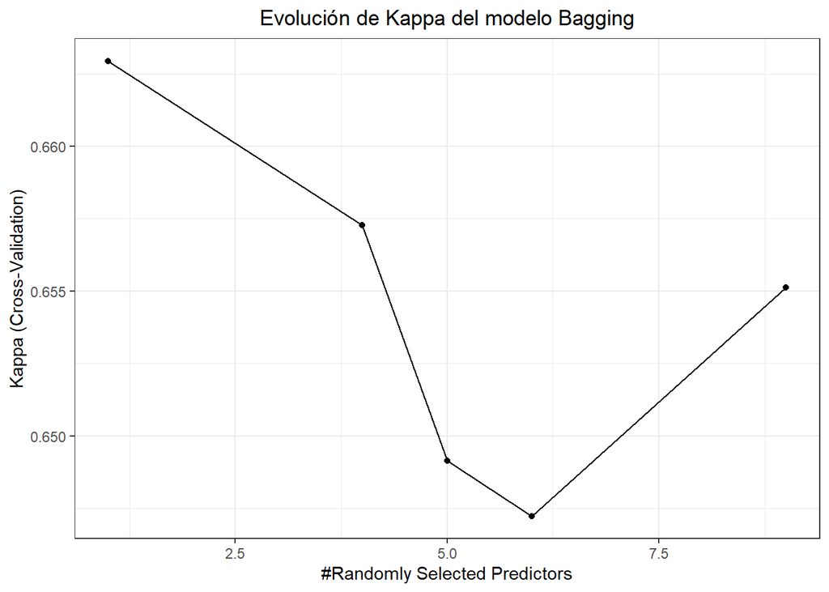

```r
# Gráfico
ggplot(modelo_Bagging) +
  labs(title = "Evolución de Kappa del modelo Bagging") +
  theme_bw() +
  theme(plot.title = element_text(hjust = 0.5))
```

```r
# Predicciones
p <- predict(modelo_Bagging, newdata = dataset.test)


# Evaluación
(mconfusion_Bagging <- confusionMatrix(data = p, reference = dataset.test$Clasificación, mode="everything", positive="NF"))
```

```
## Confusion Matrix and Statistics
##
##           Reference
## Prediction  AF FF/FL  NF
##      AF     27     1   6
##      FF/FL   1    28   7
##      NF     14    19 126
##
## Overall Statistics
##
##                Accuracy : 0.7904
##                  95% CI : (0.7319, 0.8412)
##     No Information Rate : 0.607
##     P-Value [Acc > NIR] : 2.414e-09
##
##                   Kappa : 0.5956
##
##  Mcnemar's Test P-Value : 0.03298
##
## Statistics by Class:
##
##                      Class: AF Class: FF/FL Class: NF
## Sensitivity             0.6429       0.5833    0.9065
## Specificity             0.9626       0.9558    0.6333
## Pos Pred Value          0.7941       0.7778    0.7925
## Neg Pred Value          0.9231       0.8964    0.8143
## Precision               0.7941       0.7778    0.7925
## Recall                  0.6429       0.5833    0.9065
## F1                      0.7105       0.6667    0.8456
## Prevalence              0.1834       0.2096    0.6070
## Detection Rate          0.1179       0.1223    0.5502
## Detection Prevalence    0.1485       0.1572    0.6943
## Balanced Accuracy       0.8027       0.7696    0.7699
```

```r
resultados_bagging <- data.frame(
  Modelo              = "Bagging",
  Precisión           = round((ifelse(is.na(mconfusion_Bagging$byClass[1,5]), 0, mconfusion_Bagging$byClass[1,5]) +
                              ifelse(is.na(mconfusion_Bagging$byClass[2,5]), 0, mconfusion_Bagging$byClass[2,5]) +
                              ifelse(is.na(mconfusion_Bagging$byClass[3,5]), 0, mconfusion_Bagging$byClass[3,5])  ) / 3, 3),
  Sensibilidad        = round((ifelse(is.na(mconfusion_Bagging$byClass[1,1]), 0, mconfusion_Bagging$byClass[1,1]) +
                              ifelse(is.na(mconfusion_Bagging$byClass[2,1]), 0, mconfusion_Bagging$byClass[2,1]) +
                              ifelse(is.na(mconfusion_Bagging$byClass[3,1]), 0, mconfusion_Bagging$byClass[3,1])  ) /3, 3),
  Especificidad       = round((ifelse(is.na(mconfusion_Bagging$byClass[1,2]), 0, mconfusion_Bagging$byClass[1,2]) +
                              ifelse(is.na(mconfusion_Bagging$byClass[2,2]), 0, mconfusion_Bagging$byClass[2,2]) +
                              ifelse(is.na(mconfusion_Bagging$byClass[3,2]), 0, mconfusion_Bagging$byClass[3,2])  ) / 3, 3),
  kappa               = round(mconfusion_Bagging[["overall"]][["Kappa"]], 3),
  F1                  = round((ifelse(is.na(mconfusion_Bagging$byClass[1,7]), 0, mconfusion_Bagging$byClass[1,7]) +
                              ifelse(is.na(mconfusion_Bagging$byClass[2,7]), 0, mconfusion_Bagging$byClass[2,7]) +
                              ifelse(is.na(mconfusion_Bagging$byClass[3,7]), 0, mconfusion_Bagging$byClass[3,7])  ) / 3, 3),
  Error_clasificación = round((1 - mconfusion_Bagging[["overall"]][["Accuracy"]]) * 100, 3),
  Accuracy            = round(mconfusion_Bagging[["overall"]][["Accuracy"]], 3)
)

resultados_bagging
```

```
##    Modelo Precisión Sensibilidad Especificidad kappa    F1 Error_clasificación
## 1 Bagging     0.788        0.711         0.851 0.596 0.741              20.961
##   Accuracy
## 1     0.79
```

### 4.5.10 Tabla resumen del rendimiento de los distintos modelos equilibrados con Tuning grids

```r
tabla_resumen_equilibrado_10fcv = rbind(resultados_knn,
                     resultados_NaiveBayes,
                     resultados_ann,
                     resultados_SVM_radial,
                     resultados_svmlineal,
                     resultados_SVM_poly,
                     resultados_arbol,
                     resultados_RF,
                     resultados_boosting,
                     resultados_bagging
                     )

#Establecemos el orden por valores de Sensibilidad
orden = order(tabla_resumen_equilibrado_10fcv$Sensibilidad, decreasing = TRUE)
tabla_resumen_equilibrado_ordenada_10fcv <- tabla_resumen_equilibrado_10fcv[orden, ]

kable(tabla_resumen_equilibrado_ordenada_10fcv, digits = 3, caption = "Rendimiento de los modelos")
```

Rendimiento de los modelos

|  | Modelo | Precisión | Sensibilidad | Especificidad | kappa | F1 | Error_clasificación | Accuracy |
| --- | --- | --- | --- | --- | --- | --- | --- | --- |
| 8 | Random Forest | 0.790 | 0.740 | 0.865 | 0.629 | 0.760 | 19.651 | 0.803 |
| 10 | Bagging | 0.788 | 0.711 | 0.851 | 0.596 | 0.741 | 20.961 | 0.790 |
| 1 | KNN | 0.707 | 0.708 | 0.844 | 0.543 | 0.707 | 25.328 | 0.747 |
| 7 | Árbol | 0.761 | 0.698 | 0.841 | 0.565 | 0.722 | 22.707 | 0.773 |
| 6 | SVM-poly | 0.651 | 0.680 | 0.831 | 0.487 | 0.663 | 29.258 | 0.707 |
| 3 | ANN | 0.687 | 0.649 | 0.810 | 0.462 | 0.665 | 28.821 | 0.712 |
| 5 | SVM lineal | 0.707 | 0.648 | 0.808 | 0.472 | 0.668 | 27.511 | 0.725 |
| 9 | Boosting | 0.693 | 0.644 | 0.812 | 0.470 | 0.664 | 27.948 | 0.721 |
| 2 | Naive Bayes | 0.586 | 0.623 | 0.779 | 0.335 | 0.585 | 41.485 | 0.585 |
| 4 | SVM-Radial | 0.668 | 0.610 | 0.797 | 0.424 | 0.632 | 30.131 | 0.699 |

## 4.6 Utilizando tuning grids alternativos con los datos Desequilibrados

### 4.6.1 k-Nearest Neighbour

```r
# Hiperparámetros
hiperparametros <- data.frame(k = c(1,5,9,10,15:20))


# modelo
set.seed(29)
modelo_knn <- train(Clasificación ~ ., data = dataset.train,
                    method = "knn",
                    tuneGrid = hiperparametros,
                    metric = "Kappa",
                    trControl = fitControl)

modelo_knn
```

```
## k-Nearest Neighbors
##
## 538 samples
##   7 predictor
##   3 classes: 'AF', 'FF/FL', 'NF'
##
## No pre-processing
## Resampling: Cross-Validated (10 fold)
## Summary of sample sizes: 485, 484, 484, 485, 483, 484, ...
## Resampling results across tuning parameters:
##
##   k   Accuracy   Kappa      Mean_F1    Mean_Sensitivity  Mean_Specificity
##    1  0.6676577  0.4034249  0.6263598  0.6282723         0.7951200
##    5  0.6806245  0.3902843  0.6045091  0.6018476         0.7858200
##    9  0.7080643  0.4203759  0.6123226  0.6025084         0.7906698
##   10  0.7081666  0.4163580  0.6076874  0.6015488         0.7891724
##   15  0.7193825  0.4241493  0.6078913  0.5948043         0.7883066
##   16  0.7044991  0.3959095  0.5916055  0.5822854         0.7805337
##   17  0.7175656  0.4161807  0.6008074  0.5921128         0.7859432
##   18  0.7138269  0.4096589  0.5957263  0.5848548         0.7844465
##   19  0.7194524  0.4201745  0.6015035  0.5954461         0.7876036
##   20  0.7101569  0.4011683  0.5920125  0.5807639         0.7814734
##   Mean_Pos_Pred_Value  Mean_Neg_Pred_Value  Mean_Precision  Mean_Recall
##   0.6392442            0.7953343            0.6392442       0.6282723
##   0.6334858            0.7999391            0.6334858       0.6018476
##   0.6782690            0.8286341            0.6782690       0.6025084
##   0.6706555            0.8260961            0.6706555       0.6015488
##   0.7449072            0.8531965            0.7449072       0.5948043
##   0.7017125            0.8353096            0.7017125       0.5822854
##   0.7481873            0.8514795            0.7481873       0.5921128
##   0.7427488            0.8480760            0.7427488       0.5848548
##   0.7682146            0.8510199            0.7682146       0.5954461
##   0.7453131            0.8443884            0.7453131       0.5807639
##   Mean_Detection_Rate  Mean_Balanced_Accuracy
##   0.2225526            0.7116962
##   0.2268748            0.6938338
##   0.2360214            0.6965891
##   0.2360555            0.6953606
##   0.2397942            0.6915554
##   0.2348330            0.6814095
##   0.2391885            0.6890280
##   0.2379423            0.6846507
##   0.2398175            0.6915249
##   0.2367190            0.6811187
##
## Kappa was used to select the optimal model using the largest value.
## The final value used for the model was k = 15.
```

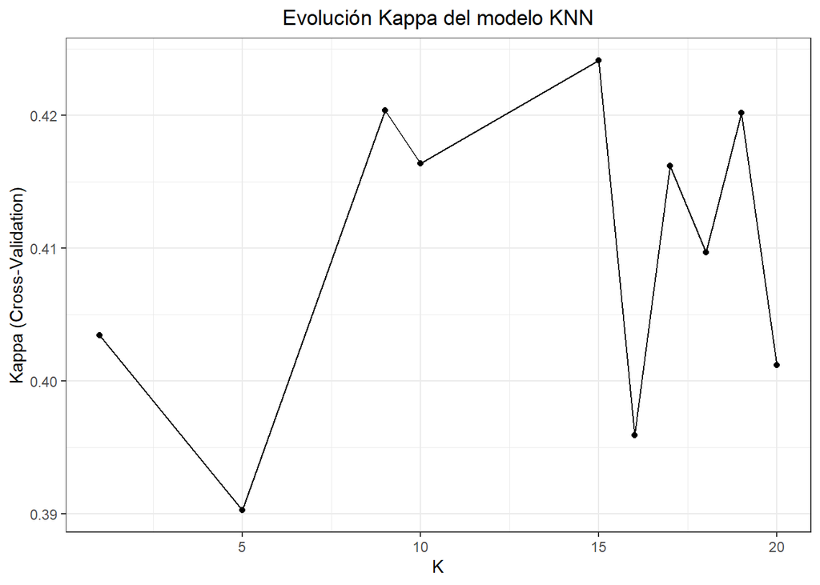

```r
# Gráfica de la evolución de k
ggplot(modelo_knn) +
  labs(title = "Evolución Kappa del modelo KNN", x = "K") +
  theme_bw () +
  theme(plot.title = element_text(hjust = 0.5))
```

```r
# Predicciones
p <- predict(modelo_knn, newdata = dataset.test[,-(ncol(dataset.test))])

# Evaluación
(mconfusion_knn <- confusionMatrix(p, dataset.test$Clasificación, mode="everything", positive="AF"))
```

```
## Confusion Matrix and Statistics
##
##           Reference
## Prediction  AF FF/FL  NF
##      AF     26     2   6
##      FF/FL   1    12   2
##      NF     15    34 131
##
## Overall Statistics
##
##                Accuracy : 0.738
##                  95% CI : (0.676, 0.7937)
##     No Information Rate : 0.607
##     P-Value [Acc > NIR] : 2.133e-05
##
##                   Kappa : 0.4563
##
##  Mcnemar's Test P-Value : 3.845e-07
##
## Statistics by Class:
##
##                      Class: AF Class: FF/FL Class: NF
## Sensitivity             0.6190       0.2500    0.9424
## Specificity             0.9572       0.9834    0.4556
## Pos Pred Value          0.7647       0.8000    0.7278
## Neg Pred Value          0.9179       0.8318    0.8367
## Precision               0.7647       0.8000    0.7278
## Recall                  0.6190       0.2500    0.9424
## F1                      0.6842       0.3810    0.8213
## Prevalence              0.1834       0.2096    0.6070
## Detection Rate          0.1135       0.0524    0.5721
## Detection Prevalence    0.1485       0.0655    0.7860
## Balanced Accuracy       0.7881       0.6167    0.6990
```

```r
resultados_knn <- data.frame(
  Modelo        = "KNN",
  Precisión     = round((ifelse(is.na(mconfusion_knn$byClass[1,5]), 0, mconfusion_knn$byClass[1,5]) +
                         ifelse(is.na(mconfusion_knn$byClass[2,5]), 0, mconfusion_knn$byClass[2,5]) +
                         ifelse(is.na(mconfusion_knn$byClass[3,5]), 0, mconfusion_knn$byClass[3,5])) / 3, 3),
  Sensibilidad  = round((ifelse(is.na(mconfusion_knn$byClass[1,1]), 0, mconfusion_knn$byClass[1,1]) +
                         ifelse(is.na(mconfusion_knn$byClass[2,1]), 0, mconfusion_knn$byClass[2,1]) +
                         ifelse(is.na(mconfusion_knn$byClass[3,1]), 0, mconfusion_knn$byClass[3,1])) / 3, 3),
  Especificidad = round((ifelse(is.na(mconfusion_knn$byClass[1,2]), 0, mconfusion_knn$byClass[1,2]) +
                         ifelse(is.na(mconfusion_knn$byClass[2,2]), 0, mconfusion_knn$byClass[2,2]) +
                         ifelse(is.na(mconfusion_knn$byClass[3,2]), 0, mconfusion_knn$byClass[3,2])) / 3, 3),
  kappa         = round(mconfusion_knn[["overall"]][["Kappa"]], 3),
  F1            = round((ifelse(is.na(mconfusion_knn$byClass[1,7]), 0, mconfusion_knn$byClass[1,7]) +
                         ifelse(is.na(mconfusion_knn$byClass[2,7]), 0, mconfusion_knn$byClass[2,7]) +
                         ifelse(is.na(mconfusion_knn$byClass[3,7]), 0, mconfusion_knn$byClass[3,7])) / 3, 3),
  Error_clasificación = round((1 - mconfusion_knn[["overall"]][["Accuracy"]]) * 100, 3),
  Accuracy      = round(mconfusion_knn[["overall"]][["Accuracy"]], 3)
)

resultados_knn
```

```
##   Modelo Precisión Sensibilidad Especificidad kappa    F1 Error_clasificación
## 1    KNN     0.764        0.604         0.799 0.456 0.629              26.201
##   Accuracy
## 1    0.738
```

### 4.6.2 Naive Bayes

```r
# Hiperparámetros
hiperparametros <- expand.grid(usekernel = c(TRUE, FALSE),
                               fL = c(0:4),
                               adjust = c(1:4))

# Ajuste del modelo
set.seed(29)
(modelo_bayes = train(Clasificación ~ ., data = dataset.train,
                   method = "nb",
                   tuneGrid = hiperparametros,
                   metric = "Kappa",
                    trControl = fitControl))
```

```
## Naive Bayes
##
## 538 samples
##   7 predictor
##   3 classes: 'AF', 'FF/FL', 'NF'
##
## No pre-processing
## Resampling: Cross-Validated (10 fold)
## Summary of sample sizes: 485, 484, 484, 485, 483, 484, ...
## Resampling results across tuning parameters:
##
##   usekernel  fL  adjust  Accuracy   Kappa      Mean_F1    Mean_Sensitivity
##   FALSE      0   1       0.5930195  0.2989349  0.5708871  0.5673548
##   FALSE      0   2       0.5930195  0.2989349  0.5708871  0.5673548
##   FALSE      0   3       0.5930195  0.2989349  0.5708871  0.5673548
##   FALSE      0   4       0.5930195  0.2989349  0.5708871  0.5673548
##   FALSE      1   1       0.5930195  0.2989349  0.5708871  0.5673548
##   FALSE      1   2       0.5930195  0.2989349  0.5708871  0.5673548
##   FALSE      1   3       0.5930195  0.2989349  0.5708871  0.5673548
##   FALSE      1   4       0.5930195  0.2989349  0.5708871  0.5673548
##   FALSE      2   1       0.5930195  0.2989349  0.5708871  0.5673548
##   FALSE      2   2       0.5930195  0.2989349  0.5708871  0.5673548
##   FALSE      2   3       0.5930195  0.2989349  0.5708871  0.5673548
##   FALSE      2   4       0.5930195  0.2989349  0.5708871  0.5673548
##   FALSE      3   1       0.5930195  0.2989349  0.5708871  0.5673548
##   FALSE      3   2       0.5930195  0.2989349  0.5708871  0.5673548
##   FALSE      3   3       0.5930195  0.2989349  0.5708871  0.5673548
##   FALSE      3   4       0.5930195  0.2989349  0.5708871  0.5673548
##   FALSE      4   1       0.5930195  0.2989349  0.5708871  0.5673548
##   FALSE      4   2       0.5930195  0.2989349  0.5708871  0.5673548
##   FALSE      4   3       0.5930195  0.2989349  0.5708871  0.5673548
##   FALSE      4   4       0.5930195  0.2989349  0.5708871  0.5673548
##    TRUE      0   1       0.6711556  0.3538452  0.5791203  0.5648422
##    TRUE      0   2       0.6768185  0.3391473  0.5663637  0.5474179
##    TRUE      0   3       0.6600121  0.2776508  0.5220049  0.5025652
##    TRUE      0   4       0.6339451  0.1680666  0.4648435  0.4327883
##    TRUE      1   1       0.6711556  0.3538452  0.5791203  0.5648422
##    TRUE      1   2       0.6768185  0.3391473  0.5663637  0.5474179
##    TRUE      1   3       0.6600121  0.2776508  0.5220049  0.5025652
##    TRUE      1   4       0.6339451  0.1680666  0.4648435  0.4327883
```

[output cut: 83 more lines]

```
##   0.5474179    0.2256062            0.6549508
##   0.5025652    0.2200040            0.6226390
##   0.4327883    0.2113150            0.5709929
##   0.5648422    0.2237185            0.6675652
##   0.5474179    0.2256062            0.6549508
##   0.5025652    0.2200040            0.6226390
##   0.4327883    0.2113150            0.5709929
##   0.5648422    0.2237185            0.6675652
##   0.5474179    0.2256062            0.6549508
##   0.5025652    0.2200040            0.6226390
##   0.4327883    0.2113150            0.5709929
##
## Kappa was used to select the optimal model using the largest value.
## The final values used for the model were fL = 0, usekernel = TRUE and adjust
##  = 1.
```

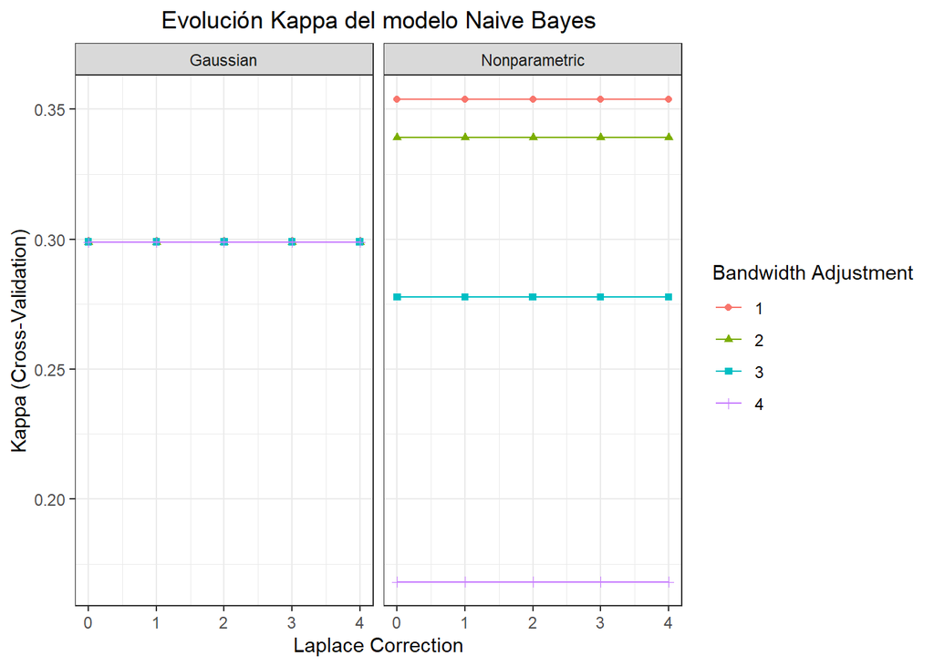

```r
# Gráfica
ggplot(modelo_bayes) +
  labs(title = "Evolución Kappa del modelo Naive Bayes") +
  theme_bw() +
  theme(plot.title = element_text(hjust = 0.5))
```

```r
# Predicciones
p <- predict(modelo_bayes, dataset.test[1:(ncol(dataset.test)-1)])

# Evaluación
(mconfusion_Bayes <- confusionMatrix(p, dataset.test$Clasificación, mode="everything", positive="AF"))
```

```
## Confusion Matrix and Statistics
##
##           Reference
## Prediction  AF FF/FL  NF
##      AF     24     0  10
##      FF/FL   1    17   8
##      NF     17    31 121
##
## Overall Statistics
##
##                Accuracy : 0.7074
##                  95% CI : (0.6439, 0.7655)
##     No Information Rate : 0.607
##     P-Value [Acc > NIR] : 0.0009807
##
##                   Kappa : 0.416
##
##  Mcnemar's Test P-Value : 0.0009481
##
## Statistics by Class:
##
##                      Class: AF Class: FF/FL Class: NF
## Sensitivity             0.5714      0.35417    0.8705
## Specificity             0.9465      0.95028    0.4667
## Pos Pred Value          0.7059      0.65385    0.7160
## Neg Pred Value          0.9077      0.84729    0.7000
## Precision               0.7059      0.65385    0.7160
## Recall                  0.5714      0.35417    0.8705
## F1                      0.6316      0.45946    0.7857
## Prevalence              0.1834      0.20961    0.6070
## Detection Rate          0.1048      0.07424    0.5284
## Detection Prevalence    0.1485      0.11354    0.7380
## Balanced Accuracy       0.7590      0.65222    0.6686
```

```r
resultados_NaiveBayes <- data.frame(
  Modelo        = "Naive Bayes",
  Precisión     = round((ifelse(is.na(mconfusion_Bayes$byClass[1,5]), 0, mconfusion_Bayes$byClass[1,5]) +
                        ifelse(is.na(mconfusion_Bayes$byClass[2,5]), 0, mconfusion_Bayes$byClass[2,5]) +
                        ifelse(is.na(mconfusion_Bayes$byClass[3,5]), 0, mconfusion_Bayes$byClass[3,5])
                        ) / 3, 3),
  Sensibilidad  = round((ifelse(is.na(mconfusion_Bayes$byClass[1,1]), 0, mconfusion_Bayes$byClass[1,1]) +
                        ifelse(is.na(mconfusion_Bayes$byClass[2,1]), 0, mconfusion_Bayes$byClass[2,1]) +
                        ifelse(is.na(mconfusion_Bayes$byClass[3,1]), 0, mconfusion_Bayes$byClass[3,1])
                        ) / 3, 3),
  Especificidad = round((ifelse(is.na(mconfusion_Bayes$byClass[1,2]), 0, mconfusion_Bayes$byClass[1,2]) +
                        ifelse(is.na(mconfusion_Bayes$byClass[2,2]), 0, mconfusion_Bayes$byClass[2,2]) +
                        ifelse(is.na(mconfusion_Bayes$byClass[3,2]), 0, mconfusion_Bayes$byClass[3,2])
                        ) / 3, 3),
  kappa         = round(mconfusion_Bayes[["overall"]][["Kappa"]], 3),
  F1            = round((ifelse(is.na(mconfusion_Bayes$byClass[1,7]), 0, mconfusion_Bayes$byClass[1,7]) +
                        ifelse(is.na(mconfusion_Bayes$byClass[2,7]), 0, mconfusion_Bayes$byClass[2,7]) +
                        ifelse(is.na(mconfusion_Bayes$byClass[3,7]), 0, mconfusion_Bayes$byClass[3,7])
                        ) / 3, 3),
  Error_clasificación = round((1 - mconfusion_Bayes[["overall"]][["Accuracy"]]) * 100, 3),
  Accuracy      = round(mconfusion_Bayes[["overall"]][["Accuracy"]], 3)
)

resultados_NaiveBayes
```

```
##        Modelo Precisión Sensibilidad Especificidad kappa    F1
## 1 Naive Bayes     0.692        0.599         0.788 0.416 0.626
##   Error_clasificación Accuracy
## 1              29.258    0.707
```

### 4.6.4 ANN

```r
#hiperparametros
hiperparametros = expand.grid(size = c(3, 10, 20, 50, 100,150),
                               decay = c(0.0001, 0.00001, 0.01,0.1,1))

#Ajuste del modelo
set.seed(29)

(modelo_ann <- train(Clasificación ~ ., data = dataset.train,
                    method = "nnet",
                    tuneGrid = hiperparametros,
                    metric = "Kappa",
                    trControl = fitControl,
                    MaxNWts = 2000,
                    trace = FALSE))
```

```
## Neural Network
##
## 538 samples
##   7 predictor
##   3 classes: 'AF', 'FF/FL', 'NF'
##
## No pre-processing
## Resampling: Cross-Validated (10 fold)
## Summary of sample sizes: 485, 484, 484, 485, 483, 484, ...
## Resampling results across tuning parameters:
##
##   size  decay  Accuracy   Kappa      Mean_F1    Mean_Sensitivity
##     3   1e-05  0.6896779  0.4027953  0.6158249  0.6056629
##     3   1e-04  0.7179487  0.4525627  0.6373946  0.6341940
##     3   1e-02  0.6863509  0.4010167  0.6102471  0.6055955
##     3   1e-01  0.7179785  0.4632531  0.6396766  0.6384428
##     3   1e+00  0.7158859  0.4193261  0.6159588  0.5934617
##    10   1e-05  0.6843955  0.4293291  0.6340835  0.6359870
##    10   1e-04  0.6670453  0.3842324  0.6073442  0.6000926
##    10   1e-02  0.6898177  0.4150879  0.6212716  0.6187626
##    10   1e-01  0.6953059  0.4231176  0.6240012  0.6236364
##    10   1e+00  0.7326275  0.4585273  0.6232263  0.6205513
##    20   1e-05  0.6470802  0.3684739  0.6005147  0.6043371
##    20   1e-04  0.5840010  0.2972483  0.5594426  0.5745097
##    20   1e-02  0.6527432  0.3713254  0.6013466  0.6029735
##    20   1e-01  0.6696792  0.3865213  0.6329831  0.6056944
##    20   1e+00  0.7400349  0.4750624  0.6316684  0.6289668
##    50   1e-05  0.6433067  0.3677686  0.6040880  0.6099327
##    50   1e-04  0.6566165  0.3811059  0.6156294  0.6164562
##    50   1e-02  0.6395680  0.3676968  0.6047771  0.6134449
##    50   1e-01  0.6935214  0.4306839  0.6557736  0.6333018
##    50   1e+00  0.7345131  0.4663759  0.6276869  0.6259049
##   100   1e-05  0.6546223  0.3897648  0.6170416  0.6226284
##   100   1e-04  0.6730125  0.4142574  0.6327643  0.6379735
##   100   1e-02  0.6436135  0.3547581  0.5990998  0.5969234
##   100   1e-01  0.6805921  0.4044514  0.6240620  0.6181187
##   100   1e+00  0.7363649  0.4690111  0.6294796  0.6269465
##   150   1e-05  0.6546935  0.3930449  0.6182656  0.6312984
##   150   1e-04  0.6490680  0.3775651  0.6112293  0.6169318
##   150   1e-02  0.6619001  0.3945180  0.6238371  0.6252630
```

[output cut: 52 more lines]

```
##   0.6333018    0.2311738            0.7162197
##   0.6259049    0.2448377            0.7147995
##   0.6226284    0.2182074            0.7056874
##   0.6379735    0.2243375            0.7182745
##   0.5969234    0.2145378            0.6861074
##   0.6181187    0.2268640            0.7041104
##   0.6269465    0.2454550            0.7156991
##   0.6312984    0.2182312            0.7115526
##   0.6169318    0.2163560            0.7012895
##   0.6252630    0.2206334            0.7073323
##   0.6460017    0.2318135            0.7248315
##   0.6174579    0.2423453            0.7082043
##
## Kappa was used to select the optimal model using the largest value.
## The final values used for the model were size = 20 and decay = 1.
```

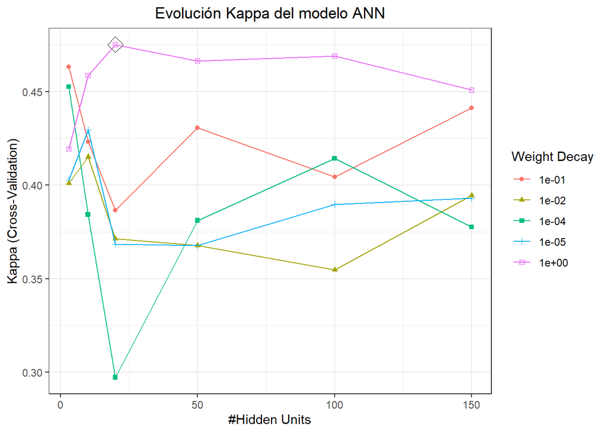

```r
# Gráfica
ggplot(modelo_ann, highlight = TRUE) +
  labs(title = "Evolución Kappa del modelo ANN") +
  theme_bw()+
  theme(plot.title = element_text(hjust = 0.5))
```

```r
# Predicciones
p <- predict(modelo_ann, newdata = dataset.test[1:(ncol(dataset.test)-1)])

# Evaluación
res = table(p, dataset.test$Clasificación)
(mconfusion_ann = confusionMatrix(res, mode="everything", positive="AF"))
```

```
## Confusion Matrix and Statistics
##
##
## p        AF FF/FL  NF
##   AF     26     0   3
##   FF/FL   0    14   6
##   NF     16    34 130
##
## Overall Statistics
##
##                Accuracy : 0.7424
##                  95% CI : (0.6806, 0.7977)
##     No Information Rate : 0.607
##     P-Value [Acc > NIR] : 1.135e-05
##
##                   Kappa : 0.4648
##
##  Mcnemar's Test P-Value : NA
##
## Statistics by Class:
##
##                      Class: AF Class: FF/FL Class: NF
## Sensitivity             0.6190      0.29167    0.9353
## Specificity             0.9840      0.96685    0.4444
## Pos Pred Value          0.8966      0.70000    0.7222
## Neg Pred Value          0.9200      0.83732    0.8163
## Precision               0.8966      0.70000    0.7222
## Recall                  0.6190      0.29167    0.9353
## F1                      0.7324      0.41176    0.8150
## Prevalence              0.1834      0.20961    0.6070
## Detection Rate          0.1135      0.06114    0.5677
## Detection Prevalence    0.1266      0.08734    0.7860
## Balanced Accuracy       0.8015      0.62926    0.6898
```

```r
resultados_ann <- data.frame(
  Modelo        = "ANN",
  Precisión     = round((ifelse(is.na(mconfusion_ann$byClass[1,5]), 0, mconfusion_ann$byClass[1,5]) +
                        ifelse(is.na(mconfusion_ann$byClass[2,5]), 0, mconfusion_ann$byClass[2,5]) +
                        ifelse(is.na(mconfusion_ann$byClass[3,5]), 0, mconfusion_ann$byClass[3,5])
                        ) / 3, 3),
  Sensibilidad  = round((ifelse(is.na(mconfusion_ann$byClass[1,1]), 0, mconfusion_ann$byClass[1,1]) +
                        ifelse(is.na(mconfusion_ann$byClass[2,1]), 0, mconfusion_ann$byClass[2,1]) +
                        ifelse(is.na(mconfusion_ann$byClass[3,1]), 0, mconfusion_ann$byClass[3,1])
                        ) / 3, 3),
  Especificidad = round((ifelse(is.na(mconfusion_ann$byClass[1,2]), 0, mconfusion_ann$byClass[1,2]) +
                        ifelse(is.na(mconfusion_ann$byClass[2,2]), 0, mconfusion_ann$byClass[2,2]) +
                        ifelse(is.na(mconfusion_ann$byClass[3,2]), 0, mconfusion_ann$byClass[3,2])
                        ) / 3, 3),
  kappa         = round(mconfusion_ann[["overall"]][["Kappa"]], 3),
  F1            = round((ifelse(is.na(mconfusion_ann$byClass[1,7]), 0, mconfusion_ann$byClass[1,7]) +
                        ifelse(is.na(mconfusion_ann$byClass[2,7]), 0, mconfusion_ann$byClass[2,7]) +
                        ifelse(is.na(mconfusion_ann$byClass[3,7]), 0, mconfusion_ann$byClass[3,7])
                       ) / 3, 3),
  Error_clasificación = round((1 - mconfusion_ann[["overall"]][["Accuracy"]]) * 100, 3),
  Accuracy      = round(mconfusion_ann[["overall"]][["Accuracy"]], 3)
)

resultados_ann
```

```
##   Modelo Precisión Sensibilidad Especificidad kappa    F1 Error_clasificación
## 1    ANN     0.773        0.615         0.798 0.465 0.653              25.764
##   Accuracy
## 1    0.742
```

### 4.6.5 Support Vector Machine

#### 4.6.5.1 SVM-lineal

```r
# Hiperparámetros
hiperparametros = data.frame(C = c(0.5,1,5,10,20,30,40,50,75,100))

# Ajuste del modelo
set.seed(29)
(modelo_svmlineal = train(Clasificación ~ ., data = dataset.train,
                          method = "svmLinear",
                          tuneGrid = hiperparametros,
                          metric = "Kappa",
                          trControl = fitControl
                          ))
```

```
## Support Vector Machines with Linear Kernel
##
## 538 samples
##   7 predictor
##   3 classes: 'AF', 'FF/FL', 'NF'
##
## No pre-processing
## Resampling: Cross-Validated (10 fold)
## Summary of sample sizes: 485, 484, 484, 485, 483, 484, ...
## Resampling results across tuning parameters:
##
##   C      Accuracy   Kappa      Mean_F1  Mean_Sensitivity  Mean_Specificity
##     0.5  0.6823404  0.3249900  NaN      0.5336279         0.7559685
##     1.0  0.6841586  0.3381761  NaN      0.5438994         0.7599729
##     5.0  0.6878972  0.3411570  NaN      0.5436595         0.7606759
##    10.0  0.6842272  0.3266927  NaN      0.5346696         0.7559140
##    20.0  0.6842272  0.3266927  NaN      0.5346696         0.7559140
##    30.0  0.6898177  0.3398959  NaN      0.5423779         0.7598462
##    40.0  0.6879658  0.3392552  NaN      0.5439983         0.7599183
##    50.0  0.6879658  0.3368867  NaN      0.5413363         0.7590886
##    75.0  0.6879658  0.3346345  NaN      0.5390446         0.7582589
##   100.0  0.6879658  0.3346345  NaN      0.5390446         0.7582589
##   Mean_Pos_Pred_Value  Mean_Neg_Pred_Value  Mean_Precision  Mean_Recall
##   NaN                  0.8274540            NaN             0.5336279
##   NaN                  0.8296283            NaN             0.5438994
##   NaN                  0.8344550            NaN             0.5436595
##   NaN                  0.8317581            NaN             0.5346696
##   NaN                  0.8317581            NaN             0.5346696
##   NaN                  0.8357700            NaN             0.5423779
##   NaN                  0.8333407            NaN             0.5439983
##   NaN                  0.8327221            NaN             0.5413363
##   NaN                  0.8345118            NaN             0.5390446
##   NaN                  0.8345118            NaN             0.5390446
##   Mean_Detection_Rate  Mean_Balanced_Accuracy
##   0.2274468            0.6447982
##   0.2280529            0.6519361
##   0.2292991            0.6521677
##   0.2280757            0.6452918
##   0.2280757            0.6452918
##   0.2299392            0.6511121
##   0.2293219            0.6519583
##   0.2293219            0.6502124
##   0.2293219            0.6486518
##   0.2293219            0.6486518
##
## Kappa was used to select the optimal model using the largest value.
## The final value used for the model was C = 5.
```

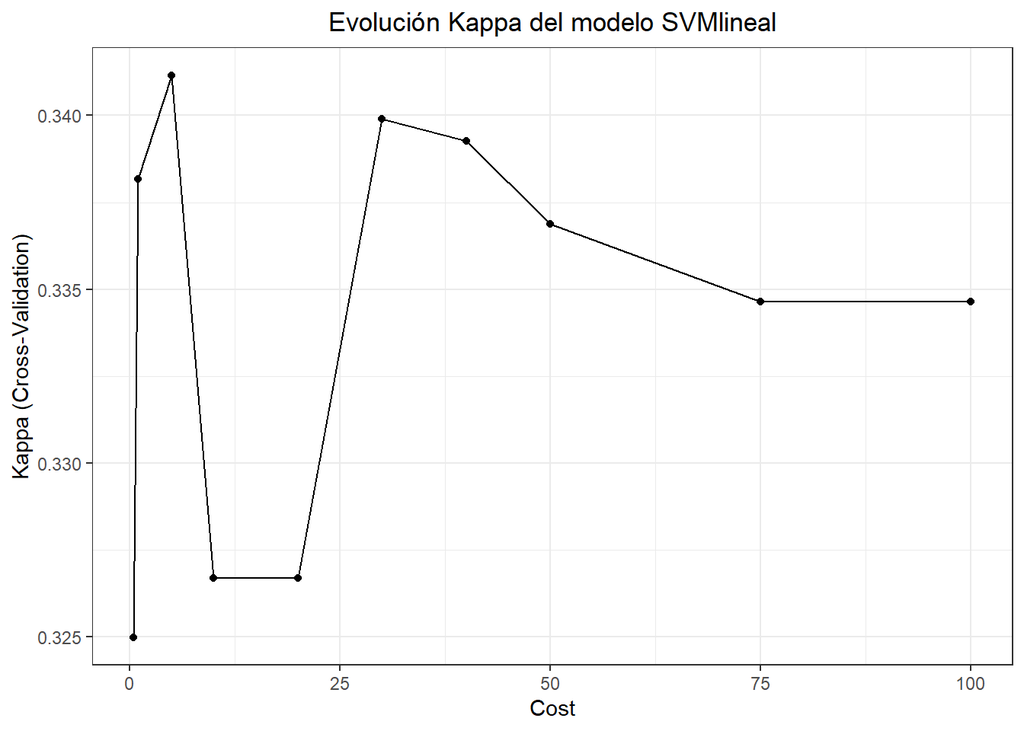

```r
# Gráfico
ggplot(modelo_svmlineal) +
  labs(title = "Evolución Kappa del modelo SVMlineal") +
  theme_bw() +
  theme(plot.title = element_text(hjust = 0.5))
```

```r
# Predicciones
p = predict(modelo_svmlineal, newdata = dataset.test[1:(ncol(dataset.test)-1)])

# Evaluación
(mconfusion_svmlineal = confusionMatrix(p, dataset.test$Clasificación, mode="everything", positive="AF"))
```

```
## Confusion Matrix and Statistics
##
##           Reference
## Prediction  AF FF/FL  NF
##      AF     23     2   8
##      FF/FL   0     0   0
##      NF     19    46 131
##
## Overall Statistics
##
##                Accuracy : 0.6725
##                  95% CI : (0.6076, 0.7329)
##     No Information Rate : 0.607
##     P-Value [Acc > NIR] : 0.02396
##
##                   Kappa : 0.2787
##
##  Mcnemar's Test P-Value : 2.365e-11
##
## Statistics by Class:
##
##                      Class: AF Class: FF/FL Class: NF
## Sensitivity             0.5476       0.0000    0.9424
## Specificity             0.9465       1.0000    0.2778
## Pos Pred Value          0.6970          NaN    0.6684
## Neg Pred Value          0.9031       0.7904    0.7576
## Precision               0.6970           NA    0.6684
## Recall                  0.5476       0.0000    0.9424
## F1                      0.6133           NA    0.7821
## Prevalence              0.1834       0.2096    0.6070
## Detection Rate          0.1004       0.0000    0.5721
## Detection Prevalence    0.1441       0.0000    0.8559
## Balanced Accuracy       0.7471       0.5000    0.6101
```

```r
resultados_svmlineal <- data.frame(
  Modelo              = "SVM lineal",
  Precisión           = round((ifelse(is.na(mconfusion_svmlineal$byClass[1,5]), 0, mconfusion_svmlineal$byClass[1,5]) +
                              ifelse(is.na(mconfusion_svmlineal$byClass[2,5]), 0, mconfusion_svmlineal$byClass[2,5]) +
                              ifelse(is.na(mconfusion_svmlineal$byClass[3,5]), 0, mconfusion_svmlineal$byClass[3,5])) / 3, 3),

  Sensibilidad        = round((ifelse(is.na(mconfusion_svmlineal$byClass[1,1]), 0, mconfusion_svmlineal$byClass[1,1]) +
                              ifelse(is.na(mconfusion_svmlineal$byClass[2,1]), 0, mconfusion_svmlineal$byClass[2,1]) +
                              ifelse(is.na(mconfusion_svmlineal$byClass[3,1]), 0, mconfusion_svmlineal$byClass[3,1])) / 3, 3),

  Especificidad       = round((ifelse(is.na(mconfusion_svmlineal$byClass[1,2]), 0, mconfusion_svmlineal$byClass[1,2]) +
                              ifelse(is.na(mconfusion_svmlineal$byClass[2,2]), 0, mconfusion_svmlineal$byClass[2,2]) +
                              ifelse(is.na(mconfusion_svmlineal$byClass[3,2]), 0, mconfusion_svmlineal$byClass[3,2])) / 3, 3),
  kappa               = round(mconfusion_svmlineal[["overall"]][["Kappa"]], 3),

  F1                  = round((ifelse(is.na(mconfusion_svmlineal$byClass[1,7]), 0, mconfusion_svmlineal$byClass[1,7]) +
                              ifelse(is.na(mconfusion_svmlineal$byClass[2,7]), 0, mconfusion_svmlineal$byClass[2,7]) +
                              ifelse(is.na(mconfusion_svmlineal$byClass[3,7]), 0, mconfusion_svmlineal$byClass[3,7])) / 3, 3),
  Error_clasificación = round((1 - mconfusion_svmlineal[["overall"]][["Accuracy"]]) * 100, 3),
  Accuracy            = round(mconfusion_svmlineal[["overall"]][["Accuracy"]], 3)
)

resultados_svmlineal
```

```
##       Modelo Precisión Sensibilidad Especificidad kappa    F1
## 1 SVM lineal     0.455        0.497         0.741 0.279 0.465
##   Error_clasificación Accuracy
## 1              32.751    0.672
```

#### 4.6.5.2 SVM-RBF o función gaussiana

```r
#Hiperparámetros
hiperparametros = expand.grid(sigma = c(0.05, 0.1, 0.15,0.1958621, 0.2,0.5),
                               C = c(1:3,5,10,15,20))

# Ajuste del modelo
set.seed(29)
(modelo_svmradial = train(Clasificación ~ ., data = dataset.train,
                          method = "svmRadial",
                          tuneGrid = hiperparametros,
                          metric = "Kappa",
                          trControl = fitControl))
```

```
## Support Vector Machines with Radial Basis Function Kernel
##
## 538 samples
##   7 predictor
##   3 classes: 'AF', 'FF/FL', 'NF'
##
## No pre-processing
## Resampling: Cross-Validated (10 fold)
## Summary of sample sizes: 485, 484, 484, 485, 483, 484, ...
## Resampling results across tuning parameters:
##
##   sigma      C   Accuracy   Kappa      Mean_F1    Mean_Sensitivity
##   0.0500000   1  0.7215812  0.4151112  0.5980038  0.5876684
##   0.0500000   2  0.7326936  0.4449273  0.6152714  0.6080219
##   0.0500000   3  0.7289550  0.4412154  0.6122924  0.6082934
##   0.0500000   5  0.7325901  0.4526818  0.6170576  0.6149600
##   0.0500000  10  0.7327972  0.4555250  0.6273065  0.6194213
##   0.0500000  15  0.7327285  0.4623043  0.6373498  0.6248274
##   0.0500000  20  0.7363986  0.4758883  0.6400029  0.6358733
##   0.1000000   1  0.7326936  0.4447489  0.6151189  0.6080535
##   0.1000000   2  0.7307382  0.4468283  0.6154084  0.6116267
##   0.1000000   3  0.7271717  0.4420501  0.6128586  0.6093035
##   0.1000000   5  0.7289562  0.4551880  0.6421478  0.6228114
##   0.1000000  10  0.7251452  0.4587580  0.6366237  0.6277841
##   0.1000000  15  0.7140665  0.4444003  0.6331490  0.6258902
##   0.1000000  20  0.7122495  0.4430650  0.6341981  0.6260922
##   0.1500000   1  0.7325551  0.4483081  0.6157373  0.6106166
##   0.1500000   2  0.7233632  0.4377266  0.6156506  0.6094613
##   0.1500000   3  0.7215450  0.4387206  0.6199380  0.6122075
##   0.1500000   5  0.7252487  0.4551484  0.6358908  0.6257449
##   0.1500000  10  0.7104301  0.4386346  0.6310952  0.6232828
##   0.1500000  15  0.7105336  0.4383713  0.6342191  0.6255366
##   0.1500000  20  0.6993863  0.4213095  0.6270141  0.6185227
##   0.1958621   1  0.7270332  0.4376051  0.6080487  0.6034954
##   0.1958621   2  0.7196233  0.4337605  0.6193686  0.6088742
##   0.1958621   3  0.7215088  0.4410404  0.6244882  0.6132702
##   0.1958621   5  0.7178737  0.4466850  0.6353805  0.6250947
##   0.1958621  10  0.7143060  0.4441860  0.6385589  0.6295770
##   0.1958621  15  0.7049794  0.4353172  0.6264437  0.6245770
##   0.1958621  20  0.7105362  0.4506060  0.6387741  0.6354861
```

[output cut: 88 more lines]

```
##   0.6196338    0.2417379            0.7089231
##   0.6273864    0.2392912            0.7137081
##   0.6272854    0.2381136            0.7129369
##   0.6212437    0.2343871            0.7095734
##   0.6291225    0.2355992            0.7154084
##   0.5743624    0.2348205            0.6750583
##   0.6085290    0.2367984            0.6998874
##   0.6224684    0.2392800            0.7103942
##   0.6105366    0.2331404            0.7014249
##   0.6132071    0.2312532            0.7039871
##   0.6168813    0.2312536            0.7072949
##   0.6088889    0.2281323            0.7005389
##
## Kappa was used to select the optimal model using the largest value.
## The final values used for the model were sigma = 0.05 and C = 20.
```

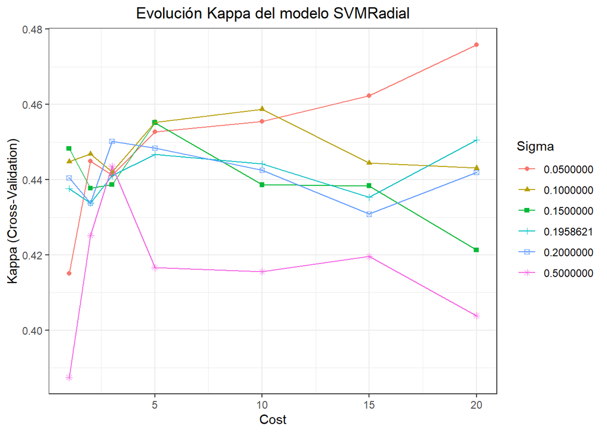

```r
# Gráfico
ggplot(modelo_svmradial) +
  labs(title = "Evolución Kappa del modelo SVMRadial") +
  theme_bw() +
  theme(plot.title = element_text(hjust = 0.5))
```

```r
# Predicciones
p = predict(modelo_svmradial, newdata = dataset.test[1:(ncol(dataset.test)-1)])

# Evaluación
(mconfusion_svmradial = confusionMatrix(p, dataset.test$Clasificación, mode="everything", positive="AF"))
```

```
## Confusion Matrix and Statistics
##
##           Reference
## Prediction  AF FF/FL  NF
##      AF     26     2   3
##      FF/FL   0    14   3
##      NF     16    32 133
##
## Overall Statistics
##
##                Accuracy : 0.7555
##                  95% CI : (0.6945, 0.8097)
##     No Information Rate : 0.607
##     P-Value [Acc > NIR] : 1.497e-06
##
##                   Kappa : 0.4904
##
##  Mcnemar's Test P-Value : 1.265e-07
##
## Statistics by Class:
##
##                      Class: AF Class: FF/FL Class: NF
## Sensitivity             0.6190      0.29167    0.9568
## Specificity             0.9733      0.98343    0.4667
## Pos Pred Value          0.8387      0.82353    0.7348
## Neg Pred Value          0.9192      0.83962    0.8750
## Precision               0.8387      0.82353    0.7348
## Recall                  0.6190      0.29167    0.9568
## F1                      0.7123      0.43077    0.8313
## Prevalence              0.1834      0.20961    0.6070
## Detection Rate          0.1135      0.06114    0.5808
## Detection Prevalence    0.1354      0.07424    0.7904
## Balanced Accuracy       0.7962      0.63755    0.7118
```

```r
#Hiperparámetros
hiperparametros = expand.grid(sigma = c(2^seq(-15,3,2)),
                               C = c(2^seq(-5,15,2)))

# Ajuste del modelo
set.seed(29)
(modelo_svmradial = train(Clasificación ~ ., data = dataset.train,
                          method = "svmRadial",
                          tuneGrid = hiperparametros,
                          metric = "Kappa",
                          trControl = fitControl))
```

```
## Support Vector Machines with Radial Basis Function Kernel
##
## 538 samples
##   7 predictor
##   3 classes: 'AF', 'FF/FL', 'NF'
##
## No pre-processing
## Resampling: Cross-Validated (10 fold)
## Summary of sample sizes: 485, 484, 484, 485, 483, 484, ...
## Resampling results across tuning parameters:
##
##   sigma         C           Accuracy   Kappa       Mean_F1    Mean_Sensitivity
##   3.051758e-05  3.1250e-02  0.6041020  0.00000000        NaN  0.3333333
##   3.051758e-05  1.2500e-01  0.6041020  0.00000000        NaN  0.3333333
##   3.051758e-05  5.0000e-01  0.6041020  0.00000000        NaN  0.3333333
##   3.051758e-05  2.0000e+00  0.6041020  0.00000000        NaN  0.3333333
##   3.051758e-05  8.0000e+00  0.6041020  0.00000000        NaN  0.3333333
##   3.051758e-05  3.2000e+01  0.6041020  0.00000000        NaN  0.3333333
##   3.051758e-05  1.2800e+02  0.6470116  0.16120189        NaN  0.4226326
##   3.051758e-05  5.1200e+02  0.6711943  0.26995031        NaN  0.4921044
##   3.051758e-05  2.0480e+03  0.6730112  0.29592024        NaN  0.5116056
##   3.051758e-05  8.1920e+03  0.6823054  0.32545629        NaN  0.5336279
##   3.051758e-05  3.2768e+04  0.6916359  0.35158524        NaN  0.5503262
##   1.220703e-04  3.1250e-02  0.6041020  0.00000000        NaN  0.3333333
##   1.220703e-04  1.2500e-01  0.6041020  0.00000000        NaN  0.3333333
##   1.220703e-04  5.0000e-01  0.6041020  0.00000000        NaN  0.3333333
##   1.220703e-04  2.0000e+00  0.6041020  0.00000000        NaN  0.3333333
##   1.220703e-04  8.0000e+00  0.6041020  0.00000000        NaN  0.3333333
##   1.220703e-04  3.2000e+01  0.6470116  0.16120189        NaN  0.4226326
##   1.220703e-04  1.2800e+02  0.6711943  0.26995031        NaN  0.4921044
##   1.220703e-04  5.1200e+02  0.6767499  0.30299390        NaN  0.5159806
##   1.220703e-04  2.0480e+03  0.6841573  0.33077326        NaN  0.5369613
##   1.220703e-04  8.1920e+03  0.6954094  0.35162969        NaN  0.5477630
##   1.220703e-04  3.2768e+04  0.7064882  0.38029177  0.6833048  0.5625105
##   4.882812e-04  3.1250e-02  0.6041020  0.00000000        NaN  0.3333333
##   4.882812e-04  1.2500e-01  0.6041020  0.00000000        NaN  0.3333333
##   4.882812e-04  5.0000e-01  0.6041020  0.00000000        NaN  0.3333333
##   4.882812e-04  2.0000e+00  0.6041020  0.00000000        NaN  0.3333333
##   4.882812e-04  8.0000e+00  0.6470116  0.16120189        NaN  0.4226326
##   4.882812e-04  3.2000e+01  0.6730462  0.27391144        NaN  0.4931145
```

[output cut: 292 more lines]

```
##   0.4943624    0.2056888            0.6130042
##   0.3333333    0.2013673            0.5000000
##   0.3333333    0.2013673            0.5000000
##   0.3333333    0.2013673            0.5000000
##   0.3558838    0.2001673            0.5151915
##   0.3548106    0.1995267            0.5142391
##   0.3548106    0.1995267            0.5142391
##   0.3548106    0.1995267            0.5142391
##   0.3548106    0.1995267            0.5142391
##   0.3548106    0.1995267            0.5142391
##   0.3548106    0.1995267            0.5142391
##   0.3548106    0.1995267            0.5142391
##
## Kappa was used to select the optimal model using the largest value.
## The final values used for the model were sigma = 0.001953125 and C = 32768.
```

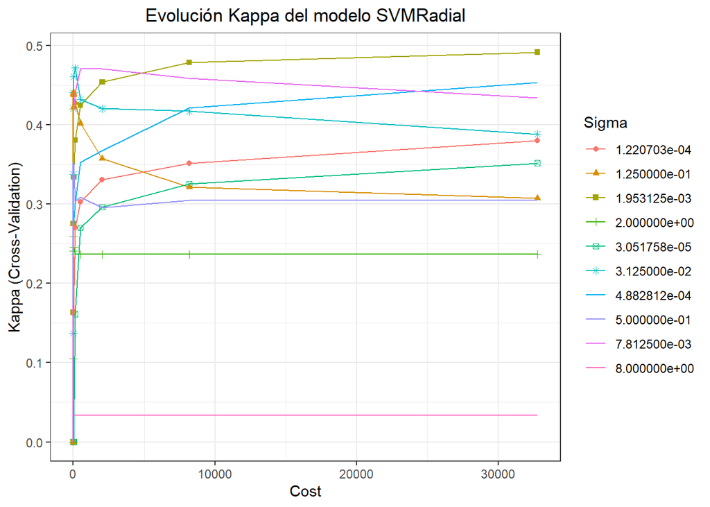

```r
# Gráfico
ggplot(modelo_svmradial) +
  labs(title = "Evolución Kappa del modelo SVMRadial") +
  theme_bw() +
  theme(plot.title = element_text(hjust = 0.5))
```

```r
# Predicciones
p = predict(modelo_svmradial, newdata = dataset.test[1:(ncol(dataset.test)-1)])

# Evaluación
(mconfusion_svmradial = confusionMatrix(p, dataset.test$Clasificación, mode="everything", positive="AF"))
```

```
## Confusion Matrix and Statistics
##
##           Reference
## Prediction  AF FF/FL  NF
##      AF     26     1   4
##      FF/FL   0    19   4
##      NF     16    28 131
##
## Overall Statistics
##
##                Accuracy : 0.7686
##                  95% CI : (0.7085, 0.8216)
##     No Information Rate : 0.607
##     P-Value [Acc > NIR] : 1.608e-07
##
##                   Kappa : 0.5279
##
##  Mcnemar's Test P-Value : 8.661e-06
##
## Statistics by Class:
##
##                      Class: AF Class: FF/FL Class: NF
## Sensitivity             0.6190      0.39583    0.9424
## Specificity             0.9733      0.97790    0.5111
## Pos Pred Value          0.8387      0.82609    0.7486
## Neg Pred Value          0.9192      0.85922    0.8519
## Precision               0.8387      0.82609    0.7486
## Recall                  0.6190      0.39583    0.9424
## F1                      0.7123      0.53521    0.8344
## Prevalence              0.1834      0.20961    0.6070
## Detection Rate          0.1135      0.08297    0.5721
## Detection Prevalence    0.1354      0.10044    0.7642
## Balanced Accuracy       0.7962      0.68687    0.7268
```

#### 4.6.5.3 SVM-polynomial

```r
# Hiperparámetros
hiperparametros = expand.grid(degree = c(2,3),
                               scale = c(0.1,0.15,0.2,0.25,0.3,0.5),
                               C = c(1,5,10,15,20,30))

# Ajuste del modelo
set.seed(29)
(modelo_svmpoly = train(Clasificación ~ ., data = dataset.train,
                          method = "svmPoly",
                          tuneGrid = hiperparametros,
                          metric = "Kappa",
                          trControl = fitControl))
```

```
## Support Vector Machines with Polynomial Kernel
##
## 538 samples
##   7 predictor
##   3 classes: 'AF', 'FF/FL', 'NF'
##
## No pre-processing
## Resampling: Cross-Validated (10 fold)
## Summary of sample sizes: 485, 484, 484, 485, 483, 484, ...
## Resampling results across tuning parameters:
##
##   degree  scale  C   Accuracy   Kappa      Mean_F1    Mean_Sensitivity
##   2       0.10    1  0.7344070  0.4518248  0.6246878  0.6122327
##   2       0.10    5  0.7435665  0.4825104  0.6412614  0.6352504
##   2       0.10   10  0.7417146  0.4830926  0.6492201  0.6400168
##   2       0.10   15  0.7435665  0.4892549  0.6563411  0.6450358
##   2       0.10   20  0.7380097  0.4795898  0.6477629  0.6399537
##   2       0.10   30  0.7360543  0.4799351  0.6472111  0.6438657
##   2       0.15    1  0.7362264  0.4601842  0.6307788  0.6196254
##   2       0.15    5  0.7417832  0.4841276  0.6484410  0.6402694
##   2       0.15   10  0.7380097  0.4825099  0.6484311  0.6422769
##   2       0.15   15  0.7360543  0.4782062  0.6444330  0.6418771
##   2       0.15   20  0.7379061  0.4831883  0.6472166  0.6451789
##   2       0.15   30  0.7416460  0.4936232  0.6545594  0.6533102
##   2       0.20    1  0.7417483  0.4775225  0.6416641  0.6316141
##   2       0.20    5  0.7434642  0.4919665  0.6553293  0.6476305
##   2       0.20   10  0.7361229  0.4799816  0.6449150  0.6442003
##   2       0.20   15  0.7472016  0.5036331  0.6628996  0.6583923
##   2       0.20   20  0.7360543  0.4843794  0.6489131  0.6479251
##   2       0.20   30  0.7323829  0.4803854  0.6456154  0.6453178
##   2       0.25    1  0.7417146  0.4762070  0.6408646  0.6319171
##   2       0.25    5  0.7380097  0.4792622  0.6476528  0.6399537
##   2       0.25   10  0.7453497  0.4990024  0.6585124  0.6553620
##   2       0.25   15  0.7379410  0.4880634  0.6490363  0.6489668
##   2       0.25   20  0.7305311  0.4768004  0.6412237  0.6425400
##   2       0.25   30  0.7303589  0.4794994  0.6458507  0.6465362
##   2       0.30    1  0.7417146  0.4821134  0.6426297  0.6362605
##   2       0.30    5  0.7379410  0.4826527  0.6468320  0.6452104
##   2       0.30   10  0.7379410  0.4880634  0.6490363  0.6489668
##   2       0.30   15  0.7267575  0.4711263  0.6386465  0.6404566
```

[output cut: 178 more lines]

```
##   0.6144108    0.2318946            0.7029928
##   0.6220013    0.2337810            0.7099513
##   0.6195707    0.2288298            0.7071773
##   0.6078030    0.2269318            0.6989213
##   0.6030808    0.2244389            0.6949905
##   0.6052273    0.2256856            0.6964165
##   0.6271023    0.2343875            0.7132691
##   0.6026578    0.2238557            0.6944271
##   0.6194760    0.2275374            0.7074462
##   0.6068939    0.2226095            0.6969155
##   0.6126705    0.2250562            0.7008948
##   0.6156334    0.2244506            0.7027555
##
## Kappa was used to select the optimal model using the largest value.
## The final values used for the model were degree = 2, scale = 0.2 and C = 15.
```

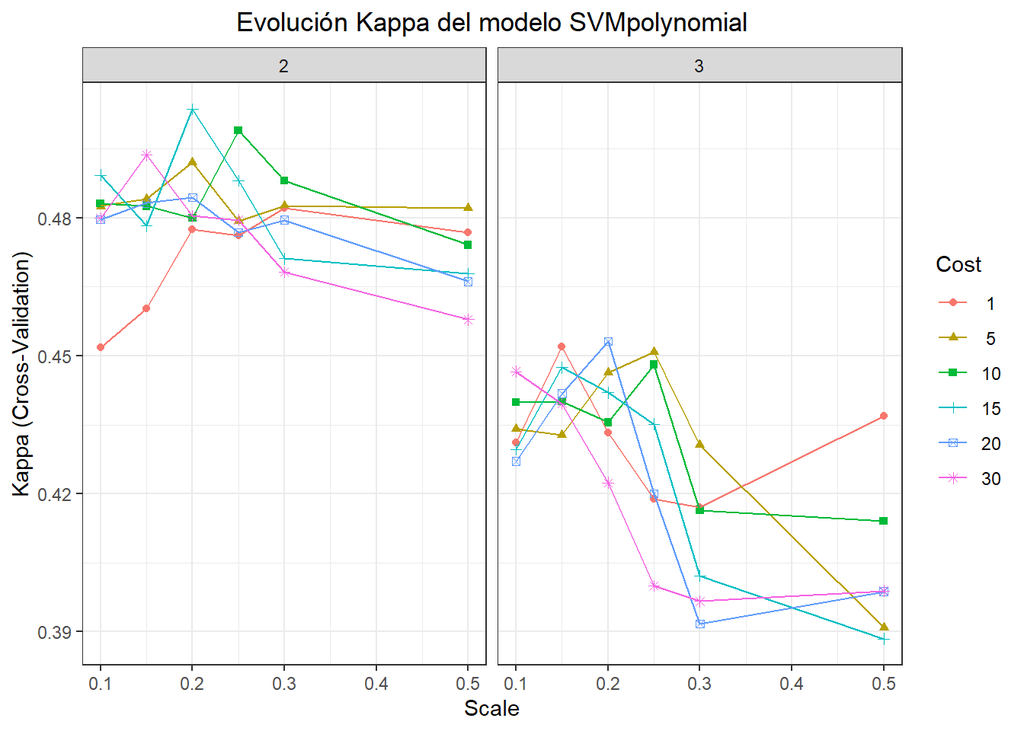

```r
# Gráfico
ggplot(modelo_svmpoly) +
  labs(title = "Evolución Kappa del modelo SVMpolynomial") +
  theme_bw() +
  theme(plot.title = element_text(hjust = 0.5))
```

```r
# Predicciones
p = predict(modelo_svmpoly, newdata = dataset.test[1:(ncol(dataset.test)-1)])

# Evaluación
(mconfusion_svmpoly = confusionMatrix(p, dataset.test$Clasificación, mode="everything", positive="AF"))
```

```
## Confusion Matrix and Statistics
##
##           Reference
## Prediction  AF FF/FL  NF
##      AF     26     1   5
##      FF/FL   0    18   4
##      NF     16    29 130
##
## Overall Statistics
##
##                Accuracy : 0.7598
##                  95% CI : (0.6991, 0.8136)
##     No Information Rate : 0.607
##     P-Value [Acc > NIR] : 7.282e-07
##
##                   Kappa : 0.5102
##
##  Mcnemar's Test P-Value : 1.101e-05
##
## Statistics by Class:
##
##                      Class: AF Class: FF/FL Class: NF
## Sensitivity             0.6190      0.37500    0.9353
## Specificity             0.9679      0.97790    0.5000
## Pos Pred Value          0.8125      0.81818    0.7429
## Neg Pred Value          0.9188      0.85507    0.8333
## Precision               0.8125      0.81818    0.7429
## Recall                  0.6190      0.37500    0.9353
## F1                      0.7027      0.51429    0.8280
## Prevalence              0.1834      0.20961    0.6070
## Detection Rate          0.1135      0.07860    0.5677
## Detection Prevalence    0.1397      0.09607    0.7642
## Balanced Accuracy       0.7935      0.67645    0.7176
```

```r
resultados_SVM_poly <- data.frame(
  Modelo              = "SVM-poly",
  Precisión           = round((ifelse(is.na(mconfusion_svmpoly$byClass[1,5]), 0, mconfusion_svmpoly$byClass[1,5]) +
                              ifelse(is.na(mconfusion_svmpoly$byClass[2,5]), 0, mconfusion_svmpoly$byClass[2,5]) +
                              ifelse(is.na(mconfusion_svmpoly$byClass[3,5]), 0, mconfusion_svmpoly$byClass[3,5]) ) / 3, 3),

  Sensibilidad        = round((ifelse(is.na(mconfusion_svmpoly$byClass[1,1]), 0, mconfusion_svmpoly$byClass[1,1]) +
                              ifelse(is.na(mconfusion_svmpoly$byClass[2,1]), 0, mconfusion_svmpoly$byClass[2,1]) +
                              ifelse(is.na(mconfusion_svmpoly$byClass[3,1]), 0, mconfusion_svmpoly$byClass[3,1]) ) / 3, 3),

  Especificidad       = round((ifelse(is.na(mconfusion_svmpoly$byClass[1,2]), 0, mconfusion_svmpoly$byClass[1,2]) +
                              ifelse(is.na(mconfusion_svmpoly$byClass[2,2]), 0, mconfusion_svmpoly$byClass[2,2]) +
                              ifelse(is.na(mconfusion_svmpoly$byClass[3,2]), 0, mconfusion_svmpoly$byClass[3,2]) ) /3, 3),
  kappa               = round(mconfusion_svmpoly[["overall"]][["Kappa"]], 3),
  F1                  = round((ifelse(is.na(mconfusion_svmpoly$byClass[1,7]), 0, mconfusion_svmpoly$byClass[1,7]) +
                              ifelse(is.na(mconfusion_svmpoly$byClass[2,7]), 0, mconfusion_svmpoly$byClass[2,7]) +
                              ifelse(is.na(mconfusion_svmpoly$byClass[3,7]), 0, mconfusion_svmpoly$byClass[3,7]) ) / 3, 3),
  Error_clasificación = round((1 - mconfusion_svmpoly[["overall"]][["Accuracy"]]) * 100, 3),
  Accuracy            = round(mconfusion_svmpoly[["overall"]][["Accuracy"]], 3)
)

resultados_SVM_poly
```

```
##     Modelo Precisión Sensibilidad Especificidad kappa    F1 Error_clasificación
## 1 SVM-poly     0.791        0.643         0.815  0.51 0.682              24.017
##   Accuracy
## 1     0.76
```

### 4.6.6 Árbol de decisión

```r
#Hiperparámetros
hiperparametros <- expand.grid(trials = c(10:40),
                               model = c("tree","rules"),
                               winnow = c(FALSE,TRUE))

# Ajuste del modelo
set.seed(29)
(modelo_C5.0 <- train(Clasificación ~ ., data = dataset.train,
                     method = "C5.0",
                     tuneGrid = hiperparametros,
                     metric = "Kappa",
                     trControl = fitControl
                     ))
```

```
## C5.0
##
## 538 samples
##   7 predictor
##   3 classes: 'AF', 'FF/FL', 'NF'
##
## No pre-processing
## Resampling: Cross-Validated (10 fold)
## Summary of sample sizes: 485, 484, 484, 485, 483, 484, ...
## Resampling results across tuning parameters:
##
##   model  winnow  trials  Accuracy   Kappa      Mean_F1    Mean_Sensitivity
##   rules  FALSE   10      0.6617902  0.3675999  0.5859687  0.5908565
##   rules  FALSE   11      0.6634375  0.3618495  0.5806619  0.5833333
##   rules  FALSE   12      0.6653243  0.3687875  0.5830980  0.5888047
##   rules  FALSE   13      0.6836033  0.4010160  0.6044558  0.6051389
##   rules  FALSE   14      0.6764704  0.3853235  0.5971592  0.5965783
##   rules  FALSE   15      0.6764354  0.3913130  0.6006028  0.6032681
##   rules  FALSE   16      0.6727317  0.3768945  0.5906045  0.5899937
##   rules  FALSE   17      0.6727667  0.3766274  0.5916694  0.5883249
##   rules  FALSE   18      0.6691303  0.3686149  0.5849137  0.5845875
##   rules  FALSE   19      0.6728340  0.3755590  0.5880062  0.5882934
##   rules  FALSE   20      0.6634362  0.3606441  0.5828685  0.5806355
##   rules  FALSE   21      0.6634362  0.3586491  0.5807985  0.5788678
##   rules  FALSE   22      0.6598012  0.3537518  0.5776573  0.5766267
##   rules  FALSE   23      0.6672435  0.3663443  0.5850653  0.5829398
##   rules  FALSE   24      0.6617216  0.3517938  0.5750991  0.5737984
##   rules  FALSE   25      0.6599022  0.3508944  0.5776429  0.5747769
##   rules  FALSE   26      0.6654253  0.3616655  0.5827093  0.5801620
##   rules  FALSE   27      0.6654253  0.3616655  0.5827093  0.5801620
##   rules  FALSE   28      0.6616867  0.3544670  0.5789343  0.5757870
##   rules  FALSE   29      0.6690267  0.3690852  0.5869562  0.5841709
##   rules  FALSE   30      0.6672098  0.3619314  0.5815978  0.5788489
##   rules  FALSE   31      0.6634362  0.3544695  0.5773468  0.5747769
##   rules  FALSE   32      0.6635049  0.3570025  0.5796898  0.5767971
##   rules  FALSE   33      0.6598685  0.3485871  0.5747499  0.5724537
##   rules  FALSE   34      0.6616867  0.3521530  0.5766694  0.5734638
##   rules  FALSE   35      0.6635735  0.3544753  0.5778179  0.5745055
##   rules  FALSE   36      0.6616867  0.3521530  0.5766694  0.5734638
##   rules  FALSE   37      0.6653917  0.3594249  0.5797261  0.5778388
```

[output cut: 335 more lines]

```
##   0.5817151    0.2324873            0.6814203
##   0.5817151    0.2324873            0.6814203
##   0.5817151    0.2324873            0.6814203
##   0.5817151    0.2324873            0.6814203
##   0.5817151    0.2324873            0.6814203
##   0.5817151    0.2324873            0.6814203
##   0.5817151    0.2324873            0.6814203
##   0.5817151    0.2324873            0.6814203
##   0.5817151    0.2324873            0.6814203
##   0.5817151    0.2324873            0.6814203
##   0.5817151    0.2324873            0.6814203
##
## Kappa was used to select the optimal model using the largest value.
## The final values used for the model were trials = 11, model = tree and winnow
##  = FALSE.
```

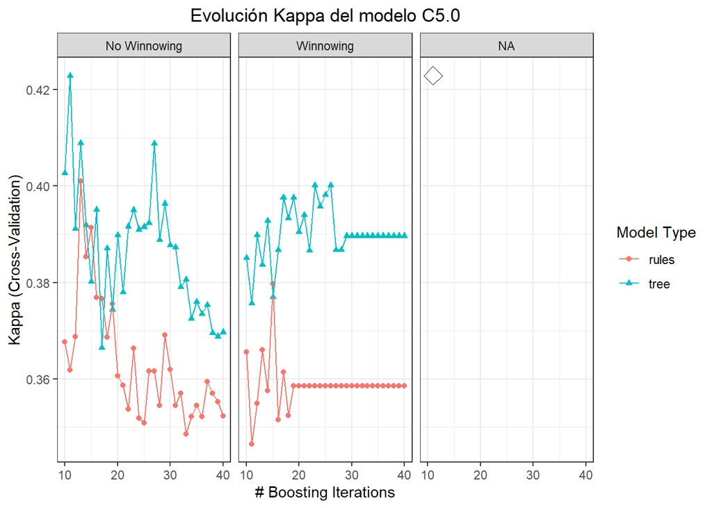

```r
# Gráfico
ggplot(modelo_C5.0, highlight = TRUE) +
  labs(title = "Evolución Kappa del modelo C5.0") +
  theme_bw() +
  theme(plot.title = element_text(hjust = 0.5))
```

```r
# Predicciones
p <- predict(modelo_C5.0, dataset.test[1:(ncol(dataset.test)-1)])

# Evaluación
(mconfusion_arbol = confusionMatrix(data = p, reference = dataset.test$Clasificación, mode="everything", positive="AF"))
```

```
## Confusion Matrix and Statistics
##
##           Reference
## Prediction  AF FF/FL  NF
##      AF     23     2   7
##      FF/FL   2    12   3
##      NF     17    34 129
##
## Overall Statistics
##
##                Accuracy : 0.7162
##                  95% CI : (0.653, 0.7736)
##     No Information Rate : 0.607
##     P-Value [Acc > NIR] : 0.000364
##
##                   Kappa : 0.4108
##
##  Mcnemar's Test P-Value : 1.29e-06
##
## Statistics by Class:
##
##                      Class: AF Class: FF/FL Class: NF
## Sensitivity             0.5476      0.25000    0.9281
## Specificity             0.9519      0.97238    0.4333
## Pos Pred Value          0.7188      0.70588    0.7167
## Neg Pred Value          0.9036      0.83019    0.7959
## Precision               0.7188      0.70588    0.7167
## Recall                  0.5476      0.25000    0.9281
## F1                      0.6216      0.36923    0.8088
## Prevalence              0.1834      0.20961    0.6070
## Detection Rate          0.1004      0.05240    0.5633
## Detection Prevalence    0.1397      0.07424    0.7860
## Balanced Accuracy       0.7497      0.61119    0.6807
```

```r
resultados_arbol <- data.frame(
  Modelo              = "Árbol",
  Precisión           = round((ifelse(is.na(mconfusion_arbol$byClass[1,5]), 0, mconfusion_arbol$byClass[1,5]) +
                              ifelse(is.na(mconfusion_arbol$byClass[2,5]), 0, mconfusion_arbol$byClass[2,5]) +
                              ifelse(is.na(mconfusion_arbol$byClass[3,5]), 0, mconfusion_arbol$byClass[3,5]) ) / 3, 3),
  Sensibilidad        = round((ifelse(is.na(mconfusion_arbol$byClass[1,1]), 0, mconfusion_arbol$byClass[1,1]) +
                              ifelse(is.na(mconfusion_arbol$byClass[2,1]), 0, mconfusion_arbol$byClass[2,1]) +
                              ifelse(is.na(mconfusion_arbol$byClass[3,1]), 0, mconfusion_arbol$byClass[3,1]) ) / 3, 3),

  Especificidad       = round((ifelse(is.na(mconfusion_arbol$byClass[1,2]), 0, mconfusion_arbol$byClass[1,2]) +
                              ifelse(is.na(mconfusion_arbol$byClass[2,2]), 0, mconfusion_arbol$byClass[2,2]) +
                              ifelse(is.na(mconfusion_arbol$byClass[3,2]), 0, mconfusion_arbol$byClass[3,2])) / 3, 3),

  kappa               = round(mconfusion_arbol[["overall"]][["Kappa"]], 3),
  F1                  = round((ifelse(is.na(mconfusion_arbol$byClass[1,7]), 0, mconfusion_arbol$byClass[1,7]) +
                              ifelse(is.na(mconfusion_arbol$byClass[2,7]), 0, mconfusion_arbol$byClass[2,7]) +
                              ifelse(is.na(mconfusion_arbol$byClass[3,7]), 0, mconfusion_arbol$byClass[3,7]) ) / 3, 3),
  Error_clasificación = round((1 - mconfusion_arbol[["overall"]][["Accuracy"]]) * 100, 3),
  Accuracy            = round(mconfusion_arbol[["overall"]][["Accuracy"]], 3)
)

resultados_arbol
```

```
##   Modelo Precisión Sensibilidad Especificidad kappa  F1 Error_clasificación
## 1  Árbol     0.714        0.575         0.786 0.411 0.6              28.384
##   Accuracy
## 1    0.716
```

### 4.6.7 Random Forest

```r
# Hiperparámetros
hiperparametros <- expand.grid(mtry = c(1:5),
                               min.node.size = c(1,2,3,4),
                               splitrule = c("gini","extratrees"))

# Ajuste del modelo
set.seed(29)
(modelo_forest <- train(Clasificación ~ ., data = dataset.train,
                   method = "ranger",
                   tuneGrid = hiperparametros,
                   metric = "Kappa",
                   trControl = fitControl,
                   # Número de árboles ajustados
                   num.trees = 500
                   ))
```

```
## Random Forest
##
## 538 samples
##   7 predictor
##   3 classes: 'AF', 'FF/FL', 'NF'
##
## No pre-processing
## Resampling: Cross-Validated (10 fold)
## Summary of sample sizes: 485, 484, 484, 485, 483, 484, ...
## Resampling results across tuning parameters:
##
##   mtry  min.node.size  splitrule   Accuracy   Kappa      Mean_F1
##   1     1              gini        0.7216486  0.4073506  0.6204093
##   1     1              extratrees  0.6862175  0.2877004  0.5441575
##   1     2              gini        0.7215787  0.4107121  0.6219541
##   1     2              extratrees  0.6898526  0.3011539  0.5203618
##   1     3              gini        0.7233270  0.4146460  0.6097042
##   1     3              extratrees  0.6862512  0.2864099  0.5372194
##   1     4              gini        0.7140315  0.3948486  0.6077801
##   1     4              extratrees  0.6899225  0.2959515  0.5380428
##   2     1              gini        0.7215450  0.4524964  0.6541192
##   2     1              extratrees  0.7084772  0.4171032  0.6122237
##   2     2              gini        0.7214751  0.4539001  0.6368044
##   2     2              extratrees  0.7176691  0.4299377  0.6138065
##   2     3              gini        0.7251801  0.4625625  0.6464362
##   2     3              extratrees  0.7157125  0.4276911  0.6092423
##   2     4              gini        0.7252487  0.4540517  0.6370243
##   2     4              extratrees  0.7120774  0.4167544  0.6060669
##   3     1              gini        0.7065206  0.4287091  0.6220976
##   3     1              extratrees  0.7195572  0.4433515  0.6309549
##   3     2              gini        0.7177028  0.4558186  0.6446749
##   3     2              extratrees  0.7232946  0.4450129  0.6278280
##   3     3              gini        0.7268947  0.4680095  0.6463291
##   3     3              extratrees  0.7231561  0.4529966  0.6353035
##   3     4              gini        0.7065193  0.4285612  0.6222014
##   3     4              extratrees  0.7212693  0.4403235  0.6250612
##   4     1              gini        0.7176691  0.4522430  0.6383701
##   4     1              extratrees  0.7270682  0.4677031  0.6532354
##   4     2              gini        0.7138606  0.4480545  0.6401018
##   4     2              extratrees  0.7213417  0.4471825  0.6326510
```

[output cut: 83 more lines]

```
##   0.7030310       0.6111216    0.2386286            0.7014202
##   0.6771238       0.6296023    0.2379648            0.7161092
##   0.7298881       0.6346444    0.2429155            0.7190711
##   0.6851940       0.6319318    0.2373703            0.7173369
##   0.7225487       0.6331103    0.2423099            0.7179072
##   0.6903653       0.6349937    0.2379760            0.7196526
##   0.7150465       0.6391898    0.2423099            0.7221018
##   0.6796671       0.6195518    0.2361699            0.7084051
##   0.7137775       0.6318476    0.2416581            0.7172406
##   0.6850968       0.6278157    0.2379989            0.7141332
##   0.7119644       0.6249474    0.2398399            0.7119234
##
## Kappa was used to select the optimal model using the largest value.
## The final values used for the model were mtry = 3, splitrule = gini
##  and min.node.size = 3.
```

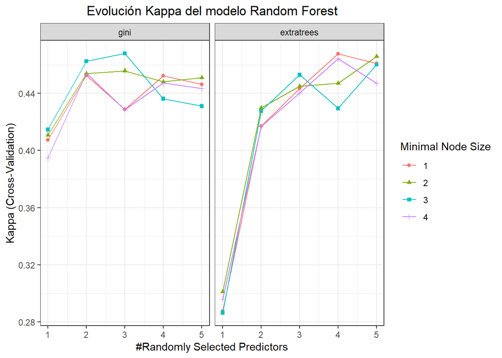

```r
# Gráfico
ggplot(modelo_forest) +
  labs(title = "Evolución Kappa del modelo Random Forest") +
  theme_bw() +
  theme(plot.title = element_text(hjust = 0.5))
```

```r
# Predicciones
p <- predict(modelo_forest, newdata = dataset.test)


# Evaluación
(mconfusion_forest <- confusionMatrix(data = p, reference = dataset.test$Clasificación, mode="everything", positive="AF"))
```

```
## Confusion Matrix and Statistics
##
##           Reference
## Prediction  AF FF/FL  NF
##      AF     27     0   7
##      FF/FL   2    21   8
##      NF     13    27 124
##
## Overall Statistics
##
##                Accuracy : 0.7511
##                  95% CI : (0.6899, 0.8057)
##     No Information Rate : 0.607
##     P-Value [Acc > NIR] : 3.007e-06
##
##                   Kappa : 0.5117
##
##  Mcnemar's Test P-Value : 0.002754
##
## Statistics by Class:
##
##                      Class: AF Class: FF/FL Class: NF
## Sensitivity             0.6429       0.4375    0.8921
## Specificity             0.9626       0.9448    0.5556
## Pos Pred Value          0.7941       0.6774    0.7561
## Neg Pred Value          0.9231       0.8636    0.7692
## Precision               0.7941       0.6774    0.7561
## Recall                  0.6429       0.4375    0.8921
## F1                      0.7105       0.5316    0.8185
## Prevalence              0.1834       0.2096    0.6070
## Detection Rate          0.1179       0.0917    0.5415
## Detection Prevalence    0.1485       0.1354    0.7162
## Balanced Accuracy       0.8027       0.6911    0.7238
```

```r
resultados_RF <- data.frame(
  Modelo              = "Random Forest",
  Precisión           = round((ifelse(is.na(mconfusion_forest$byClass[1,5]), 0, mconfusion_forest$byClass[1,5]) +
                              ifelse(is.na(mconfusion_forest$byClass[2,5]), 0, mconfusion_forest$byClass[2,5]) +
                              ifelse(is.na(mconfusion_forest$byClass[3,5]), 0, mconfusion_forest$byClass[3,5]) ) / 3, 3),
  Sensibilidad        = round((ifelse(is.na(mconfusion_forest$byClass[1,1]), 0, mconfusion_forest$byClass[1,1]) +
                              ifelse(is.na(mconfusion_forest$byClass[2,1]), 0, mconfusion_forest$byClass[2,1]) +
                              ifelse(is.na(mconfusion_forest$byClass[3,1]), 0, mconfusion_forest$byClass[3,1]) ) / 3, 3),
  Especificidad       = round((ifelse(is.na(mconfusion_forest$byClass[1,2]), 0, mconfusion_forest$byClass[1,2]) +
                              ifelse(is.na(mconfusion_forest$byClass[2,2]), 0, mconfusion_forest$byClass[2,2]) +
                              ifelse(is.na(mconfusion_forest$byClass[3,2]), 0, mconfusion_forest$byClass[3,2]) ) / 3, 3),
  kappa               = round(mconfusion_forest[["overall"]][["Kappa"]], 3),
  F1                  = round((ifelse(is.na(mconfusion_forest$byClass[1,7]), 0, mconfusion_forest$byClass[1,7]) +
                              ifelse(is.na(mconfusion_forest$byClass[2,7]), 0, mconfusion_forest$byClass[2,7]) +
                              ifelse(is.na(mconfusion_forest$byClass[3,7]), 0, mconfusion_forest$byClass[3,7]) ) / 3, 3),
  Error_clasificación = round((1 - mconfusion_forest[["overall"]][["Accuracy"]]) * 100, 3),
  Accuracy            = round(mconfusion_forest[["overall"]][["Accuracy"]], 3)
)

resultados_RF
```

```
##          Modelo Precisión Sensibilidad Especificidad kappa    F1
## 1 Random Forest     0.743        0.657         0.821 0.512 0.687
##   Error_clasificación Accuracy
## 1              24.891    0.751
```

### 4.6.8 Boosting

```r
hiperparametros= expand.grid(interaction.depth = c(1, 5:9),
                        n.trees = (1:30)*50,
                        shrinkage = 0.1,
                        n.minobsinnode = 20)
# Ajuste del modelo
set.seed(29)
modelo_boosting <- train(Clasificación ~ ., data = dataset.train,
                   method = "gbm",
                   tuneGrid = hiperparametros,
                   metric = "Kappa",
                    trControl = fitControl
                   )
modelo_boosting
```

```
## Stochastic Gradient Boosting
##
## 538 samples
##   7 predictor
##   3 classes: 'AF', 'FF/FL', 'NF'
##
## No pre-processing
## Resampling: Cross-Validated (10 fold)
## Summary of sample sizes: 485, 484, 484, 485, 483, 484, ...
## Resampling results across tuning parameters:
##
##   interaction.depth  n.trees  Accuracy   Kappa      Mean_F1    Mean_Sensitivity
##   1                    50     0.7065555  0.4000235  0.6058667  0.5816035
##   1                   100     0.7009313  0.4040979  0.5968647  0.5923148
##   1                   150     0.6991119  0.4010761  0.5972205  0.5901936
##   1                   200     0.6896779  0.3912491  0.5961879  0.5913678
##   1                   250     0.6840537  0.3869303  0.5967012  0.5928388
##   1                   300     0.6785306  0.3819815  0.5948509  0.5900989
##   1                   350     0.6748955  0.3807099  0.5924010  0.5926620
##   1                   400     0.6766787  0.3834442  0.5974647  0.5993476
##   1                   450     0.6655301  0.3581476  0.5778880  0.5776494
##   1                   500     0.6842246  0.4005626  0.6074672  0.6086090
##   1                   550     0.6784944  0.3874910  0.5969454  0.5982239
##   1                   600     0.6748256  0.3820030  0.5973597  0.5956797
##   1                   650     0.6785979  0.3866943  0.5997304  0.5981061
##   1                   700     0.6710508  0.3743313  0.5913668  0.5886111
##   1                   750     0.6748593  0.3809192  0.5918713  0.5952273
##   1                   800     0.6673807  0.3661936  0.5844141  0.5866982
##   1                   850     0.6730411  0.3822908  0.6013039  0.5988826
##   1                   900     0.6655638  0.3635058  0.5857513  0.5845728
##   1                   950     0.6691665  0.3784208  0.5976761  0.5984343
##   1                  1000     0.6544165  0.3518904  0.5844718  0.5830177
##   1                  1050     0.6655301  0.3708053  0.5970031  0.5938384
##   1                  1100     0.6580529  0.3542483  0.5846516  0.5810480
##   1                  1150     0.6580529  0.3568178  0.5849920  0.5830997
##   1                  1200     0.6600083  0.3564434  0.5860623  0.5820707
##   1                  1250     0.6524624  0.3512763  0.5864499  0.5840152
##   1                  1300     0.6450187  0.3389140  0.5782359  0.5765215
##   1                  1350     0.6505756  0.3524078  0.5892529  0.5879230
##   1                  1400     0.6488959  0.3388283  0.5772479  0.5756944
```

[output cut: 506 more lines]

```
##   0.5984259    0.2211924            0.6888179
##   0.5950295    0.2205635            0.6863247
##   0.5961027    0.2211924            0.6872771
##   0.6047896    0.2224386            0.6935862
##   0.6014247    0.2218214            0.6911008
##   0.6137795    0.2236965            0.7000573
##   0.6050295    0.2212045            0.6933013
##   0.6157365    0.2236624            0.7018022
##
## Tuning parameter 'shrinkage' was held constant at a value of 0.1
##
## Tuning parameter 'n.minobsinnode' was held constant at a value of 20
## Kappa was used to select the optimal model using the largest value.
## The final values used for the model were n.trees = 50, interaction.depth =
##  9, shrinkage = 0.1 and n.minobsinnode = 20.
```

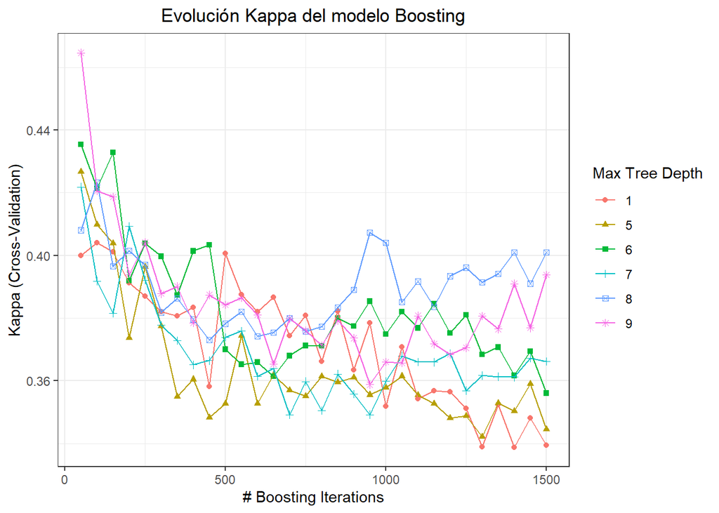

```r
# Gráfico
ggplot(modelo_boosting) +
  labs(title = "Evolución Kappa del modelo Boosting") +
  theme_bw() +
  theme(plot.title = element_text(hjust = 0.5))
```

```r
# Predicciones
p <- predict(modelo_boosting, newdata = dataset.test)


# Evaluación
(mconfusion_boosting <- confusionMatrix(data = p, reference = dataset.test$Clasificación, mode="everything", positive="AF"))
```

```
## Confusion Matrix and Statistics
##
##           Reference
## Prediction  AF FF/FL  NF
##      AF     25     0   6
##      FF/FL   2    22  13
##      NF     15    26 120
##
## Overall Statistics
##
##                Accuracy : 0.7293
##                  95% CI : (0.6668, 0.7857)
##     No Information Rate : 0.607
##     P-Value [Acc > NIR] : 7.066e-05
##
##                   Kappa : 0.4738
##
##  Mcnemar's Test P-Value : 0.01701
##
## Statistics by Class:
##
##                      Class: AF Class: FF/FL Class: NF
## Sensitivity             0.5952      0.45833    0.8633
## Specificity             0.9679      0.91713    0.5444
## Pos Pred Value          0.8065      0.59459    0.7453
## Neg Pred Value          0.9141      0.86458    0.7206
## Precision               0.8065      0.59459    0.7453
## Recall                  0.5952      0.45833    0.8633
## F1                      0.6849      0.51765    0.8000
## Prevalence              0.1834      0.20961    0.6070
## Detection Rate          0.1092      0.09607    0.5240
## Detection Prevalence    0.1354      0.16157    0.7031
## Balanced Accuracy       0.7816      0.68773    0.7039
```

### 4.6.9 Bagging

```r
# Hiperparámetros
hiperparametros= expand.grid(mtry = c(1:5, 9))

# Ajuste del modelo
set.seed(29)
(modelo_Bagging <- train(Clasificación ~ ., data = dataset.train,
                   method = "parRF",
                   tuneGrid = hiperparametros,
                   metric = "Kappa",
                    trControl = fitControl
                   ))
```

```
## Parallel Random Forest
##
## 538 samples
##   7 predictor
##   3 classes: 'AF', 'FF/FL', 'NF'
##
## No pre-processing
## Resampling: Cross-Validated (10 fold)
## Summary of sample sizes: 485, 484, 484, 485, 483, 484, ...
## Resampling results across tuning parameters:
##
##   mtry  Accuracy   Kappa      Mean_F1    Mean_Sensitivity  Mean_Specificity
##   1     0.7233969  0.4130805  0.6256136  0.5831881         0.7829501
##   2     0.7214415  0.4528977  0.6517393  0.6314310         0.8018206
##   3     0.7140341  0.4458137  0.6348489  0.6297517         0.8018592
##   4     0.7120437  0.4384297  0.6290844  0.6224811         0.7986662
##   5     0.7047011  0.4285805  0.6259721  0.6198232         0.7965178
##   9     0.7158160  0.4530207  0.6433451  0.6337795         0.8057369
##   Mean_Pos_Pred_Value  Mean_Neg_Pred_Value  Mean_Precision  Mean_Recall
##   0.7600101            0.8586254            0.7600101       0.5831881
##   0.6868498            0.8343821            0.6868498       0.6314310
##   0.6787798            0.8291957            0.6787798       0.6297517
##   0.6789025            0.8281888            0.6789025       0.6224811
##   0.6709973            0.8196424            0.6709973       0.6198232
##   0.6900601            0.8296895            0.6900601       0.6337795
##   Mean_Detection_Rate  Mean_Balanced_Accuracy
##   0.2411323            0.6830691
##   0.2404805            0.7166258
##   0.2380114            0.7158055
##   0.2373479            0.7105736
##   0.2349004            0.7081705
##   0.2386053            0.7197582
##
## Kappa was used to select the optimal model using the largest value.
## The final value used for the model was mtry = 9.
```

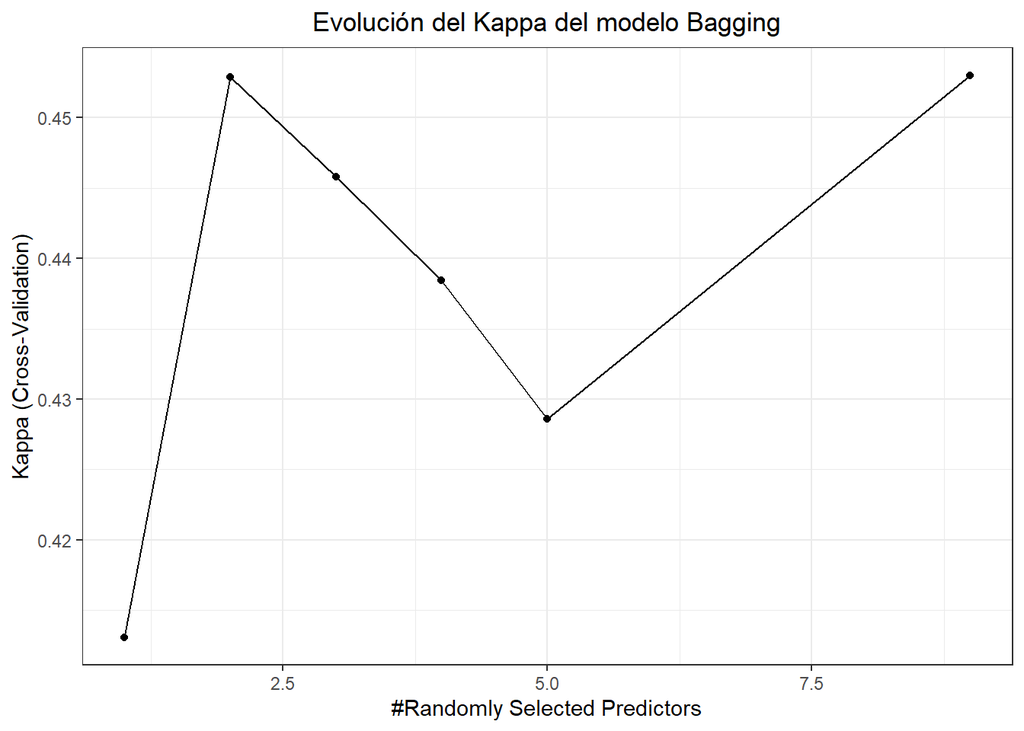

```r
# Gráfico
ggplot(modelo_Bagging) +
  labs(title = "Evolución del Kappa del modelo Bagging") +
  theme_bw() +
  theme(plot.title = element_text(hjust = 0.5))
```

```r
# Predicciones
p <- predict(modelo_Bagging, newdata = dataset.test)


# Evaluación
(mconfusion_Bagging <- confusionMatrix(data = p, reference = dataset.test$Clasificación, mode="everything", positive="AF"))
```

```
## Confusion Matrix and Statistics
##
##           Reference
## Prediction  AF FF/FL  NF
##      AF     28     0   8
##      FF/FL   2    21  10
##      NF     12    27 121
##
## Overall Statistics
##
##                Accuracy : 0.7424
##                  95% CI : (0.6806, 0.7977)
##     No Information Rate : 0.607
##     P-Value [Acc > NIR] : 1.135e-05
##
##                   Kappa : 0.5015
##
##  Mcnemar's Test P-Value : 0.01403
##
## Statistics by Class:
##
##                      Class: AF Class: FF/FL Class: NF
## Sensitivity             0.6667       0.4375    0.8705
## Specificity             0.9572       0.9337    0.5667
## Pos Pred Value          0.7778       0.6364    0.7562
## Neg Pred Value          0.9275       0.8622    0.7391
## Precision               0.7778       0.6364    0.7562
## Recall                  0.6667       0.4375    0.8705
## F1                      0.7179       0.5185    0.8094
## Prevalence              0.1834       0.2096    0.6070
## Detection Rate          0.1223       0.0917    0.5284
## Detection Prevalence    0.1572       0.1441    0.6987
## Balanced Accuracy       0.8119       0.6856    0.7186
```

```r
resultados_bagging <- data.frame(
  Modelo              = "Bagging",
  Precisión           = round((ifelse(is.na(mconfusion_Bagging$byClass[1,5]), 0, mconfusion_Bagging$byClass[1,5]) +
                              ifelse(is.na(mconfusion_Bagging$byClass[2,5]), 0, mconfusion_Bagging$byClass[2,5]) +
                              ifelse(is.na(mconfusion_Bagging$byClass[3,5]), 0, mconfusion_Bagging$byClass[3,5])  ) / 3, 3),
  Sensibilidad        = round((ifelse(is.na(mconfusion_Bagging$byClass[1,1]), 0, mconfusion_Bagging$byClass[1,1]) +
                              ifelse(is.na(mconfusion_Bagging$byClass[2,1]), 0, mconfusion_Bagging$byClass[2,1]) +
                              ifelse(is.na(mconfusion_Bagging$byClass[3,1]), 0, mconfusion_Bagging$byClass[3,1])  ) /3, 3),
  Especificidad       = round((ifelse(is.na(mconfusion_Bagging$byClass[1,2]), 0, mconfusion_Bagging$byClass[1,2]) +
                              ifelse(is.na(mconfusion_Bagging$byClass[2,2]), 0, mconfusion_Bagging$byClass[2,2]) +
                              ifelse(is.na(mconfusion_Bagging$byClass[3,2]), 0, mconfusion_Bagging$byClass[3,2])  ) / 3, 3),
  kappa               = round(mconfusion_Bagging[["overall"]][["Kappa"]], 3),
  F1                  = round((ifelse(is.na(mconfusion_Bagging$byClass[1,7]), 0, mconfusion_Bagging$byClass[1,7]) +
                              ifelse(is.na(mconfusion_Bagging$byClass[2,7]), 0, mconfusion_Bagging$byClass[2,7]) +
                              ifelse(is.na(mconfusion_Bagging$byClass[3,7]), 0, mconfusion_Bagging$byClass[3,7])  ) / 3, 3),
  Error_clasificación = round((1 - mconfusion_Bagging[["overall"]][["Accuracy"]]) * 100, 3),
  Accuracy            = round(mconfusion_Bagging[["overall"]][["Accuracy"]], 3)
)

resultados_bagging
```

```
##    Modelo Precisión Sensibilidad Especificidad kappa    F1 Error_clasificación
## 1 Bagging     0.723        0.658         0.819 0.502 0.682              25.764
##   Accuracy
## 1    0.742
```

### 4.6.10 Tabla resumen del rendimiento de los distintos modelos DESequilibrados con Tuning grids

```r
tabla_resumen_desequilibrada_tuning = rbind(resultados_knn,
                     resultados_NaiveBayes,
                     resultados_ann,
                     resultados_SVM_radial,
                     resultados_svmlineal,
                     resultados_SVM_poly,
                     resultados_arbol,
                     resultados_RF,
                     resultados_boosting,
                     resultados_bagging
                     )

#Establecemos el orden por valores de Sensibilidad
orden = order(tabla_resumen_desequilibrada_tuning$Sensibilidad, decreasing = TRUE)
tabla_resumen_desequilibrada_tuning_ordenada <- tabla_resumen_desequilibrada_tuning[orden, ]

kable(tabla_resumen_desequilibrada_tuning_ordenada, digits = 3, caption = "Rendimiento de los modelos desequilibrados con Tuning grids personalizados")
```

Rendimiento de los modelos desequilibrados con Tuning grids personalizados

[output not shown]

## 4.7 Aplicar pesos a las clases

```r
table(dataset.train$Clasificación)
```

```
##
##    AF FF/FL    NF
##    99   114   325
```

```r
total_samples= nrow(dataset.train)
class_weights <- c("AF" = total_samples/ nrow(filter(dataset.train, dataset.train$Clasificación== "AF")),
                   "FF/FL" = total_samples/ nrow(filter(dataset.train, dataset.train$Clasificación== "FF/FL")),
                   "NF" = total_samples/ nrow(filter(dataset.train, dataset.train$Clasificación== "NF")))
class_weights
```

```
##       AF    FF/FL       NF
## 5.434343 4.719298 1.655385
```

### 4.7.1 Datos equilibrados

#### 4.7.1.1 Paquete RandomForest

Haremos el fine tuning manual:

```r
library(randomForest)
set.seed(29)
# función de validación cruzada
cross_validation <- function(data, k_folds, mtry_values, ntree_values, nodesize_values, class_weights_values, seed=29) {
  set.seed(seed)
  folds <- createFolds(data$Clasificación, k = k_folds, list = TRUE)
  results <- data.frame()

  for (mtry in mtry_values) {
    for (ntree in ntree_values) {
      for (nodesize in nodesize_values) {
        for (classwt in class_weights_values) {
          fold_results <- c()

          for (fold in folds) {
            train_data <- data[-fold,]
            test_data <- data[fold,]

            model <- randomForest(Clasificación ~ ., data = train_data,
                                  mtry = mtry, ntree = ntree, nodesize = nodesize, classwt = classwt)
            predictions <- predict(model, newdata = test_data)
            cm <- confusionMatrix(predictions, test_data$Clasificación)

            fold_results <- c(fold_results, cm$overall['Kappa'])
          }

          mean_kappa <- mean(fold_results)
          results <- rbind(results, data.frame(mtry = mtry, ntree = ntree, nodesize = nodesize, classwt = paste(classwt, collapse=","), Kappa = mean_kappa))
        }
      }
    }
  }

  return(results)
}

# hiperparámetros
mtry_values <- 1:(ncol(dataset.train_SMOTE) - 1)
ntree_values <- c(100, 150, 200,300)
nodesize_values <- c(1, 2, 3, 4, 5)
class_weights_values <- list(c(5,4,1), c(4,4,1),c(3,4,1), c(3,3,1), c(2,2,1))

# validación cruzada
results <- cross_validation(dataset.train_SMOTE, k_folds = 10, mtry_values = mtry_values, ntree_values = ntree_values, nodesize_values = nodesize_values, class_weights_values = class_weights_values)

# Mostrar los resultados
print(results)
```

```
##     mtry ntree nodesize classwt     Kappa
## 1      1   100        1   5,4,1 0.6154564
## 2      1   100        1   4,4,1 0.5976203
## 3      1   100        1   3,4,1 0.6093736
## 4      1   100        1   3,3,1 0.6116300
## 5      1   100        1   2,2,1 0.6034684
## 6      1   100        2   5,4,1 0.5861144
## 7      1   100        2   4,4,1 0.5760157
## 8      1   100        2   3,4,1 0.5525076
## 9      1   100        2   3,3,1 0.5947468
## 10     1   100        2   2,2,1 0.5937665
## 11     1   100        3   5,4,1 0.5572765
## 12     1   100        3   4,4,1 0.5688833
## 13     1   100        3   3,4,1 0.5675108
## 14     1   100        3   3,3,1 0.5611394
```

[output cut: 686 more lines]

```r
# Encontrar la mejor combinación de hiperparámetros
best_params <- results[which.max(results$Kappa),]
best_params
```

```
##     mtry ntree nodesize classwt     Kappa
## 128    2   150        1   3,4,1 0.6740506
```

```r
# Convertir classwt de cadena a lista
best_classwt <- as.numeric(unlist(strsplit(best_params$classwt, ",")))

# Entrenar el modelo final con los mejores hiperparámetros
set.seed(29)
modelo_forest_rf <- randomForest(
  Clasificación ~ .,
  data = dataset.train_SMOTE,
  mtry = as.numeric(best_params$mtry),
  ntree = as.numeric(best_params$ntree),
  nodesize = as.numeric(best_params$nodesize),
  classwt = best_classwt
)

# Predicciones
p <- predict(modelo_forest_rf, newdata = dataset.test)

# Evaluación
mconfusion_rf_rf_pesos <- confusionMatrix(p, dataset.test$Clasificación, mode="everything", positive="AF")
print(mconfusion_rf_rf_pesos)
```

```
## Confusion Matrix and Statistics
##
##           Reference
## Prediction  AF FF/FL  NF
##      AF     27     0   7
##      FF/FL   1    31  15
##      NF     14    17 117
##
## Overall Statistics
##
##                Accuracy : 0.7642
##                  95% CI : (0.7038, 0.8176)
##     No Information Rate : 0.607
##     P-Value [Acc > NIR] : 3.462e-07
##
##                   Kappa : 0.5613
##
##  Mcnemar's Test P-Value : 0.3262
##
## Statistics by Class:
##
##                      Class: AF Class: FF/FL Class: NF
## Sensitivity             0.6429       0.6458    0.8417
## Specificity             0.9626       0.9116    0.6556
## Pos Pred Value          0.7941       0.6596    0.7905
## Neg Pred Value          0.9231       0.9066    0.7284
## Precision               0.7941       0.6596    0.7905
## Recall                  0.6429       0.6458    0.8417
## F1                      0.7105       0.6526    0.8153
## Prevalence              0.1834       0.2096    0.6070
## Detection Rate          0.1179       0.1354    0.5109
## Detection Prevalence    0.1485       0.2052    0.6463
## Balanced Accuracy       0.8027       0.7787    0.7486
```

```r
resultados_RF_rf <- data.frame(
  Modelo              = "Random Forest con pesos de RF",
  Precisión           = round((ifelse(is.na(mconfusion_rf_rf_pesos$byClass[1,5]), 0, mconfusion_rf_rf_pesos$byClass[1,5]) +
                              ifelse(is.na(mconfusion_rf_rf_pesos$byClass[2,5]), 0, mconfusion_rf_rf_pesos$byClass[2,5]) +
                              ifelse(is.na(mconfusion_rf_rf_pesos$byClass[3,5]), 0, mconfusion_rf_rf_pesos$byClass[3,5]) ) / 3, 3),
  Sensibilidad        = round((ifelse(is.na(mconfusion_rf_rf_pesos$byClass[1,1]), 0, mconfusion_rf_rf_pesos$byClass[1,1]) +
                              ifelse(is.na(mconfusion_rf_rf_pesos$byClass[2,1]), 0, mconfusion_rf_rf_pesos$byClass[2,1]) +
                              ifelse(is.na(mconfusion_rf_rf_pesos$byClass[3,1]), 0, mconfusion_rf_rf_pesos$byClass[3,1]) ) / 3, 3),
  Especificidad       = round((ifelse(is.na(mconfusion_rf_rf_pesos$byClass[1,2]), 0, mconfusion_rf_rf_pesos$byClass[1,2]) +
                              ifelse(is.na(mconfusion_rf_rf_pesos$byClass[2,2]), 0, mconfusion_rf_rf_pesos$byClass[2,2]) +
                              ifelse(is.na(mconfusion_rf_rf_pesos$byClass[3,2]), 0, mconfusion_rf_rf_pesos$byClass[3,2])) / 3, 3),
  kappa               = round(mconfusion_rf_rf_pesos[["overall"]][["Kappa"]], 3),
  F1                  = round((ifelse(is.na(mconfusion_rf_rf_pesos$byClass[1,7]), 0, mconfusion_rf_rf_pesos$byClass[1,7]) +
                              ifelse(is.na(mconfusion_rf_rf_pesos$byClass[2,7]), 0, mconfusion_rf_rf_pesos$byClass[2,7]) +
                              ifelse(is.na(mconfusion_rf_rf_pesos$byClass[3,7]), 0, mconfusion_rf_rf_pesos$byClass[3,7]) ) / 3, 3),
  Error_clasificación = round((1 - mconfusion_rf_rf_pesos[["overall"]][["Accuracy"]]) * 100, 3),
  Accuracy            = round(mconfusion_rf_rf_pesos[["overall"]][["Accuracy"]], 3)
)

resultados_RF_rf
```

```
##                          Modelo Precisión Sensibilidad Especificidad kappa
## 1 Random Forest con pesos de RF     0.748         0.71         0.843 0.561
##      F1 Error_clasificación Accuracy
## 1 0.726              23.581    0.764
```

#### 4.7.1.2 SVM del paquete e1071

##### 4.7.1.2.1 SVM lineal

```r
library(e1071)
set.seed(29)

# Definir hiperparámetros
cost_values <- c(0.001, 0.01, 0.1, 1, 5, 10, 50)
class_weights_list <- list(
  c(AF = 5, `FF/FL` = 4, NF = 1),
  c(AF = 4, `FF/FL` = 4, NF = 1),
  c(AF = 3, `FF/FL` = 4, NF = 1),
  c(AF = 3, `FF/FL` = 3, NF = 1)
)

# Inicializar variables para almacenar el mejor modelo y parámetros
best_kappa <- -Inf
best_model <- NULL
best_params <- list()

# Realizar ajuste fino con validación cruzada de 10-fold
for (cost in cost_values) {
  for (class_weights in class_weights_list) {
    # Inicializar vector para almacenar los Kappa obtenidos en cada fold
    kappa_values <- numeric(10)

    # Realizar validación cruzada de 10-fold
    folds <- createFolds(dataset.train$Clasificación, k = 10)
    for (i in 1:10) {
      train_indices <- unlist(folds[-i])
      test_indices <- folds[[i]]

      # Entrenar el modelo SVM con los parámetros actuales
      current_model <- svm(
        Clasificación ~ .,
        data = dataset.train_SMOTE[train_indices, ],
        kernel = "linear",
        cost = cost,
        class.weights = class_weights
      )

      # Realizar predicciones en el conjunto de prueba del fold actual
      predictions <- predict(current_model, newdata = dataset.train_SMOTE[test_indices, ])

      # Calcular matriz de confusión para el fold actual y obtener Kappa
      cm <- confusionMatrix(predictions, dataset.train_SMOTE$Clasificación[test_indices], mode = "everything", positive = "AF")
      kappa_values[i] <- cm$overall['Kappa']
    }

    # Calcular el Kappa promedio de los 10 folds
    current_kappa <- mean(kappa_values)

    # Actualizar el mejor modelo y parámetros si se encuentra un Kappa mejor
    if (current_kappa > best_kappa) {
      best_kappa <- current_kappa
      best_model <- current_model
      best_params <- list(cost = cost, class_weights = class_weights)
    }
  }
}

# Mostrar los mejores resultados encontrados
print(best_params)
```

```
## $cost
## [1] 50
##
## $class_weights
##    AF FF/FL    NF
##     3     3     1
```

```r
print(best_model)
```

```
##
## Call:
## svm(formula = Clasificación ~ ., data = dataset.train_SMOTE[train_indices,
##     ], kernel = "linear", cost = cost, class.weights = class_weights)
##
##
## Parameters:
##    SVM-Type:  C-classification
##  SVM-Kernel:  linear
##        cost:  50
##
## Number of Support Vectors:  307
```

```r
# Realizar predicciones con el mejor modelo encontrado
p <- predict(best_model, newdata = dataset.test)

# Evaluación final del modelo
mconfusion_svm_lineal_e <- confusionMatrix(p, dataset.test$Clasificación, mode = "everything", positive = "AF")
mconfusion_svm_lineal_e
```

```
## Confusion Matrix and Statistics
##
##           Reference
## Prediction AF FF/FL NF
##      AF    39     2 26
##      FF/FL  2    46 97
##      NF     1     0 16
##
## Overall Statistics
##
##                Accuracy : 0.441
##                  95% CI : (0.3757, 0.5079)
##     No Information Rate : 0.607
##     P-Value [Acc > NIR] : 1
##
##                   Kappa : 0.2727
##
##  Mcnemar's Test P-Value : <2e-16
##
## Statistics by Class:
##
##                      Class: AF Class: FF/FL Class: NF
## Sensitivity             0.9286       0.9583   0.11511
## Specificity             0.8503       0.4530   0.98889
## Pos Pred Value          0.5821       0.3172   0.94118
## Neg Pred Value          0.9815       0.9762   0.41981
## Precision               0.5821       0.3172   0.94118
## Recall                  0.9286       0.9583   0.11511
## F1                      0.7156       0.4767   0.20513
## Prevalence              0.1834       0.2096   0.60699
## Detection Rate          0.1703       0.2009   0.06987
## Detection Prevalence    0.2926       0.6332   0.07424
## Balanced Accuracy       0.8894       0.7057   0.55200
```

```r
resultados_svm_lineal_pesos <- data.frame(
  Modelo              = "SVM lineal con pesos",
  Precisión           = round((ifelse(is.na(mconfusion_svm_lineal_e$byClass[1,5]), 0, mconfusion_svm_lineal_e$byClass[1,5]) +
                              ifelse(is.na(mconfusion_svm_lineal_e$byClass[2,5]), 0, mconfusion_svm_lineal_e$byClass[2,5]) +
                              ifelse(is.na(mconfusion_svm_lineal_e$byClass[3,5]), 0, mconfusion_svm_lineal_e$byClass[3,5]) ) / 3, 3),
  Sensibilidad        = round((ifelse(is.na(mconfusion_svm_lineal_e$byClass[1,1]), 0, mconfusion_svm_lineal_e$byClass[1,1]) +
                              ifelse(is.na(mconfusion_svm_lineal_e$byClass[2,1]), 0, mconfusion_svm_lineal_e$byClass[2,1]) +
                              ifelse(is.na(mconfusion_svm_lineal_e$byClass[3,1]), 0, mconfusion_svm_lineal_e$byClass[3,1]) ) / 3, 3),
  Especificidad       = round((ifelse(is.na(mconfusion_svm_lineal_e$byClass[1,2]), 0, mconfusion_svm_lineal_e$byClass[1,2]) +
                              ifelse(is.na(mconfusion_svm_lineal_e$byClass[2,2]), 0, mconfusion_svm_lineal_e$byClass[2,2]) +
                              ifelse(is.na(mconfusion_svm_lineal_e$byClass[3,2]), 0, mconfusion_svm_lineal_e$byClass[3,2]) ) / 3, 3),
  kappa               = round(mconfusion_svm_lineal_e[["overall"]][["Kappa"]], 3),
  F1                  = round((ifelse(is.na(mconfusion_svm_lineal_e$byClass[1,7]), 0, mconfusion_svm_lineal_e$byClass[1,7]) +
                              ifelse(is.na(mconfusion_svm_lineal_e$byClass[2,7]), 0, mconfusion_svm_lineal_e$byClass[2,7]) +
                              ifelse(is.na(mconfusion_svm_lineal_e$byClass[3,7]), 0, mconfusion_svm_lineal_e$byClass[3,7])  ) / 3, 3),
  Error_clasificación = round((1 - mconfusion_svm_lineal_e[["overall"]][["Accuracy"]]) * 100, 3),
  Accuracy            = round(mconfusion_svm_lineal_e[["overall"]][["Accuracy"]], 3)
)

resultados_svm_lineal_pesos
```

```
##                 Modelo Precisión Sensibilidad Especificidad kappa    F1
## 1 SVM lineal con pesos     0.614        0.667         0.764 0.273 0.466
##   Error_clasificación Accuracy
## 1              55.895    0.441
```

##### 4.7.1.2.2 SVM función radial

```r
set.seed(29)

# Definir los hiperparámetros a ajustar
cost_values <- c(0.1, 1, 10, 100, 1000)
gamma_values <- c(0.5, 1, 2, 3, 4)
class_weights_list <- list(
  c("AF" = 5, "FF/FL" = 4, "NF" = 1),
  c("AF" = 4, "FF/FL" = 4, "NF" = 1),
  c("AF" = 3, "FF/FL" = 4, "NF" = 1),
  c("AF" = 3, "FF/FL" = 3, "NF" = 1)
)

# Lista para guardar los resultados
tune_results <- list()

# Loop para ajuste fino
for (class_weights in class_weights_list) {
  # Ajuste de los parámetros cost y gamma
  tune_r <- tune.svm(
    Clasificación ~ .,
    data = dataset.train_SMOTE,
    kernel = "radial",
    cost = cost_values,
    gamma = gamma_values,
    class.weights = class_weights
  )

  # Guardar los resultados de cada combinación de class_weights
  tune_results[[paste(names(class_weights), collapse = "_")]] <- tune_r
}

# Seleccionar el mejor modelo basado en el error
best_tune <- tune_results[[which.min(sapply(tune_results, function(x) x$best.performance))]]
best_model <- best_tune$best.model

# Entrenar el mejor modelo con los mejores parámetros y pesos de clase
svm_r <- svm(
  Clasificación ~ .,
  data = dataset.train_SMOTE,
  type = "C-classification",
  kernel = "radial",
  cost = best_model$cost,
  gamma = best_model$gamma,
  class.weights = best_model$class.weights,
  probability = TRUE
)


pred_svm <- predict(svm_r, newdata = dataset.test, probability = TRUE)

# Evaluación
(mconfusion_svm_radial_e <- confusionMatrix(pred_svm, dataset.test$Clasificación, mode="everything", positive="AF"))
```

```
## Confusion Matrix and Statistics
##
##           Reference
## Prediction  AF FF/FL  NF
##      AF     22     4   4
##      FF/FL   0    21  13
##      NF     20    23 122
##
## Overall Statistics
##
##                Accuracy : 0.7205
##                  95% CI : (0.6576, 0.7776)
##     No Information Rate : 0.607
##     P-Value [Acc > NIR] : 0.0002152
##
##                   Kappa : 0.4493
##
##  Mcnemar's Test P-Value : 0.0005725
##
## Statistics by Class:
##
##                      Class: AF Class: FF/FL Class: NF
## Sensitivity            0.52381       0.4375    0.8777
## Specificity            0.95722       0.9282    0.5222
## Pos Pred Value         0.73333       0.6176    0.7394
## Neg Pred Value         0.89950       0.8615    0.7344
## Precision              0.73333       0.6176    0.7394
## Recall                 0.52381       0.4375    0.8777
## F1                     0.61111       0.5122    0.8026
## Prevalence             0.18341       0.2096    0.6070
## Detection Rate         0.09607       0.0917    0.5328
## Detection Prevalence   0.13100       0.1485    0.7205
## Balanced Accuracy      0.74051       0.6828    0.7000
```

```r
resultados_svm_radial_pesos= data.frame(
  Modelo              = "SVM radial con pesos",
  Precisión           = round((ifelse(is.na(mconfusion_svm_radial_e$byClass[1,5]), 0, mconfusion_svm_radial_e$byClass[1,5]) +
                              ifelse(is.na(mconfusion_svm_radial_e$byClass[2,5]), 0, mconfusion_svm_radial_e$byClass[2,5]) +
                              ifelse(is.na(mconfusion_svm_radial_e$byClass[3,5]), 0, mconfusion_svm_radial_e$byClass[3,5]) ) / 3, 3),
  Sensibilidad        = round((ifelse(is.na(mconfusion_svm_radial_e$byClass[1,1]), 0, mconfusion_svm_radial_e$byClass[1,1]) +
                              ifelse(is.na(mconfusion_svm_radial_e$byClass[2,1]), 0, mconfusion_svm_radial_e$byClass[2,1]) +
                              ifelse(is.na(mconfusion_svm_radial_e$byClass[3,1]), 0, mconfusion_svm_radial_e$byClass[3,1]) ) / 3, 3),
  Especificidad       = round((ifelse(is.na(mconfusion_svm_radial_e$byClass[1,2]), 0, mconfusion_svm_radial_e$byClass[1,2]) +
                              ifelse(is.na(mconfusion_svm_radial_e$byClass[2,2]), 0, mconfusion_svm_radial_e$byClass[2,2]) +
                              ifelse(is.na(mconfusion_svm_radial_e$byClass[3,2]), 0, mconfusion_svm_radial_e$byClass[3,2]) ) / 3, 3),
  kappa               = round(mconfusion_svm_radial_e[["overall"]][["Kappa"]], 3),
  F1                  = round((ifelse(is.na(mconfusion_svm_radial_e$byClass[1,7]), 0, mconfusion_svm_radial_e$byClass[1,7]) +
                              ifelse(is.na(mconfusion_svm_radial_e$byClass[2,7]), 0, mconfusion_svm_radial_e$byClass[2,7]) +
                              ifelse(is.na(mconfusion_svm_radial_e$byClass[3,7]), 0, mconfusion_svm_radial_e$byClass[3,7])  ) / 3, 3),
  Error_clasificación = round((1 - mconfusion_svm_radial_e[["overall"]][["Accuracy"]]) * 100, 3),
  Accuracy            = round(mconfusion_svm_radial_e[["overall"]][["Accuracy"]], 3)
)

resultados_svm_radial_pesos
```

```
##                 Modelo Precisión Sensibilidad Especificidad kappa    F1
## 1 SVM radial con pesos     0.697        0.613         0.803 0.449 0.642
##   Error_clasificación Accuracy
## 1              27.948    0.721
```

##### 4.7.1.2.3 SVM polynomial

```r
library(e1071)
set.seed(29)

# Definir los hiperparámetros a ajustar
cost_values <- c(0.1, 1, 10, 100, 1000)
degree_values <- c(2, 3, 4, 5)
class_weights_list <- list(
  c("AF" = 5, "FF/FL" = 4, "NF" = 1),
  c("AF" = 4, "FF/FL" = 4, "NF" = 1),
  c("AF" = 3, "FF/FL" = 4, "NF" = 1),
  c("AF" = 3, "FF/FL" = 3, "NF" = 1)
)

# Lista para guardar los resultados
tune_results <- list()

# Loop para ajuste fino
for (class_weights in class_weights_list) {
  # Ajuste de los parámetros cost y degree
  tune_p <- tune.svm(
    Clasificación ~ .,
    data = dataset.train_SMOTE,
    kernel = "polynomial",
    cost = cost_values,
    degree = degree_values,
    class.weights = class_weights
  )

  # Guardar los resultados de cada combinación de class_weights
  tune_results[[paste(names(class_weights), collapse = "_")]] <- tune_p
}

# Seleccionar el mejor modelo basado en el error
best_tune <- tune_results[[which.min(sapply(tune_results, function(x) x$best.performance))]]
best_model <- best_tune$best.model

# Entrenar el mejor modelo con los mejores parámetros y pesos de clase
svm_p <- svm(
  Clasificación ~ .,
  data = dataset.train_SMOTE,
  type = "C-classification",
  kernel = "polynomial",
  cost = best_model$cost,
  degree = best_model$degree,
  class.weights = best_model$class.weights,
  probability = TRUE
)

# Predicción con el mejor modelo
pred_svm <- predict(svm_p, newdata = dataset.test, probability = TRUE)

# Evaluación
(mconfusion_svm_polynomial_e = confusionMatrix(pred_svm, dataset.test$Clasificación, mode = "everything", positive = "AF"))
```

```
## Confusion Matrix and Statistics
##
##           Reference
## Prediction  AF FF/FL  NF
##      AF      6     0   2
##      FF/FL   2    15   7
##      NF     34    33 130
##
## Overall Statistics
##
##                Accuracy : 0.6594
##                  95% CI : (0.5941, 0.7205)
##     No Information Rate : 0.607
##     P-Value [Acc > NIR] : 0.05893
##
##                   Kappa : 0.2422
##
##  Mcnemar's Test P-Value : 2.936e-10
##
## Statistics by Class:
##
##                      Class: AF Class: FF/FL Class: NF
## Sensitivity            0.14286       0.3125    0.9353
## Specificity            0.98930       0.9503    0.2556
## Pos Pred Value         0.75000       0.6250    0.6599
## Neg Pred Value         0.83710       0.8390    0.7187
## Precision              0.75000       0.6250    0.6599
## Recall                 0.14286       0.3125    0.9353
## F1                     0.24000       0.4167    0.7738
## Prevalence             0.18341       0.2096    0.6070
## Detection Rate         0.02620       0.0655    0.5677
## Detection Prevalence   0.03493       0.1048    0.8603
## Balanced Accuracy      0.56608       0.6314    0.5954
```

```r
resultados_svm_polynomial_pesos = data.frame(
  Modelo              = "SVM polinomial con pesos",
  Precisión           = round((ifelse(is.na(mconfusion_svm_polynomial_e$byClass[1, 5]), 0, mconfusion_svm_polynomial_e$byClass[1, 5]) +
                              ifelse(is.na(mconfusion_svm_polynomial_e$byClass[2, 5]), 0, mconfusion_svm_polynomial_e$byClass[2, 5]) +
                              ifelse(is.na(mconfusion_svm_polynomial_e$byClass[3, 5]), 0, mconfusion_svm_polynomial_e$byClass[3, 5]) ) / 3, 3),
  Sensibilidad        = round((ifelse(is.na(mconfusion_svm_polynomial_e$byClass[1, 1]), 0, mconfusion_svm_polynomial_e$byClass[1, 1]) +
                              ifelse(is.na(mconfusion_svm_polynomial_e$byClass[2, 1]), 0, mconfusion_svm_polynomial_e$byClass[2, 1]) +
                              ifelse(is.na(mconfusion_svm_polynomial_e$byClass[3, 1]), 0, mconfusion_svm_polynomial_e$byClass[3, 1]) ) / 3, 3),
  Especificidad       = round((ifelse(is.na(mconfusion_svm_polynomial_e$byClass[1, 2]), 0, mconfusion_svm_polynomial_e$byClass[1, 2]) +
                              ifelse(is.na(mconfusion_svm_polynomial_e$byClass[2, 2]), 0, mconfusion_svm_polynomial_e$byClass[2, 2]) +
                              ifelse(is.na(mconfusion_svm_polynomial_e$byClass[3, 2]), 0, mconfusion_svm_polynomial_e$byClass[3, 2]) ) / 3, 3),
  kappa               = round(mconfusion_svm_polynomial_e[["overall"]][["Kappa"]], 3),
  F1                  = round((ifelse(is.na(mconfusion_svm_polynomial_e$byClass[1, 7]), 0, mconfusion_svm_polynomial_e$byClass[1, 7]) +
                              ifelse(is.na(mconfusion_svm_polynomial_e$byClass[2, 7]), 0, mconfusion_svm_polynomial_e$byClass[2, 7]) +
                              ifelse(is.na(mconfusion_svm_polynomial_e$byClass[3, 7]), 0, mconfusion_svm_polynomial_e$byClass[3, 7])  ) / 3, 3),
  Error_clasificación = round((1 - mconfusion_svm_polynomial_e[["overall"]][["Accuracy"]]) * 100, 3),
  Accuracy            = round(mconfusion_svm_polynomial_e[["overall"]][["Accuracy"]], 3)
)

resultados_svm_polynomial_pesos
```

```
##                     Modelo Precisión Sensibilidad Especificidad kappa    F1
## 1 SVM polinomial con pesos     0.678        0.464         0.732 0.242 0.477
##   Error_clasificación Accuracy
## 1              34.061    0.659
```

#### 4.7.1.3 Tabla resumen del rendimiento de los distintos modelos equilibrando pesos con dataset equilibrado con SMOTE

```r
tabla_resumen_equilibrado_pesos = rbind(resultados_RF_rf,
                                        #resultados_RF_pesos,
                                        #resultados_xgboost,
                                        resultados_svm_lineal_pesos,
                                        resultados_svm_radial_pesos,
                                        resultados_svm_polynomial_pesos
                                        #resultados_glmnet
                                        )

#Establecemos el orden por valores de Sensibilidad
orden = order(tabla_resumen_equilibrado_pesos$Sensibilidad, decreasing = TRUE)
tabla_resumen_equilibrado_pesos_ordenada <- tabla_resumen_equilibrado_pesos[orden, ]

kable(tabla_resumen_equilibrado_pesos_ordenada, digits = 3, caption = "Rendimiento de los modelos ajustando los pesos")
```

Rendimiento de los modelos ajustando los pesos

| Modelo | Precisión | Sensibilidad | Especificidad | kappa | F1 | Error_clasificación | Accuracy |
| --- | --- | --- | --- | --- | --- | --- | --- |
| Random Forest con pesos de RF | 0.748 | 0.710 | 0.843 | 0.561 | 0.726 | 23.581 | 0.764 |
| SVM lineal con pesos | 0.614 | 0.667 | 0.764 | 0.273 | 0.466 | 55.895 | 0.441 |
| SVM radial con pesos | 0.697 | 0.613 | 0.803 | 0.449 | 0.642 | 27.948 | 0.721 |
| SVM polinomial con pesos | 0.678 | 0.464 | 0.732 | 0.242 | 0.477 | 34.061 | 0.659 |

### 4.7.2 Datos desequilibrados

#### 4.7.2.1 Paquete RandomForest

Haremos el fine tuning manual:

```r
library(randomForest)

set.seed(29)
# función de validación cruzada
cross_validation <- function(data, k_folds, mtry_values, ntree_values, nodesize_values, class_weights_values, seed=29) {
  set.seed(seed)
  folds <- createFolds(data$Clasificación, k = k_folds, list = TRUE)
  results <- data.frame()

  for (mtry in mtry_values) {
    for (ntree in ntree_values) {
      for (nodesize in nodesize_values) {
        for (classwt in class_weights_values) {
          fold_results <- c()

          for (fold in folds) {
            train_data <- data[-fold,]
            test_data <- data[fold,]

            model <- randomForest(Clasificación ~ ., data = train_data,
                                  mtry = mtry, ntree = ntree, nodesize = nodesize, classwt = classwt)
            predictions <- predict(model, newdata = test_data)
            cm <- confusionMatrix(predictions, test_data$Clasificación)

            fold_results <- c(fold_results, cm$overall['Kappa'])
          }

          mean_kappa <- mean(fold_results)
          results <- rbind(results, data.frame(mtry = mtry, ntree = ntree, nodesize = nodesize, classwt = paste(classwt, collapse=","), Kappa = mean_kappa))
        }
      }
    }
  }

  return(results)
}

# hiperparámetros
mtry_values <- 1:(ncol(dataset.train) - 1)
ntree_values <- c(100, 150, 200,300)
nodesize_values <- c(1, 2, 3, 4, 5)
class_weights_values <- list(c(5,4,1), c(4,4,1),c(3,4,1), c(3,3,1))

# validación cruzada
results <- cross_validation(dataset.train, k_folds = 10, mtry_values = mtry_values, ntree_values = ntree_values, nodesize_values = nodesize_values, class_weights_values = class_weights_values)

# Mostrar los resultados
print(results)
```

```
##     mtry ntree nodesize classwt     Kappa
## 1      1   100        1   5,4,1 0.3692124
## 2      1   100        1   4,4,1 0.3706868
## 3      1   100        1   3,4,1 0.3686990
## 4      1   100        1   3,3,1 0.3755390
## 5      1   100        2   5,4,1 0.3769148
## 6      1   100        2   4,4,1 0.3906981
## 7      1   100        2   3,4,1 0.3774696
## 8      1   100        2   3,3,1 0.3838053
## 9      1   100        3   5,4,1 0.3604137
## 10     1   100        3   4,4,1 0.3650202
## 11     1   100        3   3,4,1 0.3642149
## 12     1   100        3   3,3,1 0.3718219
## 13     1   100        4   5,4,1 0.3541623
## 14     1   100        4   4,4,1 0.3393186
```

[output cut: 546 more lines]

```r
# Encontrar la mejor combinación de hiperparámetros
best_params <- results[which.max(results$Kappa),]
best_params
```

```
##    mtry ntree nodesize classwt     Kappa
## 86    2   100        2   4,4,1 0.4836793
```

```r
# Convertir classwt de cadena a lista
best_classwt <- as.numeric(unlist(strsplit(best_params$classwt, ",")))

# Entrenar el modelo final con los mejores hiperparámetros
set.seed(29)
modelo_forest_rf <- randomForest(
  Clasificación ~ .,
  data = dataset.train,
  mtry = as.numeric(best_params$mtry),
  ntree = as.numeric(best_params$ntree),
  nodesize = as.numeric(best_params$nodesize),
  classwt = best_classwt
)

# Predicciones
p <- predict(modelo_forest_rf, newdata = dataset.test)

# Evaluación
mconfusion_rf_rf_pesos <- confusionMatrix(p, dataset.test$Clasificación, mode="everything", positive="AF")
print(mconfusion_rf_rf_pesos)
```

```
## Confusion Matrix and Statistics
##
##           Reference
## Prediction  AF FF/FL  NF
##      AF     25     0   5
##      FF/FL   2    22   9
##      NF     15    26 125
##
## Overall Statistics
##
##                Accuracy : 0.7511
##                  95% CI : (0.6899, 0.8057)
##     No Information Rate : 0.607
##     P-Value [Acc > NIR] : 3.007e-06
##
##                   Kappa : 0.5079
##
##  Mcnemar's Test P-Value : 0.00161
##
## Statistics by Class:
##
##                      Class: AF Class: FF/FL Class: NF
## Sensitivity             0.5952      0.45833    0.8993
## Specificity             0.9733      0.93923    0.5444
## Pos Pred Value          0.8333      0.66667    0.7530
## Neg Pred Value          0.9146      0.86735    0.7778
## Precision               0.8333      0.66667    0.7530
## Recall                  0.5952      0.45833    0.8993
## F1                      0.6944      0.54321    0.8197
## Prevalence              0.1834      0.20961    0.6070
## Detection Rate          0.1092      0.09607    0.5459
## Detection Prevalence    0.1310      0.14410    0.7249
## Balanced Accuracy       0.7843      0.69878    0.7219
```

```r
resultados_RF_rf <- data.frame(
  Modelo              = "Random Forest con pesos de RF",
  Precisión           = round((ifelse(is.na(mconfusion_rf_rf_pesos$byClass[1,5]), 0, mconfusion_rf_rf_pesos$byClass[1,5]) +
                              ifelse(is.na(mconfusion_rf_rf_pesos$byClass[2,5]), 0, mconfusion_rf_rf_pesos$byClass[2,5]) +
                              ifelse(is.na(mconfusion_rf_rf_pesos$byClass[3,5]), 0, mconfusion_rf_rf_pesos$byClass[3,5]) ) / 3, 3),
  Sensibilidad        = round((ifelse(is.na(mconfusion_rf_rf_pesos$byClass[1,1]), 0, mconfusion_rf_rf_pesos$byClass[1,1]) +
                              ifelse(is.na(mconfusion_rf_rf_pesos$byClass[2,1]), 0, mconfusion_rf_rf_pesos$byClass[2,1]) +
                              ifelse(is.na(mconfusion_rf_rf_pesos$byClass[3,1]), 0, mconfusion_rf_rf_pesos$byClass[3,1]) ) / 3, 3),
  Especificidad       = round((ifelse(is.na(mconfusion_rf_rf_pesos$byClass[1,2]), 0, mconfusion_rf_rf_pesos$byClass[1,2]) +
                              ifelse(is.na(mconfusion_rf_rf_pesos$byClass[2,2]), 0, mconfusion_rf_rf_pesos$byClass[2,2]) +
                              ifelse(is.na(mconfusion_rf_rf_pesos$byClass[3,2]), 0, mconfusion_rf_rf_pesos$byClass[3,2])) / 3, 3),
  kappa               = round(mconfusion_rf_rf_pesos[["overall"]][["Kappa"]], 3),
  F1                  = round((ifelse(is.na(mconfusion_rf_rf_pesos$byClass[1,7]), 0, mconfusion_rf_rf_pesos$byClass[1,7]) +
                              ifelse(is.na(mconfusion_rf_rf_pesos$byClass[2,7]), 0, mconfusion_rf_rf_pesos$byClass[2,7]) +
                              ifelse(is.na(mconfusion_rf_rf_pesos$byClass[3,7]), 0, mconfusion_rf_rf_pesos$byClass[3,7]) ) / 3, 3),
  Error_clasificación = round((1 - mconfusion_rf_rf_pesos[["overall"]][["Accuracy"]]) * 100, 3),
  Accuracy            = round(mconfusion_rf_rf_pesos[["overall"]][["Accuracy"]], 3)
)

resultados_RF_rf
```

```
##                          Modelo Precisión Sensibilidad Especificidad kappa
## 1 Random Forest con pesos de RF     0.751        0.651         0.819 0.508
##      F1 Error_clasificación Accuracy
## 1 0.686              24.891    0.751
```

#### 4.7.2.2 SVM del paquete e1071

##### 4.7.2.2.1 SVM lineal

```r
library(e1071)
set.seed(29)

# Definir hiperparámetros
cost_values <- c(0.001, 0.01, 0.1, 1, 5, 10, 50)
class_weights_list <- list(
  c(AF = 5, `FF/FL` = 4, NF = 1),
  c(AF = 4, `FF/FL` = 4, NF = 1),
  c(AF = 3, `FF/FL` = 4, NF = 1),
  c(AF = 3, `FF/FL` = 3, NF = 1)
)

# Inicializar variables para almacenar el mejor modelo y parámetros
best_kappa <- -Inf
best_model <- NULL
best_params <- list()

# Realizar ajuste fino con validación cruzada de 10-fold
for (cost in cost_values) {
  for (class_weights in class_weights_list) {
    # Inicializar vector para almacenar los Kappa obtenidos en cada fold
    kappa_values <- numeric(10)

    # Realizar validación cruzada de 10-fold
    folds <- createFolds(dataset.train$Clasificación, k = 10)
    for (i in 1:10) {
      train_indices <- unlist(folds[-i])
      test_indices <- folds[[i]]

      # Entrenar el modelo SVM con los parámetros actuales
      current_model <- svm(
        Clasificación ~ .,
        data = dataset.train[train_indices, ],
        kernel = "linear",
        cost = cost,
        class.weights = class_weights
      )

      # Realizar predicciones en el conjunto de prueba del fold actual
      predictions <- predict(current_model, newdata = dataset.train[test_indices, ])

      # Calcular matriz de confusión para el fold actual y obtener Kappa
      cm <- confusionMatrix(predictions, dataset.train$Clasificación[test_indices], mode = "everything", positive = "AF")
      kappa_values[i] <- cm$overall['Kappa']
    }

    # Calcular el Kappa promedio de los 10 folds
    current_kappa <- mean(kappa_values)

    # Actualizar el mejor modelo y parámetros si se encuentra un Kappa mejor
    if (current_kappa > best_kappa) {
      best_kappa <- current_kappa
      best_model <- current_model
      best_params <- list(cost = cost, class_weights = class_weights)
    }
  }
}

# Mostrar los mejores resultados encontrados
print(best_params)
```

```
## $cost
## [1] 50
##
## $class_weights
##    AF FF/FL    NF
##     3     3     1
```

```r
print(best_model)
```

```
##
## Call:
## svm(formula = Clasificación ~ ., data = dataset.train[train_indices,
##     ], kernel = "linear", cost = cost, class.weights = class_weights)
##
##
## Parameters:
##    SVM-Type:  C-classification
##  SVM-Kernel:  linear
##        cost:  50
##
## Number of Support Vectors:  391
```

```r
# Realizar predicciones con el mejor modelo encontrado
p <- predict(best_model, newdata = dataset.test)

# Evaluación final del modelo
mconfusion_svm_lineal_e <- confusionMatrix(p, dataset.test$Clasificación, mode = "everything", positive = "AF")
mconfusion_svm_lineal_e
```

```
## Confusion Matrix and Statistics
##
##           Reference
## Prediction AF FF/FL NF
##      AF    32     0 15
##      FF/FL  1    32 51
##      NF     9    16 73
##
## Overall Statistics
##
##                Accuracy : 0.5983
##                  95% CI : (0.5316, 0.6623)
##     No Information Rate : 0.607
##     P-Value [Acc > NIR] : 0.6339792
##
##                   Kappa : 0.3579
##
##  Mcnemar's Test P-Value : 0.0001168
##
## Statistics by Class:
##
##                      Class: AF Class: FF/FL Class: NF
## Sensitivity             0.7619       0.6667    0.5252
## Specificity             0.9198       0.7127    0.7222
## Pos Pred Value          0.6809       0.3810    0.7449
## Neg Pred Value          0.9451       0.8897    0.4962
## Precision               0.6809       0.3810    0.7449
## Recall                  0.7619       0.6667    0.5252
## F1                      0.7191       0.4848    0.6160
## Prevalence              0.1834       0.2096    0.6070
## Detection Rate          0.1397       0.1397    0.3188
## Detection Prevalence    0.2052       0.3668    0.4279
## Balanced Accuracy       0.8408       0.6897    0.6237
```

```r
resultados_svm_lineal_pesos <- data.frame(
  Modelo              = "SVM lineal con pesos",
  Precisión           = round((ifelse(is.na(mconfusion_svm_lineal_e$byClass[1,5]), 0, mconfusion_svm_lineal_e$byClass[1,5]) +
                              ifelse(is.na(mconfusion_svm_lineal_e$byClass[2,5]), 0, mconfusion_svm_lineal_e$byClass[2,5]) +
                              ifelse(is.na(mconfusion_svm_lineal_e$byClass[3,5]), 0, mconfusion_svm_lineal_e$byClass[3,5]) ) / 3, 3),
  Sensibilidad        = round((ifelse(is.na(mconfusion_svm_lineal_e$byClass[1,1]), 0, mconfusion_svm_lineal_e$byClass[1,1]) +
                              ifelse(is.na(mconfusion_svm_lineal_e$byClass[2,1]), 0, mconfusion_svm_lineal_e$byClass[2,1]) +
                              ifelse(is.na(mconfusion_svm_lineal_e$byClass[3,1]), 0, mconfusion_svm_lineal_e$byClass[3,1]) ) / 3, 3),
  Especificidad       = round((ifelse(is.na(mconfusion_svm_lineal_e$byClass[1,2]), 0, mconfusion_svm_lineal_e$byClass[1,2]) +
                              ifelse(is.na(mconfusion_svm_lineal_e$byClass[2,2]), 0, mconfusion_svm_lineal_e$byClass[2,2]) +
                              ifelse(is.na(mconfusion_svm_lineal_e$byClass[3,2]), 0, mconfusion_svm_lineal_e$byClass[3,2]) ) / 3, 3),
  kappa               = round(mconfusion_svm_lineal_e[["overall"]][["Kappa"]], 3),
  F1                  = round((ifelse(is.na(mconfusion_svm_lineal_e$byClass[1,7]), 0, mconfusion_svm_lineal_e$byClass[1,7]) +
                              ifelse(is.na(mconfusion_svm_lineal_e$byClass[2,7]), 0, mconfusion_svm_lineal_e$byClass[2,7]) +
                              ifelse(is.na(mconfusion_svm_lineal_e$byClass[3,7]), 0, mconfusion_svm_lineal_e$byClass[3,7])  ) / 3, 3),
  Error_clasificación = round((1 - mconfusion_svm_lineal_e[["overall"]][["Accuracy"]]) * 100, 3),
  Accuracy            = round(mconfusion_svm_lineal_e[["overall"]][["Accuracy"]], 3)
)

resultados_svm_lineal_pesos
```

```
##                 Modelo Precisión Sensibilidad Especificidad kappa    F1
## 1 SVM lineal con pesos     0.602        0.651         0.785 0.358 0.607
##   Error_clasificación Accuracy
## 1              40.175    0.598
```

##### 4.7.2.2.2 SVM función radial

```r
set.seed(29)

# Definir los hiperparámetros a ajustar
cost_values <- c(0.1, 1, 10, 100, 1000)
gamma_values <- c(0.5, 1, 2, 3, 4)
class_weights_list <- list(
  c("AF" = 5, "FF/FL" = 4, "NF" = 1),
  c("AF" = 4, "FF/FL" = 4, "NF" = 1),
  c("AF" = 3, "FF/FL" = 4, "NF" = 1),
  c("AF" = 3, "FF/FL" = 3, "NF" = 1)
)

# Lista para guardar los resultados
tune_results <- list()

# Loop para ajuste fino
for (class_weights in class_weights_list) {
  # Ajuste de los parámetros cost y gamma
  tune_r <- tune.svm(
    Clasificación ~ .,
    data = dataset.train,
    kernel = "radial",
    cost = cost_values,
    gamma = gamma_values,
    class.weights = class_weights
  )

  # Guardar los resultados de cada combinación de class_weights
  tune_results[[paste(names(class_weights), collapse = "_")]] <- tune_r
}

# Seleccionar el mejor modelo basado en el error
best_tune <- tune_results[[which.min(sapply(tune_results, function(x) x$best.performance))]]
best_model <- best_tune$best.model

# Entrenar el mejor modelo con los mejores parámetros y pesos de clase
svm_r <- svm(
  Clasificación ~ .,
  data = dataset.train,
  type = "C-classification",
  kernel = "radial",
  cost = best_model$cost,
  gamma = best_model$gamma,
  class.weights = best_model$class.weights,
  probability = TRUE
)


pred_svm <- predict(svm_r, newdata = dataset.test, probability = TRUE)

# Evaluación
(mconfusion_svm_radial_e <- confusionMatrix(pred_svm, dataset.test$Clasificación, mode="everything", positive="AF"))
```

```
## Confusion Matrix and Statistics
##
##           Reference
## Prediction  AF FF/FL  NF
##      AF     23     1   3
##      FF/FL   0    10   1
##      NF     19    37 135
##
## Overall Statistics
##
##                Accuracy : 0.7336
##                  95% CI : (0.6714, 0.7897)
##     No Information Rate : 0.607
##     P-Value [Acc > NIR] : 3.924e-05
##
##                   Kappa : 0.4235
##
##  Mcnemar's Test P-Value : 3.944e-10
##
## Statistics by Class:
##
##                      Class: AF Class: FF/FL Class: NF
## Sensitivity             0.5476      0.20833    0.9712
## Specificity             0.9786      0.99448    0.3778
## Pos Pred Value          0.8519      0.90909    0.7068
## Neg Pred Value          0.9059      0.82569    0.8947
## Precision               0.8519      0.90909    0.7068
## Recall                  0.5476      0.20833    0.9712
## F1                      0.6667      0.33898    0.8182
## Prevalence              0.1834      0.20961    0.6070
## Detection Rate          0.1004      0.04367    0.5895
## Detection Prevalence    0.1179      0.04803    0.8341
## Balanced Accuracy       0.7631      0.60140    0.6745
```

```r
resultados_svm_radial_pesos= data.frame(
  Modelo              = "SVM radial con pesos",
  Precisión           = round((ifelse(is.na(mconfusion_svm_radial_e$byClass[1,5]), 0, mconfusion_svm_radial_e$byClass[1,5]) +
                              ifelse(is.na(mconfusion_svm_radial_e$byClass[2,5]), 0, mconfusion_svm_radial_e$byClass[2,5]) +
                              ifelse(is.na(mconfusion_svm_radial_e$byClass[3,5]), 0, mconfusion_svm_radial_e$byClass[3,5]) ) / 3, 3),
  Sensibilidad        = round((ifelse(is.na(mconfusion_svm_radial_e$byClass[1,1]), 0, mconfusion_svm_radial_e$byClass[1,1]) +
                              ifelse(is.na(mconfusion_svm_radial_e$byClass[2,1]), 0, mconfusion_svm_radial_e$byClass[2,1]) +
                              ifelse(is.na(mconfusion_svm_radial_e$byClass[3,1]), 0, mconfusion_svm_radial_e$byClass[3,1]) ) / 3, 3),
  Especificidad       = round((ifelse(is.na(mconfusion_svm_radial_e$byClass[1,2]), 0, mconfusion_svm_radial_e$byClass[1,2]) +
                              ifelse(is.na(mconfusion_svm_radial_e$byClass[2,2]), 0, mconfusion_svm_radial_e$byClass[2,2]) +
                              ifelse(is.na(mconfusion_svm_radial_e$byClass[3,2]), 0, mconfusion_svm_radial_e$byClass[3,2]) ) / 3, 3),
  kappa               = round(mconfusion_svm_radial_e[["overall"]][["Kappa"]], 3),
  F1                  = round((ifelse(is.na(mconfusion_svm_radial_e$byClass[1,7]), 0, mconfusion_svm_radial_e$byClass[1,7]) +
                              ifelse(is.na(mconfusion_svm_radial_e$byClass[2,7]), 0, mconfusion_svm_radial_e$byClass[2,7]) +
                              ifelse(is.na(mconfusion_svm_radial_e$byClass[3,7]), 0, mconfusion_svm_radial_e$byClass[3,7])  ) / 3, 3),
  Error_clasificación = round((1 - mconfusion_svm_radial_e[["overall"]][["Accuracy"]]) * 100, 3),
  Accuracy            = round(mconfusion_svm_radial_e[["overall"]][["Accuracy"]], 3)
)

resultados_svm_radial_pesos
```

```
##                 Modelo Precisión Sensibilidad Especificidad kappa    F1
## 1 SVM radial con pesos     0.823        0.576         0.784 0.423 0.608
##   Error_clasificación Accuracy
## 1              26.638    0.734
```

##### 4.7.2.2.3 SVM polynomial

```r
library(e1071)
set.seed(29)

# Definir los hiperparámetros a ajustar
cost_values <- c(0.1, 1, 10, 100, 1000)
degree_values <- c(2, 3, 4, 5)
class_weights_list <- list(
  c("AF" = 5, "FF/FL" = 4, "NF" = 1),
  c("AF" = 4, "FF/FL" = 4, "NF" = 1),
  c("AF" = 3, "FF/FL" = 4, "NF" = 1),
  c("AF" = 3, "FF/FL" = 3, "NF" = 1)
)

# Lista para guardar los resultados
tune_results <- list()

# Loop para ajuste fino
for (class_weights in class_weights_list) {
  # Ajuste de los parámetros cost y degree
  tune_p <- tune.svm(
    Clasificación ~ .,
    data = dataset.train,
    kernel = "polynomial",
    cost = cost_values,
    degree = degree_values,
    class.weights = class_weights
  )

  # Guardar los resultados de cada combinación de class_weights
  tune_results[[paste(names(class_weights), collapse = "_")]] <- tune_p
}

# Seleccionar el mejor modelo basado en el error
best_tune <- tune_results[[which.min(sapply(tune_results, function(x) x$best.performance))]]
best_model <- best_tune$best.model

# Entrenar el mejor modelo con los mejores parámetros y pesos de clase
svm_p <- svm(
  Clasificación ~ .,
  data = dataset.train,
  type = "C-classification",
  kernel = "polynomial",
  cost = best_model$cost,
  degree = best_model$degree,
  class.weights = best_model$class.weights,
  probability = TRUE
)

# Predicción con el mejor modelo
pred_svm <- predict(svm_p, newdata = dataset.test, probability = TRUE)

# Evaluación
(mconfusion_svm_polynomial_e = confusionMatrix(pred_svm, dataset.test$Clasificación, mode = "everything", positive = "AF"))
```

```
## Confusion Matrix and Statistics
##
##           Reference
## Prediction  AF FF/FL  NF
##      AF     23     0   2
##      FF/FL   0     9   2
##      NF     19    39 135
##
## Overall Statistics
##
##                Accuracy : 0.7293
##                  95% CI : (0.6668, 0.7857)
##     No Information Rate : 0.607
##     P-Value [Acc > NIR] : 7.066e-05
##
##                   Kappa : 0.4093
##
##  Mcnemar's Test P-Value : NA
##
## Statistics by Class:
##
##                      Class: AF Class: FF/FL Class: NF
## Sensitivity             0.5476      0.18750    0.9712
## Specificity             0.9893      0.98895    0.3556
## Pos Pred Value          0.9200      0.81818    0.6995
## Neg Pred Value          0.9069      0.82110    0.8889
## Precision               0.9200      0.81818    0.6995
## Recall                  0.5476      0.18750    0.9712
## F1                      0.6866      0.30508    0.8133
## Prevalence              0.1834      0.20961    0.6070
## Detection Rate          0.1004      0.03930    0.5895
## Detection Prevalence    0.1092      0.04803    0.8428
## Balanced Accuracy       0.7685      0.58823    0.6634
```

```r
resultados_svm_polynomial_pesos = data.frame(
  Modelo              = "SVM polinomial con pesos",
  Precisión           = round((ifelse(is.na(mconfusion_svm_polynomial_e$byClass[1, 5]), 0, mconfusion_svm_polynomial_e$byClass[1, 5]) +
                              ifelse(is.na(mconfusion_svm_polynomial_e$byClass[2, 5]), 0, mconfusion_svm_polynomial_e$byClass[2, 5]) +
                              ifelse(is.na(mconfusion_svm_polynomial_e$byClass[3, 5]), 0, mconfusion_svm_polynomial_e$byClass[3, 5]) ) / 3, 3),
  Sensibilidad        = round((ifelse(is.na(mconfusion_svm_polynomial_e$byClass[1, 1]), 0, mconfusion_svm_polynomial_e$byClass[1, 1]) +
                              ifelse(is.na(mconfusion_svm_polynomial_e$byClass[2, 1]), 0, mconfusion_svm_polynomial_e$byClass[2, 1]) +
                              ifelse(is.na(mconfusion_svm_polynomial_e$byClass[3, 1]), 0, mconfusion_svm_polynomial_e$byClass[3, 1]) ) / 3, 3),
  Especificidad       = round((ifelse(is.na(mconfusion_svm_polynomial_e$byClass[1, 2]), 0, mconfusion_svm_polynomial_e$byClass[1, 2]) +
                              ifelse(is.na(mconfusion_svm_polynomial_e$byClass[2, 2]), 0, mconfusion_svm_polynomial_e$byClass[2, 2]) +
                              ifelse(is.na(mconfusion_svm_polynomial_e$byClass[3, 2]), 0, mconfusion_svm_polynomial_e$byClass[3, 2]) ) / 3, 3),
  kappa               = round(mconfusion_svm_polynomial_e[["overall"]][["Kappa"]], 3),
  F1                  = round((ifelse(is.na(mconfusion_svm_polynomial_e$byClass[1, 7]), 0, mconfusion_svm_polynomial_e$byClass[1, 7]) +
                              ifelse(is.na(mconfusion_svm_polynomial_e$byClass[2, 7]), 0, mconfusion_svm_polynomial_e$byClass[2, 7]) +
                              ifelse(is.na(mconfusion_svm_polynomial_e$byClass[3, 7]), 0, mconfusion_svm_polynomial_e$byClass[3, 7])  ) / 3, 3),
  Error_clasificación = round((1 - mconfusion_svm_polynomial_e[["overall"]][["Accuracy"]]) * 100, 3),
  Accuracy            = round(mconfusion_svm_polynomial_e[["overall"]][["Accuracy"]], 3)
)

resultados_svm_polynomial_pesos
```

```
##                     Modelo Precisión Sensibilidad Especificidad kappa    F1
## 1 SVM polinomial con pesos     0.813        0.569         0.778 0.409 0.602
##   Error_clasificación Accuracy
## 1              27.074    0.729
```

#### 4.7.2.3 Tabla resumen del rendimiento de los distintos modelos equilibrando pesos sin SMOTE

```r
tabla_resumen_equilibrado_pesos = rbind(resultados_RF_rf,
                                        #resultados_RF_pesos,
                                        #resultados_xgboost,
                                        resultados_svm_lineal_pesos,
                                        resultados_svm_radial_pesos,
                                        resultados_svm_polynomial_pesos
                                        #resultados_glmnet
                                        )

#Establecemos el orden por valores de Sensibilidad
orden = order(tabla_resumen_equilibrado_pesos$Sensibilidad, decreasing = TRUE)
tabla_resumen_equilibrado_pesos_ordenada <- tabla_resumen_equilibrado_pesos[orden, ]

kable(tabla_resumen_equilibrado_pesos_ordenada, digits = 3, caption = "Rendimiento de los modelos ajustando los pesos")
```

Rendimiento de los modelos ajustando los pesos

| Modelo | Precisión | Sensibilidad | Especificidad | kappa | F1 | Error_clasificación | Accuracy |
| --- | --- | --- | --- | --- | --- | --- | --- |
| Random Forest con pesos de RF | 0.751 | 0.651 | 0.819 | 0.508 | 0.686 | 24.891 | 0.751 |
| SVM lineal con pesos | 0.602 | 0.651 | 0.785 | 0.358 | 0.607 | 40.175 | 0.598 |
| SVM radial con pesos | 0.823 | 0.576 | 0.784 | 0.423 | 0.608 | 26.638 | 0.734 |
| SVM polinomial con pesos | 0.813 | 0.569 | 0.778 | 0.409 | 0.602 | 27.074 | 0.729 |

# 5. Conclusión

Los mejores resultados se consiguen con la validación 10 fold-crossvalidation, balanceando los datos con SMOTE y en este caso con los parámetros de fit tuning por defecto del paquete caret, los resultados se muestran en la siguiente tabla, ordenada en función de la sensibilidad, que es lo que buscamos en este estudio, una menos tasa de falsos negativos.

```r
kable(tabla_final, digits = 3, caption = "Rendimiento de los modelos")
```

Rendimiento de los modelos

|  | Modelo | Precisión | Sensibilidad | Especificidad | kappa | F1 | Error_clasificación | Accuracy |
| --- | --- | --- | --- | --- | --- | --- | --- | --- |
| 8 | Random Forest | 0.794 | 0.761 | 0.875 | 0.650 | 0.774 | 18.777 | 0.812 |
| 10 | Bagging | 0.735 | 0.728 | 0.858 | 0.582 | 0.731 | 23.144 | 0.769 |
| 3 | ANN caret | 0.729 | 0.721 | 0.849 | 0.560 | 0.723 | 24.454 | 0.755 |
| 6 | SVM-poly | 0.757 | 0.718 | 0.847 | 0.575 | 0.735 | 22.707 | 0.773 |
| 1 | KNN | 0.672 | 0.716 | 0.842 | 0.508 | 0.686 | 29.258 | 0.707 |
| 4 | SVM-Radial | 0.769 | 0.716 | 0.847 | 0.579 | 0.738 | 22.271 | 0.777 |
| 7 | Árbol | 0.717 | 0.715 | 0.845 | 0.551 | 0.716 | 24.891 | 0.751 |
| 9 | Boosting | 0.684 | 0.670 | 0.821 | 0.484 | 0.676 | 28.384 | 0.716 |
| 5 | SVM lineal | 0.724 | 0.660 | 0.816 | 0.495 | 0.683 | 26.201 | 0.738 |
| 2 | Naive Bayes | 0.599 | 0.624 | 0.776 | 0.325 | 0.583 | 42.795 | 0.572 |

Podemos observar que el mejor modelo es el de Random Forest, seguido de Bagging y redes neuronales. En cuanto a la precisión no se consigue por poco el objetivo de 0.80 de precisión, pero el accuracy sí que lo supera.

# 6. Exportación del modelo y preprocesamiento

Para poder utilizar en la web app

```r
#Exportar lo datos necesarios para la web app
save(modelo_forest, preProcValues, file="datos_ferropenia.RData")
```